# Project 06: Wrangle and Analyze Data

|  | contributors | coordinates | created_at | display_text_range | entities | extended_entities | favorite_count | favorited | full_text | geo | ... | quoted_status | quoted_status_id | quoted_status_id_str | quoted_status_permalink | retweet_count | retweeted | retweeted_status | source | truncated | user |
| --- | --- | --- | --- | --- | --- | --- | --- | --- | --- | --- | --- | --- | --- | --- | --- | --- | --- | --- | --- | --- | --- |
| 0 | None | None | Tue Aug 01 16:23:56 +0000 2017 | [0, 85] | {'hashtags': [], 'symbols': [], 'user_mentions... | {'media': [{'id': 892420639486877696, 'id_str'... | 37405 | False | This is Phineas. He's a mystical boy. Only eve... | None | ... | NaN | NaN | NaN | NaN | 8118 | False | NaN | <a href="http://twitter.com/download/iphone" r... | False | {'id': 4196983835, 'id_str': '4196983835', 'na... |
| 1 | None | None | Tue Aug 01 00:17:27 +0000 2017 | [0, 138] | {'hashtags': [], 'symbols': [], 'user_mentions... | {'media': [{'id': 892177413194625024, 'id_str'... | 32142 | False | This is Tilly. She's just checking pup on you.... | None | ... | NaN | NaN | NaN | NaN | 6006 | False | NaN | <a href="http://twitter.com/download/iphone" r... | False | {'id': 4196983835, 'id_str': '4196983835', 'na... |
| 2 | None | None | Mon Jul 31 00:18:03 +0000 2017 | [0, 121] | {'hashtags': [], 'symbols': [], 'user_mentions... | {'media': [{'id': 891815175371796480, 'id_str'... | 24235 | False | This is Archie. He is a rare Norwegian Pouncin... | None | ... | NaN | NaN | NaN | NaN | 3983 | False | NaN | <a href="http://twitter.com/download/iphone" r... | False | {'id': 4196983835, 'id_str': '4196983835', 'na... |
| 3 | None | None | Sun Jul 30 15:58:51 +0000 2017 | [0, 79] | {'hashtags': [], 'symbols': [], 'user_mentions... | {'media': [{'id': 891689552724799489, 'id_str'... | 40713 | False | This is Darla. She commenced a snooze mid meal... | None | ... | NaN | NaN | NaN | NaN | 8275 | False | NaN | <a href="http://twitter.com/download/iphone" r... | False | {'id': 4196983835, 'id_str': '4196983835', 'na... |
| 4 | None | None | Sat Jul 29 16:00:24 +0000 2017 | [0, 138] | {'hashtags': [{'text': 'BarkWeek', 'indices': ... | {'media': [{'id': 891327551943041024, 'id_str'... | 38931 | False | This is Franklin. He would like you to stop ca... | None | ... | NaN | NaN | NaN | NaN | 8975 | False | NaN | <a href="http://twitter.com/download/iphone" r... | False | {'id': 4196983835, 'id_str': '4196983835', 'na... |
| 5 | None | None | Sat Jul 29 00:08:17 +0000 2017 | [0, 138] | {'hashtags': [{'text': 'BarkWeek', 'indices': ... | {'media': [{'id': 891087942176911360, 'id_str'... | 19558 | False | Here we have a majestic great white breaching ... | None | ... | NaN | NaN | NaN | NaN | 2974 | False | NaN | <a href="http://twitter.com/download/iphone" r... | False | {'id': 4196983835, 'id_str': '4196983835', 'na... |
| 6 | None | None | Fri Jul 28 16:27:12 +0000 2017 | [0, 140] | {'hashtags': [], 'symbols': [], 'user_mentions... | {'media': [{'id': 890971906207338496, 'id_str'... | 11427 | False | Meet Jax. He enjoys ice cream so much he gets ... | None | ... | NaN | NaN | NaN | NaN | 1973 | False | NaN | <a href="http://twitter.com/download/iphone" r... | False | {'id': 4196983835, 'id_str': '4196983835', 'na... |
| 7 | None | None | Fri Jul 28 00:22:40 +0000 2017 | [0, 118] | {'hashtags': [], 'symbols': [], 'user_mentions... | {'media': [{'id': 890729118844600320, 'id_str'... | 63016 | False | When you watch your owner call another dog a g... | None | ... | NaN | NaN | NaN | NaN | 18051 | False | NaN | <a href="http://twitter.com/download/iphone" r... | False | {'id': 4196983835, 'id_str': '4196983835', 'na... |
| 8 | None | None | Thu Jul 27 16:25:51 +0000 2017 | [0, 122] | {'hashtags': [{'text': 'BarkWeek', 'indices': ... | {'media': [{'id': 890609177319665665, 'id_str'... | 26909 | False | This is Zoey. She doesn't want to be one of th... | None | ... | NaN | NaN | NaN | NaN | 4085 | False | NaN | <a href="http://twitter.com/download/iphone" r... | False | {'id': 4196983835, 'id_str': '4196983835', 'na... |
| 9 | None | None | Wed Jul 26 15:59:51 +0000 2017 | [0, 133] | {'hashtags': [], 'symbols': [], 'user_mentions... | {'media': [{'id': 890240245463175168, 'id_str'... | 30836 | False | This is Cassie. She is a college pup. Studying... | None | ... | NaN | NaN | NaN | NaN | 7047 | False | NaN | <a href="http://twitter.com/download/iphone" r... | False | {'id': 4196983835, 'id_str': '4196983835', 'na... |
| 10 | None | None | Wed Jul 26 00:31:25 +0000 2017 | [0, 130] | {'hashtags': [{'text': 'BarkWeek', 'indices': ... | {'media': [{'id': 890006600089468928, 'id_str'... | 29663 | False | This is Koda. He is a South Australian decksha... | None | ... | NaN | NaN | NaN | NaN | 7008 | False | NaN | <a href="http://twitter.com/download/iphone" r... | False | {'id': 4196983835, 'id_str': '4196983835', 'na... |
| 11 | None | None | Tue Jul 25 16:11:53 +0000 2017 | [0, 107] | {'hashtags': [], 'symbols': [], 'user_mentions... | {'media': [{'id': 889880888800096258, 'id_str'... | 26911 | False | This is Bruno. He is a service shark. Only get... | None | ... | NaN | NaN | NaN | NaN | 4772 | False | NaN | <a href="http://twitter.com/download/iphone" r... | False | {'id': 4196983835, 'id_str': '4196983835', 'na... |
| 12 | None | None | Tue Jul 25 01:55:32 +0000 2017 | [0, 106] | {'hashtags': [], 'symbols': [], 'user_mentions... | {'media': [{'id': 889665366129029120, 'id_str'... | 46479 | False | Here's a puppo that seems to be on the fence a... | None | ... | NaN | NaN | NaN | NaN | 9588 | False | NaN | <a href="http://twitter.com/download/iphone" r... | False | {'id': 4196983835, 'id_str': '4196983835', 'na... |
| 13 | None | None | Tue Jul 25 00:10:02 +0000 2017 | [0, 91] | {'hashtags': [], 'symbols': [], 'user_mentions... | {'media': [{'id': 889638825424826374, 'id_str'... | 26193 | False | This is Ted. He does his best. Sometimes that'... | None | ... | NaN | NaN | NaN | NaN | 4332 | False | NaN | <a href="http://twitter.com/download/iphone" r... | False | {'id': 4196983835, 'id_str': '4196983835', 'na... |
| 14 | None | None | Mon Jul 24 17:02:04 +0000 2017 | [0, 118] | {'hashtags': [{'text': 'BarkWeek', 'indices': ... | {'media': [{'id': 889531127467266049, 'id_str'... | 14618 | False | This is Stuart. He's sporting his favorite fan... | None | ... | NaN | NaN | NaN | NaN | 2160 | False | NaN | <a href="http://twitter.com/download/iphone" r... | False | {'id': 4196983835, 'id_str': '4196983835', 'na... |
| 15 | None | None | Mon Jul 24 00:19:32 +0000 2017 | [0, 138] | {'hashtags': [{'text': 'BarkWeek', 'indices': ... | {'media': [{'id': 889278779352338437, 'id_str'... | 24400 | False | This is Oliver. You're witnessing one of his m... | None | ... | NaN | NaN | NaN | NaN | 5151 | False | NaN | <a href="http://twitter.com/download/iphone" r... | False | {'id': 4196983835, 'id_str': '4196983835', 'na... |
| 16 | None | None | Sun Jul 23 00:22:39 +0000 2017 | [0, 86] | {'hashtags': [], 'symbols': [], 'user_mentions... | {'media': [{'id': 888917229776945152, 'id_str'... | 28144 | False | This is Jim. He found a fren. Taught him how t... | None | ... | NaN | NaN | NaN | NaN | 4317 | False | NaN | <a href="http://twitter.com/download/iphone" r... | False | {'id': 4196983835, 'id_str': '4196983835', 'na... |
| 17 | None | None | Sat Jul 22 16:56:37 +0000 2017 | [0, 128] | {'hashtags': [], 'symbols': [], 'user_mentions... | {'media': [{'id': 888804981515575296, 'id_str'... | 24712 | False | This is Zeke. He has a new stick. Very proud o... | None | ... | NaN | NaN | NaN | NaN | 4096 | False | NaN | <a href="http://twitter.com/download/iphone" r... | False | {'id': 4196983835, 'id_str': '4196983835', 'na... |
| 18 | None | None | Sat Jul 22 00:23:06 +0000 2017 | [0, 87] | {'hashtags': [], 'symbols': [], 'user_mentions... | {'media': [{'id': 888554915546542081, 'id_str'... | 19157 | False | This is Ralphus. He's powering up. Attempting ... | None | ... | NaN | NaN | NaN | NaN | 3380 | False | NaN | <a href="http://twitter.com/download/iphone" r... | False | {'id': 4196983835, 'id_str': '4196983835', 'na... |
| 19 | None | None | Thu Jul 20 16:49:33 +0000 2017 | [0, 127] | {'hashtags': [], 'symbols': [], 'user_mentions... | {'media': [{'id': 888078426338406400, 'id_str'... | 21033 | False | This is Gerald. He was just told he didn't get... | None | ... | NaN | NaN | NaN | NaN | 3333 | False | NaN | <a href="http://twitter.com/download/iphone" r... | False | {'id': 4196983835, 'id_str': '4196983835', 'na... |
| 20 | None | None | Wed Jul 19 16:06:48 +0000 2017 | [0, 127] | {'hashtags': [], 'symbols': [], 'user_mentions... | {'media': [{'id': 887705281597243393, 'id_str'... | 29180 | False | This is Jeffrey. He has a monopoly on the pool... | None | ... | NaN | NaN | NaN | NaN | 5154 | False | NaN | <a href="http://twitter.com/download/iphone" r... | False | {'id': 4196983835, 'id_str': '4196983835', 'na... |
| 21 | None | None | Wed Jul 19 03:39:09 +0000 2017 | [0, 108] | {'hashtags': [], 'symbols': [], 'user_mentions... | {'media': [{'id': 887517108413886465, 'id_str'... | 44773 | False | I've yet to rate a Venezuelan Hover Wiener. Th... | None | ... | NaN | NaN | NaN | NaN | 11208 | False | NaN | <a href="http://twitter.com/download/iphone" r... | False | {'id': 4196983835, 'id_str': '4196983835', 'na... |
| 22 | None | None | Wed Jul 19 00:47:34 +0000 2017 | [0, 99] | {'hashtags': [], 'symbols': [], 'user_mentions... | {'media': [{'id': 887473949361045505, 'id_str'... | 66592 | False | This is Canela. She attempted some fancy porch... | None | ... | NaN | NaN | NaN | NaN | 17348 | False | NaN | <a href="http://twitter.com/download/iphone" r... | False | {'id': 4196983835, 'id_str': '4196983835', 'na... |
| 23 | None | None | Tue Jul 18 16:08:03 +0000 2017 | [0, 88] | {'hashtags': [], 'symbols': [], 'user_mentions... | {'media': [{'id': 887343120832229379, 'id_str'... | 32539 | False | You may not have known you needed to see this ... | None | ... | NaN | NaN | NaN | NaN | 9981 | False | NaN | <a href="http://twitter.com/download/iphone" r... | False | {'id': 4196983835, 'id_str': '4196983835', 'na... |
| 24 | None | None | Tue Jul 18 00:07:08 +0000 2017 | [0, 129] | {'hashtags': [], 'symbols': [], 'user_mentions... | {'media': [{'id': 887101385971384320, 'id_str'... | 29539 | False | This... is a Jubilant Antarctic House Bear. We... | None | ... | NaN | NaN | NaN | NaN | 5703 | False | NaN | <a href="http://twitter.com/download/iphone" r... | False | {'id': 4196983835, 'id_str': '4196983835', 'na... |
| 25 | None | None | Mon Jul 17 16:17:36 +0000 2017 | [0, 101] | {'hashtags': [], 'symbols': [], 'user_mentions... | {'media': [{'id': 886983218871902208, 'id_str'... | 33920 | False | This is Maya. She's very shy. Rarely leaves he... | None | ... | NaN | NaN | NaN | NaN | 7396 | False | NaN | <a href="http://twitter.com/download/iphone" r... | False | {'id': 4196983835, 'id_str': '4196983835', 'na... |
| 26 | None | None | Sun Jul 16 23:58:41 +0000 2017 | [0, 121] | {'hashtags': [], 'symbols': [], 'user_mentions... | {'media': [{'id': 886736868116754432, 'id_str'... | 11613 | False | This is Mingus. He's a wonderful father to his... | None | ... | NaN | NaN | NaN | NaN | 3113 | False | NaN | <a href="http://twitter.com/download/iphone" r... | False | {'id': 4196983835, 'id_str': '4196983835', 'na... |
| 27 | None | None | Sun Jul 16 20:14:00 +0000 2017 | [0, 71] | {'hashtags': [], 'symbols': [], 'user_mentions... | {'media': [{'id': 886680331239161856, 'id_str'... | 21687 | False | This is Derek. He's late for a dog meeting. 13... | None | ... | NaN | NaN | NaN | NaN | 4276 | False | NaN | <a href="http://twitter.com/download/iphone" r... | False | {'id': 4196983835, 'id_str': '4196983835', 'na... |
| 28 | None | None | Sat Jul 15 23:25:31 +0000 2017 | [0, 131] | {'hashtags': [], 'symbols': [], 'user_mentions... | {'media': [{'id': 886366138128449536, 'id_str'... | 20466 | False | This is Roscoe. Another pupper fallen victim t... | None | ... | NaN | NaN | NaN | NaN | 3059 | False | NaN | <a href="http://twitter.com/download/iphone" r... | False | {'id': 4196983835, 'id_str': '4196983835', 'na... |
| 29 | None | None | Sat Jul 15 16:51:35 +0000 2017 | [27, 105] | {'hashtags': [], 'symbols': [], 'user_mentions... | NaN | 116 | False | @NonWhiteHat @MayhewMayhem omg hello tanner yo... | None | ... | NaN | NaN | NaN | NaN | 4 | False | NaN | <a href="http://twitter.com/download/iphone" r... | False | {'id': 4196983835, 'id_str': '4196983835', 'na... |
| ... | ... | ... | ... | ... | ... | ... | ... | ... | ... | ... | ... | ... | ... | ... | ... | ... | ... | ... | ... | ... | ... |
| 2304 | None | None | Tue Nov 17 00:24:19 +0000 2015 | [0, 140] | {'hashtags': [], 'symbols': [], 'user_mentions... | {'media': [{'id': 666411498068123649, 'id_str'... | 426 | False | This is quite the dog. Gets really excited whe... | None | ... | NaN | NaN | NaN | NaN | 318 | False | NaN | <a href="http://twitter.com/download/iphone" r... | False | {'id': 4196983835, 'id_str': '4196983835', 'na... |
| 2305 | None | None | Tue Nov 17 00:06:54 +0000 2015 | [0, 139] | {'hashtags': [], 'symbols': [], 'user_mentions... | {'media': [{'id': 666407121513275392, 'id_str'... | 103 | False | This is a southern Vesuvius bumblegruff. Can d... | None | ... | NaN | NaN | NaN | NaN | 37 | False | NaN | <a href="http://twitter.com/download/iphone" r... | False | {'id': 4196983835, 'id_str': '4196983835', 'na... |
| 2306 | None | None | Mon Nov 16 23:23:41 +0000 2015 | [0, 137] | {'hashtags': [], 'symbols': [], 'user_mentions... | {'media': [{'id': 666396240351993856, 'id_str'... | 161 | False | Oh goodness. A super rare northeast Qdoba kang... | None | ... | NaN | NaN | NaN | NaN | 81 | False | NaN | <a href="http://twitter.com/download/iphone" r... | False | {'id': 4196983835, 'id_str': '4196983835', 'na... |
| 2307 | None | None | Mon Nov 16 21:54:18 +0000 2015 | [0, 81] | {'hashtags': [], 'symbols': [], 'user_mentions... | {'media': [{'id': 666373746337402880, 'id_str'... | 179 | False | Those are sunglasses and a jean jacket. 11/10 ... | None | ... | NaN | NaN | NaN | NaN | 87 | False | NaN | <a href="http://twitter.com/download/iphone" r... | False | {'id': 4196983835, 'id_str': '4196983835', 'na... |
| 2308 | None | None | Mon Nov 16 21:10:36 +0000 2015 | [0, 140] | {'hashtags': [], 'symbols': [], 'user_mentions... | {'media': [{'id': 666362717482020864, 'id_str'... | 753 | False | Unique dog here. Very small. Lives in containe... | None | ... | NaN | NaN | NaN | NaN | 548 | False | NaN | <a href="http://twitter.com/download/iphone" r... | False | {'id': 4196983835, 'id_str': '4196983835', 'na... |
| 2309 | None | None | Mon Nov 16 20:32:58 +0000 2015 | [0, 135] | {'hashtags': [], 'symbols': [], 'user_mentions... | {'media': [{'id': 666353280906170368, 'id_str'... | 211 | False | Here we have a mixed Asiago from the Galápagos... | None | ... | NaN | NaN | NaN | NaN | 71 | False | NaN | <a href="http://twitter.com/download/iphone" r... | False | {'id': 4196983835, 'id_str': '4196983835', 'na... |
| 2310 | None | None | Mon Nov 16 20:01:42 +0000 2015 | [0, 112] | {'hashtags': [], 'symbols': [], 'user_mentions... | {'media': [{'id': 666345414279471104, 'id_str'... | 282 | False | Look at this jokester thinking seat belt laws ... | None | ... | NaN | NaN | NaN | NaN | 131 | False | NaN | <a href="http://twitter.com/download/iphone" r... | False | {'id': 4196983835, 'id_str': '4196983835', 'na... |
| 2311 | None | None | Mon Nov 16 19:31:45 +0000 2015 | [0, 139] | {'hashtags': [], 'symbols': [], 'user_mentions... | {'media': [{'id': 666337857791987715, 'id_str'... | 190 | False | This is an extremely rare horned Parthenon. No... | None | ... | NaN | NaN | NaN | NaN | 88 | False | NaN | <a href="http://twitter.com/download/iphone" r... | False | {'id': 4196983835, 'id_str': '4196983835', 'na... |
| 2312 | None | None | Mon Nov 16 16:37:02 +0000 2015 | [0, 138] | {'hashtags': [], 'symbols': [], 'user_mentions... | {'media': [{'id': 666293909010702337, 'id_str'... | 485 | False | This is a funny dog. Weird toes. Won't come do... | None | ... | NaN | NaN | NaN | NaN | 339 | False | NaN | <a href="http://twitter.com/download/iphone" r... | False | {'id': 4196983835, 'id_str': '4196983835', 'na... |
| 2313 | None | None | Mon Nov 16 16:11:11 +0000 2015 | [0, 136] | {'hashtags': [], 'symbols': [], 'user_mentions... | {'media': [{'id': 666287399580733440, 'id_str'... | 141 | False | This is an Albanian 3 1/2 legged Episcopalian... | None | ... | NaN | NaN | NaN | NaN | 63 | False | NaN | <a href="http://twitter.com/download/iphone" r... | False | {'id': 4196983835, 'id_str': '4196983835', 'na... |
| 2314 | None | None | Mon Nov 16 15:14:19 +0000 2015 | [0, 46] | {'hashtags': [], 'symbols': [], 'user_mentions... | {'media': [{'id': 666273081518768128, 'id_str'... | 167 | False | Can take selfies 11/10 https://t.co/ws2AMaNwPW | None | ... | NaN | NaN | NaN | NaN | 75 | False | NaN | <a href="http://twitter.com/download/iphone" r... | False | {'id': 4196983835, 'id_str': '4196983835', 'na... |
| 2315 | None | None | Mon Nov 16 14:57:41 +0000 2015 | [0, 82] | {'hashtags': [], 'symbols': [], 'user_mentions... | {'media': [{'id': 666268904428277760, 'id_str'... | 99 | False | Very concerned about fellow dog trapped in com... | None | ... | NaN | NaN | NaN | NaN | 34 | False | NaN | <a href="http://twitter.com/download/iphone" r... | False | {'id': 4196983835, 'id_str': '4196983835', 'na... |
| 2316 | None | None | Mon Nov 16 04:02:55 +0000 2015 | [0, 134] | {'hashtags': [], 'symbols': [], 'user_mentions... | {'media': [{'id': 666104129232740352, 'id_str'... | 13874 | False | Not familiar with this breed. No tail (weird).... | None | ... | NaN | NaN | NaN | NaN | 6275 | False | NaN | <a href="http://twitter.com/download/iphone" r... | False | {'id': 4196983835, 'id_str': '4196983835', 'na... |
| 2317 | None | None | Mon Nov 16 03:55:04 +0000 2015 | [0, 128] | {'hashtags': [], 'symbols': [], 'user_mentions... | {'media': [{'id': 666102150364286977, 'id_str'... | 75 | False | Oh my. Here you are seeing an Adobe Setter giv... | None | ... | NaN | NaN | NaN | NaN | 11 | False | NaN | <a href="http://twitter.com/download/iphone" r... | False | {'id': 4196983835, 'id_str': '4196983835', 'na... |
| 2318 | None | None | Mon Nov 16 03:44:34 +0000 2015 | [0, 140] | {'hashtags': [], 'symbols': [], 'user_mentions... | {'media': [{'id': 666099505364733952, 'id_str'... | 147 | False | Can stand on stump for what seems like a while... | None | ... | NaN | NaN | NaN | NaN | 64 | False | NaN | <a href="http://twitter.com/download/iphone" r... | False | {'id': 4196983835, 'id_str': '4196983835', 'na... |
| 2319 | None | None | Mon Nov 16 03:22:39 +0000 2015 | [0, 132] | {'hashtags': [], 'symbols': [], 'user_mentions... | {'media': [{'id': 666093996847063040, 'id_str'... | 158 | False | This appears to be a Mongolian Presbyterian mi... | None | ... | NaN | NaN | NaN | NaN | 69 | False | NaN | <a href="http://twitter.com/download/iphone" r... | False | {'id': 4196983835, 'id_str': '4196983835', 'na... |
| 2320 | None | None | Mon Nov 16 02:38:37 +0000 2015 | [0, 125] | {'hashtags': [], 'symbols': [], 'user_mentions... | {'media': [{'id': 666082912819875840, 'id_str'... | 109 | False | Here we have a well-established sunblockerspan... | None | ... | NaN | NaN | NaN | NaN | 43 | False | NaN | <a href="http://twitter.com/download/iphone" r... | False | {'id': 4196983835, 'id_str': '4196983835', 'na... |
| 2321 | None | None | Mon Nov 16 01:59:36 +0000 2015 | [0, 137] | {'hashtags': [], 'symbols': [], 'user_mentions... | {'media': [{'id': 666073098362486784, 'id_str'... | 311 | False | Let's hope this flight isn't Malaysian (lol). ... | None | ... | NaN | NaN | NaN | NaN | 154 | False | NaN | <a href="http://twitter.com/download/iphone" r... | False | {'id': 4196983835, 'id_str': '4196983835', 'na... |
| 2322 | None | None | Mon Nov 16 01:52:02 +0000 2015 | [0, 137] | {'hashtags': [], 'symbols': [], 'user_mentions... | {'media': [{'id': 666071190449033216, 'id_str'... | 140 | False | Here we have a northern speckled Rhododendron.... | None | ... | NaN | NaN | NaN | NaN | 55 | False | NaN | <a href="http://twitter.com/download/iphone" r... | False | {'id': 4196983835, 'id_str': '4196983835', 'na... |
| 2323 | None | None | Mon Nov 16 01:22:45 +0000 2015 | [0, 107] | {'hashtags': [], 'symbols': [], 'user_mentions... | {'media': [{'id': 666063820255862784, 'id_str'... | 457 | False | This is the happiest dog you will ever see. Ve... | None | ... | NaN | NaN | NaN | NaN | 207 | False | NaN | <a href="http://twitter.com/download/iphone" r... | False | {'id': 4196983835, 'id_str': '4196983835', 'na... |
| 2324 | None | None | Mon Nov 16 01:01:59 +0000 2015 | [0, 135] | {'hashtags': [], 'symbols': [], 'user_mentions... | {'media': [{'id': 666058597072306176, 'id_str'... | 108 | False | Here is the Rand Paul of retrievers folks! He'... | None | ... | NaN | NaN | NaN | NaN | 56 | False | NaN | <a href="http://twitter.com/download/iphone" r... | False | {'id': 4196983835, 'id_str': '4196983835', 'na... |
| 2325 | None | None | Mon Nov 16 00:55:59 +0000 2015 | [0, 124] | {'hashtags': [], 'symbols': [], 'user_mentions... | {'media': [{'id': 666057085227016192, 'id_str'... | 282 | False | My oh my. This is a rare blond Canadian terrie... | None | ... | NaN | NaN | NaN | NaN | 134 | False | NaN | <a href="http://twitter.com/download/iphone" r... | False | {'id': 4196983835, 'id_str': '4196983835', 'na... |
| 2326 | None | None | Mon Nov 16 00:49:46 +0000 2015 | [0, 140] | {'hashtags': [], 'symbols': [], 'user_mentions... | {'media': [{'id': 666055517517848576, 'id_str'... | 421 | False | Here is a Siberian heavily armored polar bear ... | None | ... | NaN | NaN | NaN | NaN | 230 | False | NaN | <a href="http://twitter.com/download/iphone" r... | False | {'id': 4196983835, 'id_str': '4196983835', 'na... |
| 2327 | None | None | Mon Nov 16 00:35:11 +0000 2015 | [0, 138] | {'hashtags': [], 'symbols': [], 'user_mentions... | {'media': [{'id': 666051848592334848, 'id_str'... | 1185 | False | This is an odd dog. Hard on the outside but lo... | None | ... | NaN | NaN | NaN | NaN | 819 | False | NaN | <a href="http://twitter.com/download/iphone" r... | False | {'id': 4196983835, 'id_str': '4196983835', 'na... |
| 2328 | None | None | Mon Nov 16 00:30:50 +0000 2015 | [0, 140] | {'hashtags': [], 'symbols': [], 'user_mentions... | {'media': [{'id': 666050754986266625, 'id_str'... | 129 | False | This is a truly beautiful English Wilson Staff... | None | ... | NaN | NaN | NaN | NaN | 56 | False | NaN | <a href="http://twitter.com/download/iphone" r... | False | {'id': 4196983835, 'id_str': '4196983835', 'na... |
| 2329 | None | None | Mon Nov 16 00:24:50 +0000 2015 | [0, 120] | {'hashtags': [], 'symbols': [], 'user_mentions... | {'media': [{'id': 666049244999131136, 'id_str'... | 103 | False | Here we have a 1949 1st generation vulpix. Enj... | None | ... | NaN | NaN | NaN | NaN | 41 | False | NaN | <a href="http://twitter.com/download/iphone" r... | False | {'id': 4196983835, 'id_str': '4196983835', 'na... |
| 2330 | None | None | Mon Nov 16 00:04:52 +0000 2015 | [0, 137] | {'hashtags': [], 'symbols': [], 'user_mentions... | {'media': [{'id': 666044217047650304, 'id_str'... | 287 | False | This is a purebred Piers Morgan. Loves to Netf... | None | ... | NaN | NaN | NaN | NaN | 135 | False | NaN | <a href="http://twitter.com/download/iphone" r... | False | {'id': 4196983835, 'id_str': '4196983835', 'na... |
| 2331 | None | None | Sun Nov 15 23:21:54 +0000 2015 | [0, 130] | {'hashtags': [], 'symbols': [], 'user_mentions... | {'media': [{'id': 666033409081393153, 'id_str'... | 120 | False | Here is a very happy pup. Big fan of well-main... | None | ... | NaN | NaN | NaN | NaN | 43 | False | NaN | <a href="http://twitter.com/download/iphone" r... | False | {'id': 4196983835, 'id_str': '4196983835', 'na... |
| 2332 | None | None | Sun Nov 15 23:05:30 +0000 2015 | [0, 139] | {'hashtags': [], 'symbols': [], 'user_mentions... | {'media': [{'id': 666029276303482880, 'id_str'... | 124 | False | This is a western brown Mitsubishi terrier. Up... | None | ... | NaN | NaN | NaN | NaN | 46 | False | NaN | <a href="http://twitter.com/download/iphone" r... | False | {'id': 4196983835, 'id_str': '4196983835', 'na... |
| 2333 | None | None | Sun Nov 15 22:32:08 +0000 2015 | [0, 131] | {'hashtags': [], 'symbols': [], 'user_mentions... | {'media': [{'id': 666020881337073664, 'id_str'... | 2490 | False | Here we have a Japanese Irish Setter. Lost eye... | None | ... | NaN | NaN | NaN | NaN | 488 | False | NaN | <a href="http://twitter.com/download/iphone" r... | False | {'id': 4196983835, 'id_str': '4196983835', 'na... |

2334 rows × 32 columns

```python
# Number of tweets that are probably deleted and are not available for download
len(df_all_tweets)-len(df_enhanced)
```

```
-22
```

```python
url = 'https://d17h27t6h515a5.cloudfront.net/topher/2017/August/599fd2ad_image-predictions/image-predictions.tsv'
```

```python
response = requests.get(url)
with open('image-predictions.tsv',mode='wb') as file:
    file.write(response.content)
```

```python
df_images = pd.read_csv('image-predictions.tsv',sep='\t')
df_images
```

|  | tweet_id | jpg_url | img_num | p1 | p1_conf | p1_dog | p2 | p2_conf | p2_dog | p3 | p3_conf | p3_dog |
| --- | --- | --- | --- | --- | --- | --- | --- | --- | --- | --- | --- | --- |
| 0 | 666020888022790149 | https://pbs.twimg.com/media/CT4udn0WwAA0aMy.jpg | 1 | Welsh_springer_spaniel | 0.465074 | True | collie | 0.156665 | True | Shetland_sheepdog | 0.061428 | True |
| 1 | 666029285002620928 | https://pbs.twimg.com/media/CT42GRgUYAA5iDo.jpg | 1 | redbone | 0.506826 | True | miniature_pinscher | 0.074192 | True | Rhodesian_ridgeback | 0.072010 | True |
| 2 | 666033412701032449 | https://pbs.twimg.com/media/CT4521TWwAEvMyu.jpg | 1 | German_shepherd | 0.596461 | True | malinois | 0.138584 | True | bloodhound | 0.116197 | True |
| 3 | 666044226329800704 | https://pbs.twimg.com/media/CT5Dr8HUEAA-lEu.jpg | 1 | Rhodesian_ridgeback | 0.408143 | True | redbone | 0.360687 | True | miniature_pinscher | 0.222752 | True |
| 4 | 666049248165822465 | https://pbs.twimg.com/media/CT5IQmsXIAAKY4A.jpg | 1 | miniature_pinscher | 0.560311 | True | Rottweiler | 0.243682 | True | Doberman | 0.154629 | True |
| 5 | 666050758794694657 | https://pbs.twimg.com/media/CT5Jof1WUAEuVxN.jpg | 1 | Bernese_mountain_dog | 0.651137 | True | English_springer | 0.263788 | True | Greater_Swiss_Mountain_dog | 0.016199 | True |
| 6 | 666051853826850816 | https://pbs.twimg.com/media/CT5KoJ1WoAAJash.jpg | 1 | box_turtle | 0.933012 | False | mud_turtle | 0.045885 | False | terrapin | 0.017885 | False |
| 7 | 666055525042405380 | https://pbs.twimg.com/media/CT5N9tpXIAAifs1.jpg | 1 | chow | 0.692517 | True | Tibetan_mastiff | 0.058279 | True | fur_coat | 0.054449 | False |
| 8 | 666057090499244032 | https://pbs.twimg.com/media/CT5PY90WoAAQGLo.jpg | 1 | shopping_cart | 0.962465 | False | shopping_basket | 0.014594 | False | golden_retriever | 0.007959 | True |
| 9 | 666058600524156928 | https://pbs.twimg.com/media/CT5Qw94XAAA_2dP.jpg | 1 | miniature_poodle | 0.201493 | True | komondor | 0.192305 | True | soft-coated_wheaten_terrier | 0.082086 | True |
| 10 | 666063827256086533 | https://pbs.twimg.com/media/CT5Vg_wXIAAXfnj.jpg | 1 | golden_retriever | 0.775930 | True | Tibetan_mastiff | 0.093718 | True | Labrador_retriever | 0.072427 | True |
| 11 | 666071193221509120 | https://pbs.twimg.com/media/CT5cN_3WEAAlOoZ.jpg | 1 | Gordon_setter | 0.503672 | True | Yorkshire_terrier | 0.174201 | True | Pekinese | 0.109454 | True |
| 12 | 666073100786774016 | https://pbs.twimg.com/media/CT5d9DZXAAALcwe.jpg | 1 | Walker_hound | 0.260857 | True | English_foxhound | 0.175382 | True | Ibizan_hound | 0.097471 | True |
| 13 | 666082916733198337 | https://pbs.twimg.com/media/CT5m4VGWEAAtKc8.jpg | 1 | pug | 0.489814 | True | bull_mastiff | 0.404722 | True | French_bulldog | 0.048960 | True |
| 14 | 666094000022159362 | https://pbs.twimg.com/media/CT5w9gUW4AAsBNN.jpg | 1 | bloodhound | 0.195217 | True | German_shepherd | 0.078260 | True | malinois | 0.075628 | True |
| 15 | 666099513787052032 | https://pbs.twimg.com/media/CT51-JJUEAA6hV8.jpg | 1 | Lhasa | 0.582330 | True | Shih-Tzu | 0.166192 | True | Dandie_Dinmont | 0.089688 | True |
| 16 | 666102155909144576 | https://pbs.twimg.com/media/CT54YGiWUAEZnoK.jpg | 1 | English_setter | 0.298617 | True | Newfoundland | 0.149842 | True | borzoi | 0.133649 | True |
| 17 | 666104133288665088 | https://pbs.twimg.com/media/CT56LSZWoAAlJj2.jpg | 1 | hen | 0.965932 | False | cock | 0.033919 | False | partridge | 0.000052 | False |
| 18 | 666268910803644416 | https://pbs.twimg.com/media/CT8QCd1WEAADXws.jpg | 1 | desktop_computer | 0.086502 | False | desk | 0.085547 | False | bookcase | 0.079480 | False |
| 19 | 666273097616637952 | https://pbs.twimg.com/media/CT8T1mtUwAA3aqm.jpg | 1 | Italian_greyhound | 0.176053 | True | toy_terrier | 0.111884 | True | basenji | 0.111152 | True |
| 20 | 666287406224695296 | https://pbs.twimg.com/media/CT8g3BpUEAAuFjg.jpg | 1 | Maltese_dog | 0.857531 | True | toy_poodle | 0.063064 | True | miniature_poodle | 0.025581 | True |
| 21 | 666293911632134144 | https://pbs.twimg.com/media/CT8mx7KW4AEQu8N.jpg | 1 | three-toed_sloth | 0.914671 | False | otter | 0.015250 | False | great_grey_owl | 0.013207 | False |
| 22 | 666337882303524864 | https://pbs.twimg.com/media/CT9OwFIWEAMuRje.jpg | 1 | ox | 0.416669 | False | Newfoundland | 0.278407 | True | groenendael | 0.102643 | True |
| 23 | 666345417576210432 | https://pbs.twimg.com/media/CT9Vn7PWoAA_ZCM.jpg | 1 | golden_retriever | 0.858744 | True | Chesapeake_Bay_retriever | 0.054787 | True | Labrador_retriever | 0.014241 | True |
| 24 | 666353288456101888 | https://pbs.twimg.com/media/CT9cx0tUEAAhNN_.jpg | 1 | malamute | 0.336874 | True | Siberian_husky | 0.147655 | True | Eskimo_dog | 0.093412 | True |
| 25 | 666362758909284353 | https://pbs.twimg.com/media/CT9lXGsUcAAyUFt.jpg | 1 | guinea_pig | 0.996496 | False | skunk | 0.002402 | False | hamster | 0.000461 | False |
| 26 | 666373753744588802 | https://pbs.twimg.com/media/CT9vZEYWUAAlZ05.jpg | 1 | soft-coated_wheaten_terrier | 0.326467 | True | Afghan_hound | 0.259551 | True | briard | 0.206803 | True |
| 27 | 666396247373291520 | https://pbs.twimg.com/media/CT-D2ZHWIAA3gK1.jpg | 1 | Chihuahua | 0.978108 | True | toy_terrier | 0.009397 | True | papillon | 0.004577 | True |
| 28 | 666407126856765440 | https://pbs.twimg.com/media/CT-NvwmW4AAugGZ.jpg | 1 | black-and-tan_coonhound | 0.529139 | True | bloodhound | 0.244220 | True | flat-coated_retriever | 0.173810 | True |
| 29 | 666411507551481857 | https://pbs.twimg.com/media/CT-RugiWIAELEaq.jpg | 1 | coho | 0.404640 | False | barracouta | 0.271485 | False | gar | 0.189945 | False |
| ... | ... | ... | ... | ... | ... | ... | ... | ... | ... | ... | ... | ... |
| 2045 | 886366144734445568 | https://pbs.twimg.com/media/DE0BTnQUwAApKEH.jpg | 1 | French_bulldog | 0.999201 | True | Chihuahua | 0.000361 | True | Boston_bull | 0.000076 | True |
| 2046 | 886680336477933568 | https://pbs.twimg.com/media/DE4fEDzWAAAyHMM.jpg | 1 | convertible | 0.738995 | False | sports_car | 0.139952 | False | car_wheel | 0.044173 | False |
| 2047 | 886736880519319552 | https://pbs.twimg.com/media/DE5Se8FXcAAJFx4.jpg | 1 | kuvasz | 0.309706 | True | Great_Pyrenees | 0.186136 | True | Dandie_Dinmont | 0.086346 | True |
| 2048 | 886983233522544640 | https://pbs.twimg.com/media/DE8yicJW0AAAvBJ.jpg | 2 | Chihuahua | 0.793469 | True | toy_terrier | 0.143528 | True | can_opener | 0.032253 | False |
| 2049 | 887101392804085760 | https://pbs.twimg.com/media/DE-eAq6UwAA-jaE.jpg | 1 | Samoyed | 0.733942 | True | Eskimo_dog | 0.035029 | True | Staffordshire_bullterrier | 0.029705 | True |
| 2050 | 887343217045368832 | https://pbs.twimg.com/ext_tw_video_thumb/88734... | 1 | Mexican_hairless | 0.330741 | True | sea_lion | 0.275645 | False | Weimaraner | 0.134203 | True |
| 2051 | 887473957103951883 | https://pbs.twimg.com/media/DFDw2tyUQAAAFke.jpg | 2 | Pembroke | 0.809197 | True | Rhodesian_ridgeback | 0.054950 | True | beagle | 0.038915 | True |
| 2052 | 887517139158093824 | https://pbs.twimg.com/ext_tw_video_thumb/88751... | 1 | limousine | 0.130432 | False | tow_truck | 0.029175 | False | shopping_cart | 0.026321 | False |
| 2053 | 887705289381826560 | https://pbs.twimg.com/media/DFHDQBbXgAEqY7t.jpg | 1 | basset | 0.821664 | True | redbone | 0.087582 | True | Weimaraner | 0.026236 | True |
| 2054 | 888078434458587136 | https://pbs.twimg.com/media/DFMWn56WsAAkA7B.jpg | 1 | French_bulldog | 0.995026 | True | pug | 0.000932 | True | bull_mastiff | 0.000903 | True |
| 2055 | 888202515573088257 | https://pbs.twimg.com/media/DFDw2tyUQAAAFke.jpg | 2 | Pembroke | 0.809197 | True | Rhodesian_ridgeback | 0.054950 | True | beagle | 0.038915 | True |
| 2056 | 888554962724278272 | https://pbs.twimg.com/media/DFTH_O-UQAACu20.jpg | 3 | Siberian_husky | 0.700377 | True | Eskimo_dog | 0.166511 | True | malamute | 0.111411 | True |
| 2057 | 888804989199671297 | https://pbs.twimg.com/media/DFWra-3VYAA2piG.jpg | 1 | golden_retriever | 0.469760 | True | Labrador_retriever | 0.184172 | True | English_setter | 0.073482 | True |
| 2058 | 888917238123831296 | https://pbs.twimg.com/media/DFYRgsOUQAARGhO.jpg | 1 | golden_retriever | 0.714719 | True | Tibetan_mastiff | 0.120184 | True | Labrador_retriever | 0.105506 | True |
| 2059 | 889278841981685760 | https://pbs.twimg.com/ext_tw_video_thumb/88927... | 1 | whippet | 0.626152 | True | borzoi | 0.194742 | True | Saluki | 0.027351 | True |
| 2060 | 889531135344209921 | https://pbs.twimg.com/media/DFg_2PVW0AEHN3p.jpg | 1 | golden_retriever | 0.953442 | True | Labrador_retriever | 0.013834 | True | redbone | 0.007958 | True |
| 2061 | 889638837579907072 | https://pbs.twimg.com/media/DFihzFfXsAYGDPR.jpg | 1 | French_bulldog | 0.991650 | True | boxer | 0.002129 | True | Staffordshire_bullterrier | 0.001498 | True |
| 2062 | 889665388333682689 | https://pbs.twimg.com/media/DFi579UWsAAatzw.jpg | 1 | Pembroke | 0.966327 | True | Cardigan | 0.027356 | True | basenji | 0.004633 | True |
| 2063 | 889880896479866881 | https://pbs.twimg.com/media/DFl99B1WsAITKsg.jpg | 1 | French_bulldog | 0.377417 | True | Labrador_retriever | 0.151317 | True | muzzle | 0.082981 | False |
| 2064 | 890006608113172480 | https://pbs.twimg.com/media/DFnwSY4WAAAMliS.jpg | 1 | Samoyed | 0.957979 | True | Pomeranian | 0.013884 | True | chow | 0.008167 | True |
| 2065 | 890240255349198849 | https://pbs.twimg.com/media/DFrEyVuW0AAO3t9.jpg | 1 | Pembroke | 0.511319 | True | Cardigan | 0.451038 | True | Chihuahua | 0.029248 | True |
| 2066 | 890609185150312448 | https://pbs.twimg.com/media/DFwUU__XcAEpyXI.jpg | 1 | Irish_terrier | 0.487574 | True | Irish_setter | 0.193054 | True | Chesapeake_Bay_retriever | 0.118184 | True |
| 2067 | 890729181411237888 | https://pbs.twimg.com/media/DFyBahAVwAAhUTd.jpg | 2 | Pomeranian | 0.566142 | True | Eskimo_dog | 0.178406 | True | Pembroke | 0.076507 | True |
| 2068 | 890971913173991426 | https://pbs.twimg.com/media/DF1eOmZXUAALUcq.jpg | 1 | Appenzeller | 0.341703 | True | Border_collie | 0.199287 | True | ice_lolly | 0.193548 | False |
| 2069 | 891087950875897856 | https://pbs.twimg.com/media/DF3HwyEWsAABqE6.jpg | 1 | Chesapeake_Bay_retriever | 0.425595 | True | Irish_terrier | 0.116317 | True | Indian_elephant | 0.076902 | False |
| 2070 | 891327558926688256 | https://pbs.twimg.com/media/DF6hr6BUMAAzZgT.jpg | 2 | basset | 0.555712 | True | English_springer | 0.225770 | True | German_short-haired_pointer | 0.175219 | True |
| 2071 | 891689557279858688 | https://pbs.twimg.com/media/DF_q7IAWsAEuuN8.jpg | 1 | paper_towel | 0.170278 | False | Labrador_retriever | 0.168086 | True | spatula | 0.040836 | False |
| 2072 | 891815181378084864 | https://pbs.twimg.com/media/DGBdLU1WsAANxJ9.jpg | 1 | Chihuahua | 0.716012 | True | malamute | 0.078253 | True | kelpie | 0.031379 | True |
| 2073 | 892177421306343426 | https://pbs.twimg.com/media/DGGmoV4XsAAUL6n.jpg | 1 | Chihuahua | 0.323581 | True | Pekinese | 0.090647 | True | papillon | 0.068957 | True |
| 2074 | 892420643555336193 | https://pbs.twimg.com/media/DGKD1-bXoAAIAUK.jpg | 1 | orange | 0.097049 | False | bagel | 0.085851 | False | banana | 0.076110 | False |

2075 rows × 12 columns

```python
#Number of fields with no images:
len(df_all_tweets)-len(df_images)
```

```
259
```

## Assess

```python
df_enhanced.info()
```

```
<class 'pandas.core.frame.DataFrame'>
RangeIndex: 2356 entries, 0 to 2355
Data columns (total 17 columns):
tweet_id                      2356 non-null int64
in_reply_to_status_id         78 non-null float64
in_reply_to_user_id           78 non-null float64
timestamp                     2356 non-null object
source                        2356 non-null object
text                          2356 non-null object
retweeted_status_id           181 non-null float64
retweeted_status_user_id      181 non-null float64
retweeted_status_timestamp    181 non-null object
expanded_urls                 2297 non-null object
rating_numerator              2356 non-null int64
rating_denominator            2356 non-null int64
name                          2356 non-null object
doggo                         2356 non-null object
floofer                       2356 non-null object
pupper                        2356 non-null object
puppo                         2356 non-null object
dtypes: float64(4), int64(3), object(10)
memory usage: 313.0+ KB
```

`[doggo, floofer, pupper,puppo]` have `None` large number of values but they are not showing as null values in the dataframe `info()`

```python
df_images.info()
```

```
<class 'pandas.core.frame.DataFrame'>
RangeIndex: 2075 entries, 0 to 2074
Data columns (total 12 columns):
tweet_id    2075 non-null int64
jpg_url     2075 non-null object
img_num     2075 non-null int64
p1          2075 non-null object
p1_conf     2075 non-null float64
p1_dog      2075 non-null bool
p2          2075 non-null object
p2_conf     2075 non-null float64
p2_dog      2075 non-null bool
p3          2075 non-null object
p3_conf     2075 non-null float64
p3_dog      2075 non-null bool
dtypes: bool(3), float64(3), int64(2), object(4)
memory usage: 152.1+ KB
```

```python
df_all_tweets.info()
```

```
<class 'pandas.core.frame.DataFrame'>
RangeIndex: 2334 entries, 0 to 2333
Data columns (total 32 columns):
contributors                     0 non-null object
coordinates                      0 non-null object
created_at                       2334 non-null object
display_text_range               2334 non-null object
entities                         2334 non-null object
extended_entities                2062 non-null object
favorite_count                   2334 non-null int64
favorited                        2334 non-null bool
full_text                        2334 non-null object
geo                              0 non-null object
id                               2334 non-null int64
id_str                           2334 non-null object
in_reply_to_screen_name          77 non-null object
in_reply_to_status_id            77 non-null float64
in_reply_to_status_id_str        77 non-null object
in_reply_to_user_id              77 non-null float64
in_reply_to_user_id_str          77 non-null object
is_quote_status                  2334 non-null bool
lang                             2334 non-null object
place                            1 non-null object
possibly_sensitive               2200 non-null object
possibly_sensitive_appealable    2200 non-null object
quoted_status                    24 non-null object
quoted_status_id                 26 non-null float64
quoted_status_id_str             26 non-null object
quoted_status_permalink          26 non-null object
retweet_count                    2334 non-null int64
retweeted                        2334 non-null bool
retweeted_status                 165 non-null object
source                           2334 non-null object
truncated                        2334 non-null bool
user                             2334 non-null object
dtypes: bool(4), float64(3), int64(3), object(22)
memory usage: 519.8+ KB
```

```python
df_all_tweets[['in_reply_to_screen_name','in_reply_to_status_id','in_reply_to_status_id_str','in_reply_to_user_id','in_reply_to_user_id_str']]
```

|  | in_reply_to_screen_name | in_reply_to_status_id | in_reply_to_status_id_str | in_reply_to_user_id | in_reply_to_user_id_str |
| --- | --- | --- | --- | --- | --- |
| 0 | None | NaN | None | NaN | None |
| 1 | None | NaN | None | NaN | None |
| 2 | None | NaN | None | NaN | None |
| 3 | None | NaN | None | NaN | None |
| 4 | None | NaN | None | NaN | None |
| 5 | None | NaN | None | NaN | None |
| 6 | None | NaN | None | NaN | None |
| 7 | None | NaN | None | NaN | None |
| 8 | None | NaN | None | NaN | None |
| 9 | None | NaN | None | NaN | None |
| 10 | None | NaN | None | NaN | None |
| 11 | None | NaN | None | NaN | None |
| 12 | None | NaN | None | NaN | None |
| 13 | None | NaN | None | NaN | None |
| 14 | None | NaN | None | NaN | None |
| 15 | None | NaN | None | NaN | None |
| 16 | None | NaN | None | NaN | None |
| 17 | None | NaN | None | NaN | None |
| 18 | None | NaN | None | NaN | None |
| 19 | None | NaN | None | NaN | None |
| 20 | None | NaN | None | NaN | None |
| 21 | None | NaN | None | NaN | None |
| 22 | None | NaN | None | NaN | None |
| 23 | None | NaN | None | NaN | None |
| 24 | None | NaN | None | NaN | None |
| 25 | None | NaN | None | NaN | None |
| 26 | None | NaN | None | NaN | None |
| 27 | None | NaN | None | NaN | None |
| 28 | None | NaN | None | NaN | None |
| 29 | NonWhiteHat | 8.862664e+17 | 886266357075128321 | 2.281182e+09 | 2281181600 |
| ... | ... | ... | ... | ... | ... |
| 2304 | None | NaN | None | NaN | None |
| 2305 | None | NaN | None | NaN | None |
| 2306 | None | NaN | None | NaN | None |
| 2307 | None | NaN | None | NaN | None |
| 2308 | None | NaN | None | NaN | None |
| 2309 | None | NaN | None | NaN | None |
| 2310 | None | NaN | None | NaN | None |
| 2311 | None | NaN | None | NaN | None |
| 2312 | None | NaN | None | NaN | None |
| 2313 | None | NaN | None | NaN | None |
| 2314 | None | NaN | None | NaN | None |
| 2315 | None | NaN | None | NaN | None |
| 2316 | None | NaN | None | NaN | None |
| 2317 | None | NaN | None | NaN | None |
| 2318 | None | NaN | None | NaN | None |
| 2319 | None | NaN | None | NaN | None |
| 2320 | None | NaN | None | NaN | None |
| 2321 | None | NaN | None | NaN | None |
| 2322 | None | NaN | None | NaN | None |
| 2323 | None | NaN | None | NaN | None |
| 2324 | None | NaN | None | NaN | None |
| 2325 | None | NaN | None | NaN | None |
| 2326 | None | NaN | None | NaN | None |
| 2327 | None | NaN | None | NaN | None |
| 2328 | None | NaN | None | NaN | None |
| 2329 | None | NaN | None | NaN | None |
| 2330 | None | NaN | None | NaN | None |
| 2331 | None | NaN | None | NaN | None |
| 2332 | None | NaN | None | NaN | None |
| 2333 | None | NaN | None | NaN | None |

2334 rows × 5 columns

```python
mask = df_all_tweets.quoted_status_permalink.notnull()
#column_name = 'retweeted_status'
df_all_tweets.loc[mask,('id_str','quoted_status','quoted_status_id','quoted_status_id_str','quoted_status_permalink')]
```

|  | id_str | quoted_status | quoted_status_id | quoted_status_id_str | quoted_status_permalink |
| --- | --- | --- | --- | --- | --- |
| 31 | 886054160059072513 | NaN | 8.860534e+17 | 886053434075471873 | {'url': 'https://t.co/WxwJmvjfxo', 'expanded':... |
| 41 | 884247878851493888 | {'created_at': 'Sun Jul 09 08:26:49 +0000 2017... | 8.839657e+17 | 883965650754039809 | {'url': 'https://t.co/uF3pQ8Wubj', 'expanded':... |
| 71 | 878604707211726852 | {'created_at': 'Sat Jun 24 13:05:06 +0000 2017... | 8.785999e+17 | 878599868507402241 | {'url': 'https://t.co/9uABQXgjwa', 'expanded':... |
| 82 | 876537666061221889 | {'created_at': 'Sat Jun 17 19:41:50 +0000 2017... | 8.761630e+17 | 876162994446753793 | {'url': 'https://t.co/8yoc1CNTsu', 'expanded':... |
| 87 | 875097192612077568 | {'created_at': 'Mon Jun 12 23:49:34 +0000 2017... | 8.744134e+17 | 874413398133547008 | {'url': 'https://t.co/PFp4MghzBW', 'expanded':... |
| 106 | 871102520638267392 | {'created_at': 'Sat Jun 03 18:46:59 +0000 2017... | 8.710758e+17 | 871075758080503809 | {'url': 'https://t.co/AbBLh2FZCH', 'expanded':... |
| 127 | 866720684873056260 | {'created_at': 'Mon May 22 01:00:31 +0000 2017... | 8.664587e+17 | 866458718883467265 | {'url': 'https://t.co/Q8mVwWN3f4', 'expanded':... |
| 184 | 855818117272018944 | {'created_at': 'Sat Apr 22 05:36:05 +0000 2017... | 8.556564e+17 | 855656431005061120 | {'url': 'https://t.co/5BEjzT2Tth', 'expanded':... |
| 232 | 846505985330044928 | {'created_at': 'Mon Mar 27 22:11:17 +0000 2017... | 8.464848e+17 | 846484798663245829 | {'url': 'https://t.co/GJ8rozumsy', 'expanded':... |
| 234 | 846139713627017216 | {'created_at': 'Sun Mar 26 19:56:27 +0000 2017... | 8.460885e+17 | 846088479142531073 | {'url': 'https://t.co/4ctgpGcqAd', 'expanded':... |
| 257 | 841320156043304961 | {'created_at': 'Mon Mar 13 15:34:02 +0000 2017... | 8.413114e+17 | 841311395547250688 | {'url': 'https://t.co/cEORXhwZ5K', 'expanded':... |
| 271 | 838952994649550848 | {'created_at': 'Tue Mar 07 03:05:35 +0000 2017... | 8.389487e+17 | 838948714227998720 | {'url': 'https://t.co/ngAxYLVYHP', 'expanded':... |
| 320 | 832682457690300417 | {'created_at': 'Thu Feb 16 16:40:00 +0000 2017... | 8.322683e+17 | 832268302944579584 | {'url': 'https://t.co/8YlD5lxPbQ', 'expanded':... |
| 388 | 824025158776213504 | {'created_at': 'Tue Jan 24 18:50:25 +0000 2017... | 8.239662e+17 | 823966201328046080 | {'url': 'https://t.co/50qq2DItPW', 'expanded':... |
| 442 | 817908911860748288 | {'created_at': 'Sun Jan 08 01:13:46 +0000 2017... | 8.179021e+17 | 817902080979599361 | {'url': 'https://t.co/bbuKxk0fM8', 'expanded':... |
| 522 | 806576416489959424 | {'created_at': 'Wed Dec 07 18:47:50 +0000 2016... | 8.065709e+17 | 806570933175652352 | {'url': 'https://t.co/QrFkqgHR1G', 'expanded':... |
| 534 | 804475857670639616 | {'created_at': 'Thu Dec 01 20:12:17 +0000 2016... | 8.044179e+17 | 804417859124273152 | {'url': 'https://t.co/LEZ8jR5txd', 'expanded':... |
| 602 | 796125600683540480 | {'created_at': 'Tue Nov 08 22:54:11 +0000 2016... | 7.961237e+17 | 796123679771897856 | {'url': 'https://t.co/a18mzkhTf6', 'expanded':... |
| 658 | 789314372632018944 | {'created_at': 'Wed Oct 19 19:05:19 +0000 2016... | 7.888183e+17 | 788818328538099712 | {'url': 'https://t.co/G2ms0A5jWM', 'expanded':... |
| 788 | 771908950375665664 | {'created_at': 'Sat Sep 03 03:00:03 +0000 2016... | 7.719056e+17 | 771905568600719360 | {'url': 'https://t.co/yOVzAomJ6k', 'expanded':... |
| 873 | 759446261539934208 | {'created_at': 'Fri Jul 29 23:23:45 +0000 2016... | 7.591676e+17 | 759167558763196416 | {'url': 'https://t.co/fRaTGcj68A', 'expanded':... |
| 1019 | 744223424764059648 | NaN | 6.721083e+17 | 672108316018024452 | {'url': 'https://t.co/RNqS7C4Y4N', 'expanded':... |
| 1133 | 725458796924002305 | {'created_at': 'Wed Apr 27 01:34:44 +0000 2016... | 7.251361e+17 | 725136065078521856 | {'url': 'https://t.co/BHICimO58W', 'expanded':... |
| 1179 | 716730379797970944 | {'created_at': 'Sun Apr 03 14:42:59 +0000 2016... | 7.166371e+17 | 716637124322177024 | {'url': 'https://t.co/Juid3nnLbC', 'expanded':... |
| 1216 | 712309440758808576 | {'created_at': 'Wed Mar 16 01:48:07 +0000 2016... | 7.099191e+17 | 709919141004595201 | {'url': 'https://t.co/kJIMNyMNKV', 'expanded':... |
| 1303 | 706169069255446529 | {'created_at': 'Sat Mar 05 17:14:10 +0000 2016... | 7.061659e+17 | 706165920809492480 | {'url': 'https://t.co/WN4C6miCzR', 'expanded':... |

```python
list(df_enhanced)
```

```
['tweet_id',
 'in_reply_to_status_id',
 'in_reply_to_user_id',
 'timestamp',
 'source',
 'text',
 'retweeted_status_id',
 'retweeted_status_user_id',
 'retweeted_status_timestamp',
 'expanded_urls',
 'rating_numerator',
 'rating_denominator',
 'name',
 'doggo',
 'floofer',
 'pupper',
 'puppo']
```

```python
list(df_all_tweets)
```

```
['contributors',
 'coordinates',
 'created_at',
 'display_text_range',
 'entities',
 'extended_entities',
 'favorite_count',
 'favorited',
 'full_text',
 'geo',
 'id',
 'id_str',
 'in_reply_to_screen_name',
 'in_reply_to_status_id',
 'in_reply_to_status_id_str',
 'in_reply_to_user_id',
 'in_reply_to_user_id_str',
 'is_quote_status',
 'lang',
 'place',
 'possibly_sensitive',
 'possibly_sensitive_appealable',
 'quoted_status',
 'quoted_status_id',
 'quoted_status_id_str',
 'quoted_status_permalink',
 'retweet_count',
 'retweeted',
 'retweeted_status',
 'source',
 'truncated',
 'user']
```

```python
# Display_text_range is a list, not hashable, it is going to create issues with some of
# vectorized pandas/Numby functions. We need to change it to a different data type. But first,
# lets see if any of the firts items in each list is not zero:

df_all_tweets['display_text_range'][df_all_tweets['display_text_range'].str[0] != 0]
```

```
29      [27, 105]
54       [13, 91]
63       [16, 31]
109      [30, 60]
142     [17, 134]
172      [10, 28]
178     [28, 165]
180      [14, 86]
181      [5, 133]
209     [12, 136]
225      [18, 79]
262      [12, 56]
278      [12, 18]
279      [23, 63]
299      [22, 98]
328      [13, 40]
332       [5, 22]
393      [15, 20]
411       [7, 56]
558     [13, 105]
593      [16, 55]
837      [14, 81]
1059     [13, 18]
Name: display_text_range, dtype: object
```

```python
df_all_tweets[df_all_tweets['display_text_range'].str[0] != 0]
```

|  | contributors | coordinates | created_at | display_text_range | entities | extended_entities | favorite_count | favorited | full_text | geo | ... | quoted_status | quoted_status_id | quoted_status_id_str | quoted_status_permalink | retweet_count | retweeted | retweeted_status | source | truncated | user |
| --- | --- | --- | --- | --- | --- | --- | --- | --- | --- | --- | --- | --- | --- | --- | --- | --- | --- | --- | --- | --- | --- |
| 29 | None | None | Sat Jul 15 16:51:35 +0000 2017 | [27, 105] | {'hashtags': [], 'symbols': [], 'user_mentions... | NaN | 116 | False | @NonWhiteHat @MayhewMayhem omg hello tanner yo... | None | ... | NaN | NaN | NaN | NaN | 4 | False | NaN | <a href="http://twitter.com/download/iphone" r... | False | {'id': 4196983835, 'id_str': '4196983835', 'na... |
| 54 | None | None | Sun Jul 02 21:58:53 +0000 2017 | [13, 91] | {'hashtags': [], 'symbols': [], 'user_mentions... | NaN | 123 | False | @roushfenway These are good dogs but 17/10 is ... | None | ... | NaN | NaN | NaN | NaN | 7 | False | NaN | <a href="http://twitter.com/download/iphone" r... | False | {'id': 4196983835, 'id_str': '4196983835', 'na... |
| 63 | None | None | Tue Jun 27 12:14:36 +0000 2017 | [16, 31] | {'hashtags': [], 'symbols': [], 'user_mentions... | NaN | 302 | False | @RealKentMurphy 14/10 confirmed | None | ... | NaN | NaN | NaN | NaN | 10 | False | NaN | <a href="http://twitter.com/download/iphone" r... | False | {'id': 4196983835, 'id_str': '4196983835', 'na... |
| 109 | None | None | Fri Jun 02 19:38:25 +0000 2017 | [30, 60] | {'hashtags': [], 'symbols': [], 'user_mentions... | NaN | 118 | False | @ComplicitOwl @ShopWeRateDogs &gt;10/10 is res... | None | ... | NaN | NaN | NaN | NaN | 3 | False | NaN | <a href="http://twitter.com/download/iphone" r... | False | {'id': 4196983835, 'id_str': '4196983835', 'na... |
| 142 | None | None | Sat May 13 16:15:35 +0000 2017 | [17, 134] | {'hashtags': [], 'symbols': [], 'user_mentions... | NaN | 2208 | False | @Jack_Septic_Eye I'd need a few more pics to p... | None | ... | NaN | NaN | NaN | NaN | 96 | False | NaN | <a href="http://twitter.com/download/iphone" r... | False | {'id': 4196983835, 'id_str': '4196983835', 'na... |
| 172 | None | None | Wed Apr 26 12:48:51 +0000 2017 | [10, 28] | {'hashtags': [], 'symbols': [], 'user_mentions... | NaN | 227 | False | @Marc_IRL pixelated af 12/10 | None | ... | NaN | NaN | NaN | NaN | 17 | False | NaN | <a href="http://twitter.com/download/iphone" r... | False | {'id': 4196983835, 'id_str': '4196983835', 'na... |
| 178 | None | None | Sun Apr 23 23:26:03 +0000 2017 | [28, 165] | {'hashtags': [], 'symbols': [], 'user_mentions... | NaN | 517 | False | @xianmcguire @Jenna_Marbles Kardashians wouldn... | None | ... | NaN | NaN | NaN | NaN | 17 | False | NaN | <a href="http://twitter.com/download/iphone" r... | False | {'id': 4196983835, 'id_str': '4196983835', 'na... |
| 180 | None | None | Sat Apr 22 19:15:32 +0000 2017 | [14, 86] | {'hashtags': [], 'symbols': [], 'user_mentions... | NaN | 345 | False | @dhmontgomery We also gave snoop dogg a 420/10... | None | ... | NaN | NaN | NaN | NaN | 26 | False | NaN | <a href="http://twitter.com/download/iphone" r... | False | {'id': 4196983835, 'id_str': '4196983835', 'na... |
| 181 | None | None | Sat Apr 22 19:05:32 +0000 2017 | [5, 133] | {'hashtags': [], 'symbols': [], 'user_mentions... | NaN | 4989 | False | @s8n You tried very hard to portray this good ... | None | ... | NaN | NaN | NaN | NaN | 1032 | False | NaN | <a href="http://twitter.com/download/iphone" r... | False | {'id': 4196983835, 'id_str': '4196983835', 'na... |
| 209 | None | None | Fri Apr 07 13:04:55 +0000 2017 | [12, 136] | {'hashtags': [], 'symbols': [], 'user_mentions... | NaN | 3495 | False | @markhoppus MARK THAT DOG HAS SEEN AND EXPERIE... | None | ... | NaN | NaN | NaN | NaN | 346 | False | NaN | <a href="http://twitter.com/download/iphone" r... | False | {'id': 4196983835, 'id_str': '4196983835', 'na... |
| 225 | None | None | Fri Mar 31 01:11:22 +0000 2017 | [18, 79] | {'hashtags': [], 'symbols': [], 'user_mentions... | NaN | 7119 | False | .@breaannanicolee PUPDATE: Cannon has a heart ... | None | ... | NaN | NaN | NaN | NaN | 436 | False | NaN | <a href="http://twitter.com/download/iphone" r... | False | {'id': 4196983835, 'id_str': '4196983835', 'na... |
| 262 | None | None | Sat Mar 11 22:59:09 +0000 2017 | [12, 56] | {'hashtags': [], 'symbols': [], 'user_mentions... | NaN | 181 | False | @0_kelvin_0 &gt;10/10 is reserved for puppos s... | None | ... | NaN | NaN | NaN | NaN | 2 | False | NaN | <a href="http://twitter.com/download/iphone" r... | False | {'id': 4196983835, 'id_str': '4196983835', 'na... |
| 278 | None | None | Sat Mar 04 22:12:52 +0000 2017 | [12, 18] | {'hashtags': [], 'symbols': [], 'user_mentions... | NaN | 1729 | False | @markhoppus 182/10 | None | ... | NaN | NaN | NaN | NaN | 348 | False | NaN | <a href="http://twitter.com/download/iphone" r... | False | {'id': 4196983835, 'id_str': '4196983835', 'na... |
| 279 | None | None | Sat Mar 04 17:56:49 +0000 2017 | [23, 63] | {'hashtags': [], 'symbols': [], 'user_mentions... | NaN | 144 | False | @bragg6of8 @Andy_Pace_ we are still looking fo... | None | ... | NaN | NaN | NaN | NaN | 1 | False | NaN | <a href="http://twitter.com/download/iphone" r... | False | {'id': 4196983835, 'id_str': '4196983835', 'na... |
| 299 | None | None | Fri Feb 24 21:54:03 +0000 2017 | [22, 98] | {'hashtags': [], 'symbols': [], 'user_mentions... | NaN | 2165 | False | @jonnysun @Lin_Manuel ok jomny I know you're e... | None | ... | NaN | NaN | NaN | NaN | 73 | False | NaN | <a href="http://twitter.com/download/iphone" r... | False | {'id': 4196983835, 'id_str': '4196983835', 'na... |
| 328 | None | None | Thu Feb 16 04:45:50 +0000 2017 | [13, 40] | {'hashtags': [], 'symbols': [], 'user_mentions... | NaN | 67 | False | @docmisterio account started on 11/15/15 | None | ... | NaN | NaN | NaN | NaN | 2 | False | NaN | <a href="http://twitter.com/download/iphone" r... | False | {'id': 4196983835, 'id_str': '4196983835', 'na... |
| 332 | None | None | Wed Feb 15 18:03:45 +0000 2017 | [5, 22] | {'hashtags': [], 'symbols': [], 'user_mentions... | NaN | 352 | False | @UNC can confirm 12/10 | None | ... | NaN | NaN | NaN | NaN | 35 | False | NaN | <a href="http://twitter.com/download/iphone" r... | False | {'id': 4196983835, 'id_str': '4196983835', 'na... |
| 393 | None | None | Mon Jan 23 00:56:15 +0000 2017 | [15, 20] | {'hashtags': [], 'symbols': [], 'user_mentions... | NaN | 730 | False | @HistoryInPics 13/10 | None | ... | NaN | NaN | NaN | NaN | 26 | False | NaN | <a href="http://twitter.com/download/iphone" r... | False | {'id': 4196983835, 'id_str': '4196983835', 'na... |
| 411 | None | None | Tue Jan 17 00:33:26 +0000 2017 | [7, 56] | {'hashtags': [], 'symbols': [], 'user_mentions... | NaN | 265 | False | @imgur for a polar bear tho I'd say 13/10 is a... | None | ... | NaN | NaN | NaN | NaN | 10 | False | NaN | <a href="http://twitter.com/download/iphone" r... | False | {'id': 4196983835, 'id_str': '4196983835', 'na... |
| 558 | None | None | Tue Nov 22 00:32:18 +0000 2016 | [13, 105] | {'hashtags': [], 'symbols': [], 'user_mentions... | NaN | 724 | False | @SkyWilliams doggo simply protecting you from ... | None | ... | NaN | NaN | NaN | NaN | 101 | False | NaN | <a href="http://twitter.com/download/iphone" r... | False | {'id': 4196983835, 'id_str': '4196983835', 'na... |
| 593 | None | None | Fri Nov 11 19:55:50 +0000 2016 | [16, 55] | {'hashtags': [], 'symbols': [], 'user_mentions... | NaN | 237 | False | @JODYHiGHROLLER it may be an 11/10 but what do... | None | ... | NaN | NaN | NaN | NaN | 28 | False | NaN | <a href="http://twitter.com/download/iphone" r... | False | {'id': 4196983835, 'id_str': '4196983835', 'na... |
| 837 | None | None | Fri Aug 12 04:35:10 +0000 2016 | [14, 81] | {'hashtags': [], 'symbols': [], 'user_mentions... | NaN | 775 | False | @TheEllenShow I'm not sure if you know this bu... | None | ... | NaN | NaN | NaN | NaN | 58 | False | NaN | <a href="http://twitter.com/download/iphone" r... | False | {'id': 4196983835, 'id_str': '4196983835', 'na... |
| 1059 | None | None | Sat Jun 04 00:32:32 +0000 2016 | [13, 18] | {'hashtags': [], 'symbols': [], 'user_mentions... | NaN | 112 | False | @mount_alex3 13/10 | None | ... | NaN | NaN | NaN | NaN | 6 | False | NaN | <a href="http://twitter.com/download/iphone" r... | False | {'id': 4196983835, 'id_str': '4196983835', 'na... |

23 rows × 32 columns

```python
df_enhanced.nunique()
```

```
tweet_id                      2356
in_reply_to_status_id           77
in_reply_to_user_id             31
timestamp                     2356
source                           4
text                          2356
retweeted_status_id            181
retweeted_status_user_id        25
retweeted_status_timestamp     181
expanded_urls                 2218
rating_numerator                40
rating_denominator              18
name                           957
doggo                            2
floofer                          2
pupper                           2
puppo                            2
dtype: int64
```

```python
# Seems the only value stored in df_all_tweets.truncated is False. Lets check that:
df_all_tweets['truncated'].unique()
```

```
array([False])
```

```python
df_enhanced.describe()
```

|  | tweet_id | in_reply_to_status_id | in_reply_to_user_id | retweeted_status_id | retweeted_status_user_id | rating_numerator | rating_denominator |
| --- | --- | --- | --- | --- | --- | --- | --- |
| count | 2.356000e+03 | 7.800000e+01 | 7.800000e+01 | 1.810000e+02 | 1.810000e+02 | 2356.000000 | 2356.000000 |
| mean | 7.427716e+17 | 7.455079e+17 | 2.014171e+16 | 7.720400e+17 | 1.241698e+16 | 13.126486 | 10.455433 |
| std | 6.856705e+16 | 7.582492e+16 | 1.252797e+17 | 6.236928e+16 | 9.599254e+16 | 45.876648 | 6.745237 |
| min | 6.660209e+17 | 6.658147e+17 | 1.185634e+07 | 6.661041e+17 | 7.832140e+05 | 0.000000 | 0.000000 |
| 25% | 6.783989e+17 | 6.757419e+17 | 3.086374e+08 | 7.186315e+17 | 4.196984e+09 | 10.000000 | 10.000000 |
| 50% | 7.196279e+17 | 7.038708e+17 | 4.196984e+09 | 7.804657e+17 | 4.196984e+09 | 11.000000 | 10.000000 |
| 75% | 7.993373e+17 | 8.257804e+17 | 4.196984e+09 | 8.203146e+17 | 4.196984e+09 | 12.000000 | 10.000000 |
| max | 8.924206e+17 | 8.862664e+17 | 8.405479e+17 | 8.874740e+17 | 7.874618e+17 | 1776.000000 | 170.000000 |

```python
# Seems there are rating_denominators which are not 10. It doesnt follow the system of rating here.
# Let's investigate how many of them are around and how does the dataframe looks in those lines:
df_enhanced[df_enhanced['rating_denominator']!=10].count()
```

```
tweet_id                      23
in_reply_to_status_id          5
in_reply_to_user_id            5
timestamp                     23
source                        23
text                          23
retweeted_status_id            1
retweeted_status_user_id       1
retweeted_status_timestamp     1
expanded_urls                 19
rating_numerator              23
rating_denominator            23
name                          23
doggo                         23
floofer                       23
pupper                        23
puppo                         23
dtype: int64
```

```python
df_enhanced[df_enhanced['rating_denominator']!=10]
```

|  | tweet_id | in_reply_to_status_id | in_reply_to_user_id | timestamp | source | text | retweeted_status_id | retweeted_status_user_id | retweeted_status_timestamp | expanded_urls | rating_numerator | rating_denominator | name | doggo | floofer | pupper | puppo |
| --- | --- | --- | --- | --- | --- | --- | --- | --- | --- | --- | --- | --- | --- | --- | --- | --- | --- |
| 313 | 835246439529840640 | 8.352460e+17 | 2.625958e+07 | 2017-02-24 21:54:03 +0000 | <a href="http://twitter.com/download/iphone" r... | @jonnysun @Lin_Manuel ok jomny I know you're e... | NaN | NaN | NaN | NaN | 960 | 0 | None | None | None | None | None |
| 342 | 832088576586297345 | 8.320875e+17 | 3.058208e+07 | 2017-02-16 04:45:50 +0000 | <a href="http://twitter.com/download/iphone" r... | @docmisterio account started on 11/15/15 | NaN | NaN | NaN | NaN | 11 | 15 | None | None | None | None | None |
| 433 | 820690176645140481 | NaN | NaN | 2017-01-15 17:52:40 +0000 | <a href="http://twitter.com/download/iphone" r... | The floofs have been released I repeat the flo... | NaN | NaN | NaN | https://twitter.com/dog_rates/status/820690176... | 84 | 70 | None | None | None | None | None |
| 516 | 810984652412424192 | NaN | NaN | 2016-12-19 23:06:23 +0000 | <a href="http://twitter.com/download/iphone" r... | Meet Sam. She smiles 24/7 &amp; secretly aspir... | NaN | NaN | NaN | https://www.gofundme.com/sams-smile,https://tw... | 24 | 7 | Sam | None | None | None | None |
| 784 | 775096608509886464 | NaN | NaN | 2016-09-11 22:20:06 +0000 | <a href="http://twitter.com/download/iphone" r... | RT @dog_rates: After so many requests, this is... | 7.403732e+17 | 4.196984e+09 | 2016-06-08 02:41:38 +0000 | https://twitter.com/dog_rates/status/740373189... | 9 | 11 | None | None | None | None | None |
| 902 | 758467244762497024 | NaN | NaN | 2016-07-28 01:00:57 +0000 | <a href="http://twitter.com/download/iphone" r... | Why does this never happen at my front door...... | NaN | NaN | NaN | https://twitter.com/dog_rates/status/758467244... | 165 | 150 | None | None | None | None | None |
| 1068 | 740373189193256964 | NaN | NaN | 2016-06-08 02:41:38 +0000 | <a href="http://twitter.com/download/iphone" r... | After so many requests, this is Bretagne. She ... | NaN | NaN | NaN | https://twitter.com/dog_rates/status/740373189... | 9 | 11 | None | None | None | None | None |
| 1120 | 731156023742988288 | NaN | NaN | 2016-05-13 16:15:54 +0000 | <a href="http://twitter.com/download/iphone" r... | Say hello to this unbelievably well behaved sq... | NaN | NaN | NaN | https://twitter.com/dog_rates/status/731156023... | 204 | 170 | this | None | None | None | None |
| 1165 | 722974582966214656 | NaN | NaN | 2016-04-21 02:25:47 +0000 | <a href="http://twitter.com/download/iphone" r... | Happy 4/20 from the squad! 13/10 for all https... | NaN | NaN | NaN | https://twitter.com/dog_rates/status/722974582... | 4 | 20 | None | None | None | None | None |
| 1202 | 716439118184652801 | NaN | NaN | 2016-04-03 01:36:11 +0000 | <a href="http://twitter.com/download/iphone" r... | This is Bluebert. He just saw that both #Final... | NaN | NaN | NaN | https://twitter.com/dog_rates/status/716439118... | 50 | 50 | Bluebert | None | None | None | None |
| 1228 | 713900603437621249 | NaN | NaN | 2016-03-27 01:29:02 +0000 | <a href="http://twitter.com/download/iphone" r... | Happy Saturday here's 9 puppers on a bench. 99... | NaN | NaN | NaN | https://twitter.com/dog_rates/status/713900603... | 99 | 90 | None | None | None | None | None |
| 1254 | 710658690886586372 | NaN | NaN | 2016-03-18 02:46:49 +0000 | <a href="http://twitter.com/download/iphone" r... | Here's a brigade of puppers. All look very pre... | NaN | NaN | NaN | https://twitter.com/dog_rates/status/710658690... | 80 | 80 | None | None | None | None | None |
| 1274 | 709198395643068416 | NaN | NaN | 2016-03-14 02:04:08 +0000 | <a href="http://twitter.com/download/iphone" r... | From left to right:\nCletus, Jerome, Alejandro... | NaN | NaN | NaN | https://twitter.com/dog_rates/status/709198395... | 45 | 50 | None | None | None | None | None |
| 1351 | 704054845121142784 | NaN | NaN | 2016-02-28 21:25:30 +0000 | <a href="http://twitter.com/download/iphone" r... | Here is a whole flock of puppers. 60/50 I'll ... | NaN | NaN | NaN | https://twitter.com/dog_rates/status/704054845... | 60 | 50 | a | None | None | None | None |
| 1433 | 697463031882764288 | NaN | NaN | 2016-02-10 16:51:59 +0000 | <a href="http://twitter.com/download/iphone" r... | Happy Wednesday here's a bucket of pups. 44/40... | NaN | NaN | NaN | https://twitter.com/dog_rates/status/697463031... | 44 | 40 | None | None | None | None | None |
| 1598 | 686035780142297088 | 6.860340e+17 | 4.196984e+09 | 2016-01-10 04:04:10 +0000 | <a href="http://twitter.com/download/iphone" r... | Yes I do realize a rating of 4/20 would've bee... | NaN | NaN | NaN | NaN | 4 | 20 | None | None | None | None | None |
| 1634 | 684225744407494656 | 6.842229e+17 | 4.196984e+09 | 2016-01-05 04:11:44 +0000 | <a href="http://twitter.com/download/iphone" r... | Two sneaky puppers were not initially seen, mo... | NaN | NaN | NaN | https://twitter.com/dog_rates/status/684225744... | 143 | 130 | None | None | None | None | None |
| 1635 | 684222868335505415 | NaN | NaN | 2016-01-05 04:00:18 +0000 | <a href="http://twitter.com/download/iphone" r... | Someone help the girl is being mugged. Several... | NaN | NaN | NaN | https://twitter.com/dog_rates/status/684222868... | 121 | 110 | None | None | None | None | None |
| 1662 | 682962037429899265 | NaN | NaN | 2016-01-01 16:30:13 +0000 | <a href="http://twitter.com/download/iphone" r... | This is Darrel. He just robbed a 7/11 and is i... | NaN | NaN | NaN | https://twitter.com/dog_rates/status/682962037... | 7 | 11 | Darrel | None | None | None | None |
| 1663 | 682808988178739200 | 6.827884e+17 | 4.196984e+09 | 2016-01-01 06:22:03 +0000 | <a href="http://twitter.com/download/iphone" r... | I'm aware that I could've said 20/16, but here... | NaN | NaN | NaN | NaN | 20 | 16 | None | None | None | None | None |
| 1779 | 677716515794329600 | NaN | NaN | 2015-12-18 05:06:23 +0000 | <a href="http://twitter.com/download/iphone" r... | IT'S PUPPERGEDDON. Total of 144/120 ...I think... | NaN | NaN | NaN | https://twitter.com/dog_rates/status/677716515... | 144 | 120 | None | None | None | None | None |
| 1843 | 675853064436391936 | NaN | NaN | 2015-12-13 01:41:41 +0000 | <a href="http://twitter.com/download/iphone" r... | Here we have an entire platoon of puppers. Tot... | NaN | NaN | NaN | https://twitter.com/dog_rates/status/675853064... | 88 | 80 | None | None | None | None | None |
| 2335 | 666287406224695296 | NaN | NaN | 2015-11-16 16:11:11 +0000 | <a href="http://twitter.com/download/iphone" r... | This is an Albanian 3 1/2 legged Episcopalian... | NaN | NaN | NaN | https://twitter.com/dog_rates/status/666287406... | 1 | 2 | an | None | None | None | None |

```python
# Lets find the duplicated column names between all dataframes
all_col = pd.Series(list(df_all_tweets)+list(df_enhanced)+list(df_images))
list(all_col[all_col.duplicated()])
```

```
['in_reply_to_status_id', 'in_reply_to_user_id', 'source', 'tweet_id']
```

### Quality

**`df_all_tweets` table**

**`df_enhanced` table**

- `id_str` is an object made of strings. Considering `id-str` is a categorical data, all of them must be string. -Done
- There are 23 data lines with `rating_denominator` different than 10. It doesn't follow their rating system. These data must be further looked at after merging and possibly corrected/dropped.-done
- `timestamp` is an string object, it must be in timestamp format.-Done
- all 'None' and 'NaN' values are not Pandas's null values.-Done

**`df_images` table**

### Tidiness

- ['in_reply_to_status_id', 'in_reply_to_user_id', 'source'] columns are duplicated between `df_all_tweets` and `df_enhanced`. drop them from `df_enhanced` and keep `df_all_tweets`.-Done
- `df_enhanced` and `df_all_tweets` should be merged into one table based on their `tweet_id` aka `is_str`. `df_all_tweets` is downloaded recently so when there is an overlap between columns/data, the data from `df_all_tweets` should be used.-Done
- rename `id_str` to `tweet_id` to be similar to the other tables for future merge/concat-Done

**`df_all_tweets` table**

- following columns have between 0 to 165 datapoints. No reliable interpretation is possible. Delete them: ['contributors','coordinates','geo','place']-Done

**`df_enhanced` table**

- all of these 4 categorical columns, ['doggo','floofer','pupper','puppo'], can be combined to one categorical column.-Done
- Drop unnecessary columns of ['doggo','floofer','pupper','puppo'] after combining them-Done

## Clean

```python
df_all_tweets_clean = df_all_tweets.copy()
df_enhanced_clean = df_enhanced.copy()
df_images_clean = df_images.copy()
```

#### Define

- All of these 4 categorical columns: ['doggo','floofer','pupper','puppo'] in 'df_enhanced_clean_None' dataframe can be combined to one categorical column.
- there are multiple rows in the Dataframe where a single doge has more than one stage such as `doggo` and `puppo` at the same time. These needs to be removed.

#### Code

```python
df_enhanced_clean['dog_stage']=(df_enhanced_clean['doggo']+df_enhanced_clean['floofer']+df_enhanced_clean['pupper']+
                                df_enhanced_clean['puppo'])
df_enhanced_clean['dog_stage'].unique()
```

```
array(['NoneNoneNoneNone', 'doggoNoneNoneNone', 'NoneNoneNonepuppo',
       'NoneNonepupperNone', 'NoneflooferNoneNone', 'doggoNoneNonepuppo',
       'doggoflooferNoneNone', 'doggoNonepupperNone'], dtype=object)
```

```python
df_enhanced_clean.replace('NoneNoneNoneNone',np.nan ,inplace=True)
df_enhanced_clean.replace('doggoNoneNoneNone','doggo' ,inplace=True)
df_enhanced_clean.replace('NoneNoneNonepuppo','puppo' ,inplace=True)
df_enhanced_clean.replace('NoneNonepupperNone','pupper' ,inplace=True)
df_enhanced_clean.replace('NoneflooferNoneNone','floofer' ,inplace=True)
df_enhanced_clean.replace('doggoNoneNonepuppo',np.nan ,inplace=True)
df_enhanced_clean.replace('doggoflooferNoneNone',np.nan ,inplace=True)
df_enhanced_clean.replace('doggoNonepupperNone',np.nan ,inplace=True)
```

#### Test

```python
df_enhanced_clean.info()
```

```
<class 'pandas.core.frame.DataFrame'>
RangeIndex: 2356 entries, 0 to 2355
Data columns (total 18 columns):
tweet_id                      2356 non-null int64
in_reply_to_status_id         78 non-null float64
in_reply_to_user_id           78 non-null float64
timestamp                     2356 non-null object
source                        2356 non-null object
text                          2356 non-null object
retweeted_status_id           181 non-null float64
retweeted_status_user_id      181 non-null float64
retweeted_status_timestamp    181 non-null object
expanded_urls                 2297 non-null object
rating_numerator              2356 non-null int64
rating_denominator            2356 non-null int64
name                          2356 non-null object
doggo                         2356 non-null object
floofer                       2356 non-null object
pupper                        2356 non-null object
puppo                         2356 non-null object
dog_stage                     366 non-null object
dtypes: float64(4), int64(3), object(11)
memory usage: 331.4+ KB
```

```python
df_enhanced_clean
```

|  | tweet_id | in_reply_to_status_id | in_reply_to_user_id | timestamp | source | text | retweeted_status_id | retweeted_status_user_id | retweeted_status_timestamp | expanded_urls | rating_numerator | rating_denominator | name | doggo | floofer | pupper | puppo | dog_stage |
| --- | --- | --- | --- | --- | --- | --- | --- | --- | --- | --- | --- | --- | --- | --- | --- | --- | --- | --- |
| 0 | 892420643555336193 | NaN | NaN | 2017-08-01 16:23:56 +0000 | <a href="http://twitter.com/download/iphone" r... | This is Phineas. He's a mystical boy. Only eve... | NaN | NaN | NaN | https://twitter.com/dog_rates/status/892420643... | 13 | 10 | Phineas | None | None | None | None | NaN |
| 1 | 892177421306343426 | NaN | NaN | 2017-08-01 00:17:27 +0000 | <a href="http://twitter.com/download/iphone" r... | This is Tilly. She's just checking pup on you.... | NaN | NaN | NaN | https://twitter.com/dog_rates/status/892177421... | 13 | 10 | Tilly | None | None | None | None | NaN |
| 2 | 891815181378084864 | NaN | NaN | 2017-07-31 00:18:03 +0000 | <a href="http://twitter.com/download/iphone" r... | This is Archie. He is a rare Norwegian Pouncin... | NaN | NaN | NaN | https://twitter.com/dog_rates/status/891815181... | 12 | 10 | Archie | None | None | None | None | NaN |
| 3 | 891689557279858688 | NaN | NaN | 2017-07-30 15:58:51 +0000 | <a href="http://twitter.com/download/iphone" r... | This is Darla. She commenced a snooze mid meal... | NaN | NaN | NaN | https://twitter.com/dog_rates/status/891689557... | 13 | 10 | Darla | None | None | None | None | NaN |
| 4 | 891327558926688256 | NaN | NaN | 2017-07-29 16:00:24 +0000 | <a href="http://twitter.com/download/iphone" r... | This is Franklin. He would like you to stop ca... | NaN | NaN | NaN | https://twitter.com/dog_rates/status/891327558... | 12 | 10 | Franklin | None | None | None | None | NaN |
| 5 | 891087950875897856 | NaN | NaN | 2017-07-29 00:08:17 +0000 | <a href="http://twitter.com/download/iphone" r... | Here we have a majestic great white breaching ... | NaN | NaN | NaN | https://twitter.com/dog_rates/status/891087950... | 13 | 10 | None | None | None | None | None | NaN |
| 6 | 890971913173991426 | NaN | NaN | 2017-07-28 16:27:12 +0000 | <a href="http://twitter.com/download/iphone" r... | Meet Jax. He enjoys ice cream so much he gets ... | NaN | NaN | NaN | https://gofundme.com/ydvmve-surgery-for-jax,ht... | 13 | 10 | Jax | None | None | None | None | NaN |
| 7 | 890729181411237888 | NaN | NaN | 2017-07-28 00:22:40 +0000 | <a href="http://twitter.com/download/iphone" r... | When you watch your owner call another dog a g... | NaN | NaN | NaN | https://twitter.com/dog_rates/status/890729181... | 13 | 10 | None | None | None | None | None | NaN |
| 8 | 890609185150312448 | NaN | NaN | 2017-07-27 16:25:51 +0000 | <a href="http://twitter.com/download/iphone" r... | This is Zoey. She doesn't want to be one of th... | NaN | NaN | NaN | https://twitter.com/dog_rates/status/890609185... | 13 | 10 | Zoey | None | None | None | None | NaN |
| 9 | 890240255349198849 | NaN | NaN | 2017-07-26 15:59:51 +0000 | <a href="http://twitter.com/download/iphone" r... | This is Cassie. She is a college pup. Studying... | NaN | NaN | NaN | https://twitter.com/dog_rates/status/890240255... | 14 | 10 | Cassie | doggo | None | None | None | doggo |
| 10 | 890006608113172480 | NaN | NaN | 2017-07-26 00:31:25 +0000 | <a href="http://twitter.com/download/iphone" r... | This is Koda. He is a South Australian decksha... | NaN | NaN | NaN | https://twitter.com/dog_rates/status/890006608... | 13 | 10 | Koda | None | None | None | None | NaN |
| 11 | 889880896479866881 | NaN | NaN | 2017-07-25 16:11:53 +0000 | <a href="http://twitter.com/download/iphone" r... | This is Bruno. He is a service shark. Only get... | NaN | NaN | NaN | https://twitter.com/dog_rates/status/889880896... | 13 | 10 | Bruno | None | None | None | None | NaN |
| 12 | 889665388333682689 | NaN | NaN | 2017-07-25 01:55:32 +0000 | <a href="http://twitter.com/download/iphone" r... | Here's a puppo that seems to be on the fence a... | NaN | NaN | NaN | https://twitter.com/dog_rates/status/889665388... | 13 | 10 | None | None | None | None | puppo | puppo |
| 13 | 889638837579907072 | NaN | NaN | 2017-07-25 00:10:02 +0000 | <a href="http://twitter.com/download/iphone" r... | This is Ted. He does his best. Sometimes that'... | NaN | NaN | NaN | https://twitter.com/dog_rates/status/889638837... | 12 | 10 | Ted | None | None | None | None | NaN |
| 14 | 889531135344209921 | NaN | NaN | 2017-07-24 17:02:04 +0000 | <a href="http://twitter.com/download/iphone" r... | This is Stuart. He's sporting his favorite fan... | NaN | NaN | NaN | https://twitter.com/dog_rates/status/889531135... | 13 | 10 | Stuart | None | None | None | puppo | puppo |
| 15 | 889278841981685760 | NaN | NaN | 2017-07-24 00:19:32 +0000 | <a href="http://twitter.com/download/iphone" r... | This is Oliver. You're witnessing one of his m... | NaN | NaN | NaN | https://twitter.com/dog_rates/status/889278841... | 13 | 10 | Oliver | None | None | None | None | NaN |
| 16 | 888917238123831296 | NaN | NaN | 2017-07-23 00:22:39 +0000 | <a href="http://twitter.com/download/iphone" r... | This is Jim. He found a fren. Taught him how t... | NaN | NaN | NaN | https://twitter.com/dog_rates/status/888917238... | 12 | 10 | Jim | None | None | None | None | NaN |
| 17 | 888804989199671297 | NaN | NaN | 2017-07-22 16:56:37 +0000 | <a href="http://twitter.com/download/iphone" r... | This is Zeke. He has a new stick. Very proud o... | NaN | NaN | NaN | https://twitter.com/dog_rates/status/888804989... | 13 | 10 | Zeke | None | None | None | None | NaN |
| 18 | 888554962724278272 | NaN | NaN | 2017-07-22 00:23:06 +0000 | <a href="http://twitter.com/download/iphone" r... | This is Ralphus. He's powering up. Attempting ... | NaN | NaN | NaN | https://twitter.com/dog_rates/status/888554962... | 13 | 10 | Ralphus | None | None | None | None | NaN |
| 19 | 888202515573088257 | NaN | NaN | 2017-07-21 01:02:36 +0000 | <a href="http://twitter.com/download/iphone" r... | RT @dog_rates: This is Canela. She attempted s... | 8.874740e+17 | 4.196984e+09 | 2017-07-19 00:47:34 +0000 | https://twitter.com/dog_rates/status/887473957... | 13 | 10 | Canela | None | None | None | None | NaN |
| 20 | 888078434458587136 | NaN | NaN | 2017-07-20 16:49:33 +0000 | <a href="http://twitter.com/download/iphone" r... | This is Gerald. He was just told he didn't get... | NaN | NaN | NaN | https://twitter.com/dog_rates/status/888078434... | 12 | 10 | Gerald | None | None | None | None | NaN |
| 21 | 887705289381826560 | NaN | NaN | 2017-07-19 16:06:48 +0000 | <a href="http://twitter.com/download/iphone" r... | This is Jeffrey. He has a monopoly on the pool... | NaN | NaN | NaN | https://twitter.com/dog_rates/status/887705289... | 13 | 10 | Jeffrey | None | None | None | None | NaN |
| 22 | 887517139158093824 | NaN | NaN | 2017-07-19 03:39:09 +0000 | <a href="http://twitter.com/download/iphone" r... | I've yet to rate a Venezuelan Hover Wiener. Th... | NaN | NaN | NaN | https://twitter.com/dog_rates/status/887517139... | 14 | 10 | such | None | None | None | None | NaN |
| 23 | 887473957103951883 | NaN | NaN | 2017-07-19 00:47:34 +0000 | <a href="http://twitter.com/download/iphone" r... | This is Canela. She attempted some fancy porch... | NaN | NaN | NaN | https://twitter.com/dog_rates/status/887473957... | 13 | 10 | Canela | None | None | None | None | NaN |
| 24 | 887343217045368832 | NaN | NaN | 2017-07-18 16:08:03 +0000 | <a href="http://twitter.com/download/iphone" r... | You may not have known you needed to see this ... | NaN | NaN | NaN | https://twitter.com/dog_rates/status/887343217... | 13 | 10 | None | None | None | None | None | NaN |
| 25 | 887101392804085760 | NaN | NaN | 2017-07-18 00:07:08 +0000 | <a href="http://twitter.com/download/iphone" r... | This... is a Jubilant Antarctic House Bear. We... | NaN | NaN | NaN | https://twitter.com/dog_rates/status/887101392... | 12 | 10 | None | None | None | None | None | NaN |
| 26 | 886983233522544640 | NaN | NaN | 2017-07-17 16:17:36 +0000 | <a href="http://twitter.com/download/iphone" r... | This is Maya. She's very shy. Rarely leaves he... | NaN | NaN | NaN | https://twitter.com/dog_rates/status/886983233... | 13 | 10 | Maya | None | None | None | None | NaN |
| 27 | 886736880519319552 | NaN | NaN | 2017-07-16 23:58:41 +0000 | <a href="http://twitter.com/download/iphone" r... | This is Mingus. He's a wonderful father to his... | NaN | NaN | NaN | https://www.gofundme.com/mingusneedsus,https:/... | 13 | 10 | Mingus | None | None | None | None | NaN |
| 28 | 886680336477933568 | NaN | NaN | 2017-07-16 20:14:00 +0000 | <a href="http://twitter.com/download/iphone" r... | This is Derek. He's late for a dog meeting. 13... | NaN | NaN | NaN | https://twitter.com/dog_rates/status/886680336... | 13 | 10 | Derek | None | None | None | None | NaN |
| 29 | 886366144734445568 | NaN | NaN | 2017-07-15 23:25:31 +0000 | <a href="http://twitter.com/download/iphone" r... | This is Roscoe. Another pupper fallen victim t... | NaN | NaN | NaN | https://twitter.com/dog_rates/status/886366144... | 12 | 10 | Roscoe | None | None | pupper | None | pupper |
| ... | ... | ... | ... | ... | ... | ... | ... | ... | ... | ... | ... | ... | ... | ... | ... | ... | ... | ... |
| 2326 | 666411507551481857 | NaN | NaN | 2015-11-17 00:24:19 +0000 | <a href="http://twitter.com/download/iphone" r... | This is quite the dog. Gets really excited whe... | NaN | NaN | NaN | https://twitter.com/dog_rates/status/666411507... | 2 | 10 | quite | None | None | None | None | NaN |
| 2327 | 666407126856765440 | NaN | NaN | 2015-11-17 00:06:54 +0000 | <a href="http://twitter.com/download/iphone" r... | This is a southern Vesuvius bumblegruff. Can d... | NaN | NaN | NaN | https://twitter.com/dog_rates/status/666407126... | 7 | 10 | a | None | None | None | None | NaN |
| 2328 | 666396247373291520 | NaN | NaN | 2015-11-16 23:23:41 +0000 | <a href="http://twitter.com/download/iphone" r... | Oh goodness. A super rare northeast Qdoba kang... | NaN | NaN | NaN | https://twitter.com/dog_rates/status/666396247... | 9 | 10 | None | None | None | None | None | NaN |
| 2329 | 666373753744588802 | NaN | NaN | 2015-11-16 21:54:18 +0000 | <a href="http://twitter.com/download/iphone" r... | Those are sunglasses and a jean jacket. 11/10 ... | NaN | NaN | NaN | https://twitter.com/dog_rates/status/666373753... | 11 | 10 | None | None | None | None | None | NaN |
| 2330 | 666362758909284353 | NaN | NaN | 2015-11-16 21:10:36 +0000 | <a href="http://twitter.com/download/iphone" r... | Unique dog here. Very small. Lives in containe... | NaN | NaN | NaN | https://twitter.com/dog_rates/status/666362758... | 6 | 10 | None | None | None | None | None | NaN |
| 2331 | 666353288456101888 | NaN | NaN | 2015-11-16 20:32:58 +0000 | <a href="http://twitter.com/download/iphone" r... | Here we have a mixed Asiago from the Galápagos... | NaN | NaN | NaN | https://twitter.com/dog_rates/status/666353288... | 8 | 10 | None | None | None | None | None | NaN |
| 2332 | 666345417576210432 | NaN | NaN | 2015-11-16 20:01:42 +0000 | <a href="http://twitter.com/download/iphone" r... | Look at this jokester thinking seat belt laws ... | NaN | NaN | NaN | https://twitter.com/dog_rates/status/666345417... | 10 | 10 | None | None | None | None | None | NaN |
| 2333 | 666337882303524864 | NaN | NaN | 2015-11-16 19:31:45 +0000 | <a href="http://twitter.com/download/iphone" r... | This is an extremely rare horned Parthenon. No... | NaN | NaN | NaN | https://twitter.com/dog_rates/status/666337882... | 9 | 10 | an | None | None | None | None | NaN |
| 2334 | 666293911632134144 | NaN | NaN | 2015-11-16 16:37:02 +0000 | <a href="http://twitter.com/download/iphone" r... | This is a funny dog. Weird toes. Won't come do... | NaN | NaN | NaN | https://twitter.com/dog_rates/status/666293911... | 3 | 10 | a | None | None | None | None | NaN |
| 2335 | 666287406224695296 | NaN | NaN | 2015-11-16 16:11:11 +0000 | <a href="http://twitter.com/download/iphone" r... | This is an Albanian 3 1/2 legged Episcopalian... | NaN | NaN | NaN | https://twitter.com/dog_rates/status/666287406... | 1 | 2 | an | None | None | None | None | NaN |
| 2336 | 666273097616637952 | NaN | NaN | 2015-11-16 15:14:19 +0000 | <a href="http://twitter.com/download/iphone" r... | Can take selfies 11/10 https://t.co/ws2AMaNwPW | NaN | NaN | NaN | https://twitter.com/dog_rates/status/666273097... | 11 | 10 | None | None | None | None | None | NaN |
| 2337 | 666268910803644416 | NaN | NaN | 2015-11-16 14:57:41 +0000 | <a href="http://twitter.com/download/iphone" r... | Very concerned about fellow dog trapped in com... | NaN | NaN | NaN | https://twitter.com/dog_rates/status/666268910... | 10 | 10 | None | None | None | None | None | NaN |
| 2338 | 666104133288665088 | NaN | NaN | 2015-11-16 04:02:55 +0000 | <a href="http://twitter.com/download/iphone" r... | Not familiar with this breed. No tail (weird).... | NaN | NaN | NaN | https://twitter.com/dog_rates/status/666104133... | 1 | 10 | None | None | None | None | None | NaN |
| 2339 | 666102155909144576 | NaN | NaN | 2015-11-16 03:55:04 +0000 | <a href="http://twitter.com/download/iphone" r... | Oh my. Here you are seeing an Adobe Setter giv... | NaN | NaN | NaN | https://twitter.com/dog_rates/status/666102155... | 11 | 10 | None | None | None | None | None | NaN |
| 2340 | 666099513787052032 | NaN | NaN | 2015-11-16 03:44:34 +0000 | <a href="http://twitter.com/download/iphone" r... | Can stand on stump for what seems like a while... | NaN | NaN | NaN | https://twitter.com/dog_rates/status/666099513... | 8 | 10 | None | None | None | None | None | NaN |
| 2341 | 666094000022159362 | NaN | NaN | 2015-11-16 03:22:39 +0000 | <a href="http://twitter.com/download/iphone" r... | This appears to be a Mongolian Presbyterian mi... | NaN | NaN | NaN | https://twitter.com/dog_rates/status/666094000... | 9 | 10 | None | None | None | None | None | NaN |
| 2342 | 666082916733198337 | NaN | NaN | 2015-11-16 02:38:37 +0000 | <a href="http://twitter.com/download/iphone" r... | Here we have a well-established sunblockerspan... | NaN | NaN | NaN | https://twitter.com/dog_rates/status/666082916... | 6 | 10 | None | None | None | None | None | NaN |
| 2343 | 666073100786774016 | NaN | NaN | 2015-11-16 01:59:36 +0000 | <a href="http://twitter.com/download/iphone" r... | Let's hope this flight isn't Malaysian (lol). ... | NaN | NaN | NaN | https://twitter.com/dog_rates/status/666073100... | 10 | 10 | None | None | None | None | None | NaN |
| 2344 | 666071193221509120 | NaN | NaN | 2015-11-16 01:52:02 +0000 | <a href="http://twitter.com/download/iphone" r... | Here we have a northern speckled Rhododendron.... | NaN | NaN | NaN | https://twitter.com/dog_rates/status/666071193... | 9 | 10 | None | None | None | None | None | NaN |
| 2345 | 666063827256086533 | NaN | NaN | 2015-11-16 01:22:45 +0000 | <a href="http://twitter.com/download/iphone" r... | This is the happiest dog you will ever see. Ve... | NaN | NaN | NaN | https://twitter.com/dog_rates/status/666063827... | 10 | 10 | the | None | None | None | None | NaN |
| 2346 | 666058600524156928 | NaN | NaN | 2015-11-16 01:01:59 +0000 | <a href="http://twitter.com/download/iphone" r... | Here is the Rand Paul of retrievers folks! He'... | NaN | NaN | NaN | https://twitter.com/dog_rates/status/666058600... | 8 | 10 | the | None | None | None | None | NaN |
| 2347 | 666057090499244032 | NaN | NaN | 2015-11-16 00:55:59 +0000 | <a href="http://twitter.com/download/iphone" r... | My oh my. This is a rare blond Canadian terrie... | NaN | NaN | NaN | https://twitter.com/dog_rates/status/666057090... | 9 | 10 | a | None | None | None | None | NaN |
| 2348 | 666055525042405380 | NaN | NaN | 2015-11-16 00:49:46 +0000 | <a href="http://twitter.com/download/iphone" r... | Here is a Siberian heavily armored polar bear ... | NaN | NaN | NaN | https://twitter.com/dog_rates/status/666055525... | 10 | 10 | a | None | None | None | None | NaN |
| 2349 | 666051853826850816 | NaN | NaN | 2015-11-16 00:35:11 +0000 | <a href="http://twitter.com/download/iphone" r... | This is an odd dog. Hard on the outside but lo... | NaN | NaN | NaN | https://twitter.com/dog_rates/status/666051853... | 2 | 10 | an | None | None | None | None | NaN |
| 2350 | 666050758794694657 | NaN | NaN | 2015-11-16 00:30:50 +0000 | <a href="http://twitter.com/download/iphone" r... | This is a truly beautiful English Wilson Staff... | NaN | NaN | NaN | https://twitter.com/dog_rates/status/666050758... | 10 | 10 | a | None | None | None | None | NaN |
| 2351 | 666049248165822465 | NaN | NaN | 2015-11-16 00:24:50 +0000 | <a href="http://twitter.com/download/iphone" r... | Here we have a 1949 1st generation vulpix. Enj... | NaN | NaN | NaN | https://twitter.com/dog_rates/status/666049248... | 5 | 10 | None | None | None | None | None | NaN |
| 2352 | 666044226329800704 | NaN | NaN | 2015-11-16 00:04:52 +0000 | <a href="http://twitter.com/download/iphone" r... | This is a purebred Piers Morgan. Loves to Netf... | NaN | NaN | NaN | https://twitter.com/dog_rates/status/666044226... | 6 | 10 | a | None | None | None | None | NaN |
| 2353 | 666033412701032449 | NaN | NaN | 2015-11-15 23:21:54 +0000 | <a href="http://twitter.com/download/iphone" r... | Here is a very happy pup. Big fan of well-main... | NaN | NaN | NaN | https://twitter.com/dog_rates/status/666033412... | 9 | 10 | a | None | None | None | None | NaN |
| 2354 | 666029285002620928 | NaN | NaN | 2015-11-15 23:05:30 +0000 | <a href="http://twitter.com/download/iphone" r... | This is a western brown Mitsubishi terrier. Up... | NaN | NaN | NaN | https://twitter.com/dog_rates/status/666029285... | 7 | 10 | a | None | None | None | None | NaN |
| 2355 | 666020888022790149 | NaN | NaN | 2015-11-15 22:32:08 +0000 | <a href="http://twitter.com/download/iphone" r... | Here we have a Japanese Irish Setter. Lost eye... | NaN | NaN | NaN | https://twitter.com/dog_rates/status/666020888... | 8 | 10 | None | None | None | None | None | NaN |

2356 rows × 18 columns

#### Define

- all 'None' and 'NaN' string values are not Pandas's real null values.

#### Code

```python
df_enhanced_clean.replace('None',np.nan ,inplace=True)
df_enhanced_clean.replace('NaN',np.nan ,inplace=True)
```

```python
#df_enhanced_clean_None = df_enhanced_clean
#df_enhanced_clean_None.replace('None',np.nan ,inplace=True)
```

```python
# Check whether there is any 'NaN' value in the dataframe
#df_NaN_check = df_enhanced_clean_None == 'NaN'
#df_NaN_check.sample(2)
```

#### Test

```python
# Checking that all 'None' Values are removed:
df_enhanced_clean[df_enhanced_clean.eq('None').any(1)]
```

|  | tweet_id | in_reply_to_status_id | in_reply_to_user_id | timestamp | source | text | retweeted_status_id | retweeted_status_user_id | retweeted_status_timestamp | expanded_urls | rating_numerator | rating_denominator | name | doggo | floofer | pupper | puppo | dog_stage |
| --- | --- | --- | --- | --- | --- | --- | --- | --- | --- | --- | --- | --- | --- | --- | --- | --- | --- | --- |

```python
# Since the last method gave us a warning, lets try a nother method:
df_enhanced_clean[(df_enhanced_clean.values.ravel() == 'None').
                  reshape(df_enhanced_clean.shape).any(1)]
```

|  | tweet_id | in_reply_to_status_id | in_reply_to_user_id | timestamp | source | text | retweeted_status_id | retweeted_status_user_id | retweeted_status_timestamp | expanded_urls | rating_numerator | rating_denominator | name | doggo | floofer | pupper | puppo | dog_stage |
| --- | --- | --- | --- | --- | --- | --- | --- | --- | --- | --- | --- | --- | --- | --- | --- | --- | --- | --- |

```python
# Since the last method gave us a warning, lets try a nother method:
df_enhanced_clean[(df_enhanced_clean.values.ravel() == 'NaN').
                  reshape(df_enhanced_clean.shape).any(1)]
```

|  | tweet_id | in_reply_to_status_id | in_reply_to_user_id | timestamp | source | text | retweeted_status_id | retweeted_status_user_id | retweeted_status_timestamp | expanded_urls | rating_numerator | rating_denominator | name | doggo | floofer | pupper | puppo | dog_stage |
| --- | --- | --- | --- | --- | --- | --- | --- | --- | --- | --- | --- | --- | --- | --- | --- | --- | --- | --- |

```python
# Confirm there is only False in df_NaN_check dataframe, so there is no 'NaN' value in df_enhanced_clean_None dataframe.
#df_NaN_check.nunique()
```

```python
# 'None' string has been converted to real null value for columns: 'Name', 'doggo', floofer', 'pupper' and 'puppo'.
df_enhanced_clean.info()
```

```
<class 'pandas.core.frame.DataFrame'>
RangeIndex: 2356 entries, 0 to 2355
Data columns (total 18 columns):
tweet_id                      2356 non-null int64
in_reply_to_status_id         78 non-null float64
in_reply_to_user_id           78 non-null float64
timestamp                     2356 non-null object
source                        2356 non-null object
text                          2356 non-null object
retweeted_status_id           181 non-null float64
retweeted_status_user_id      181 non-null float64
retweeted_status_timestamp    181 non-null object
expanded_urls                 2297 non-null object
rating_numerator              2356 non-null int64
rating_denominator            2356 non-null int64
name                          1611 non-null object
doggo                         97 non-null object
floofer                       10 non-null object
pupper                        257 non-null object
puppo                         30 non-null object
dog_stage                     366 non-null object
dtypes: float64(4), int64(3), object(11)
memory usage: 331.4+ KB
```

#### Define

- Drop unnecessary columns of ['doggo','floofer','pupper','puppo'] after combining them from df_enhanced

#### Code

```python
df_enhanced_clean= df_enhanced_clean.drop(['doggo','floofer','pupper','puppo'], axis=1)
```

#### Test

```python
df_enhanced_clean.info()
```

```
<class 'pandas.core.frame.DataFrame'>
RangeIndex: 2356 entries, 0 to 2355
Data columns (total 14 columns):
tweet_id                      2356 non-null int64
in_reply_to_status_id         78 non-null float64
in_reply_to_user_id           78 non-null float64
timestamp                     2356 non-null object
source                        2356 non-null object
text                          2356 non-null object
retweeted_status_id           181 non-null float64
retweeted_status_user_id      181 non-null float64
retweeted_status_timestamp    181 non-null object
expanded_urls                 2297 non-null object
rating_numerator              2356 non-null int64
rating_denominator            2356 non-null int64
name                          1611 non-null object
dog_stage                     366 non-null object
dtypes: float64(4), int64(3), object(7)
memory usage: 257.8+ KB
```

#### Define

- ['in_reply_to_status_id', 'in_reply_to_user_id', 'source'] columns are duplicated between `df_all_tweets` and `df_enhanced`. drop them from `df_enhanced` and keep `df_all_tweets`.

#### Code

```python
df_enhanced_clean = df_enhanced_clean.drop(['in_reply_to_status_id', 'in_reply_to_user_id', 'source'], axis=1)
```

#### Test

```python
df_enhanced_clean.info()
```

```
<class 'pandas.core.frame.DataFrame'>
RangeIndex: 2356 entries, 0 to 2355
Data columns (total 11 columns):
tweet_id                      2356 non-null int64
timestamp                     2356 non-null object
text                          2356 non-null object
retweeted_status_id           181 non-null float64
retweeted_status_user_id      181 non-null float64
retweeted_status_timestamp    181 non-null object
expanded_urls                 2297 non-null object
rating_numerator              2356 non-null int64
rating_denominator            2356 non-null int64
name                          1611 non-null object
dog_stage                     366 non-null object
dtypes: float64(2), int64(3), object(6)
memory usage: 202.5+ KB
```

#### Define

- following columns have no datapoints. ['contributors','coordinates','geo','place']

Therefore, these columns should be removed.

#### Code

```python
# Drop the 4 columns: ['contributors','coordinates','geo','place']
df_all_tweets_clean= df_all_tweets.drop(['contributors','coordinates','geo','place'], axis=1)
```

#### Test

```python
# Confirm whether the columns have been dropped.
df_all_tweets_clean.info()
```

```
<class 'pandas.core.frame.DataFrame'>
RangeIndex: 2334 entries, 0 to 2333
Data columns (total 28 columns):
created_at                       2334 non-null object
display_text_range               2334 non-null object
entities                         2334 non-null object
extended_entities                2062 non-null object
favorite_count                   2334 non-null int64
favorited                        2334 non-null bool
full_text                        2334 non-null object
id                               2334 non-null int64
id_str                           2334 non-null object
in_reply_to_screen_name          77 non-null object
in_reply_to_status_id            77 non-null float64
in_reply_to_status_id_str        77 non-null object
in_reply_to_user_id              77 non-null float64
in_reply_to_user_id_str          77 non-null object
is_quote_status                  2334 non-null bool
lang                             2334 non-null object
possibly_sensitive               2200 non-null object
possibly_sensitive_appealable    2200 non-null object
quoted_status                    24 non-null object
quoted_status_id                 26 non-null float64
quoted_status_id_str             26 non-null object
quoted_status_permalink          26 non-null object
retweet_count                    2334 non-null int64
retweeted                        2334 non-null bool
retweeted_status                 165 non-null object
source                           2334 non-null object
truncated                        2334 non-null bool
user                             2334 non-null object
dtypes: bool(4), float64(3), int64(3), object(18)
memory usage: 446.8+ KB
```

#### Define

**`df_enhanced` table**

**`df_images` table**

- `tweet_id` is an object made of strings. Considering `tweet_id` is a categorical data, all of them must be string.

#### Code

```python
df_enhanced_clean.tweet_id = df_enhanced_clean.tweet_id.astype('str')
```

```python
df_images_clean.tweet_id = df_images_clean.tweet_id.astype('str')
```

#### Test

```python
df_enhanced_clean.dtypes
```

```
tweet_id                       object
timestamp                      object
text                           object
retweeted_status_id           float64
retweeted_status_user_id      float64
retweeted_status_timestamp     object
expanded_urls                  object
rating_numerator                int64
rating_denominator              int64
name                           object
dog_stage                      object
dtype: object
```

```python
df_images_clean.dtypes
```

```
tweet_id     object
jpg_url      object
img_num       int64
p1           object
p1_conf     float64
p1_dog         bool
p2           object
p2_conf     float64
p2_dog         bool
p3           object
p3_conf     float64
p3_dog         bool
dtype: object
```

#### Define

**`df_all_tweets` table**

- `created_at` is an string object, it must be in timestamp format.

**`df_enhanced` table**

- `timestamp` is an string object, it must be in timestamp format.

#### Code

```python
df_all_tweets_clean.created_at= pd.to_datetime(df_all_tweets_clean.created_at)
```

```python
df_enhanced_clean.timestamp= pd.to_datetime(df_enhanced_clean.timestamp)
```

#### Test

```python
df_all_tweets_clean.created_at.dtypes
```

```
datetime64[ns, UTC]
```

```python
df_enhanced_clean.timestamp.dtypes
```

```
datetime64[ns, UTC]
```

#### Define

**`df_all_tweets` table**

- `id` and `id_str` coloumns don't match. Tweeter developer guide for JSON objects suggest `id_str` is the correct user ID while `id` is not. Keep `id_str` and drop`id`.
- rename `id_str` to `tweet_id` to be similar to the other tables for future merge/concat

#### Code

```python
df_all_tweets_clean.rename(columns={'id_str': 'tweet_id'}, inplace=True)
```

```python
df_all_tweets_clean.drop(['id'], axis =1, inplace = True)
```

#### Test

```python
df_all_tweets_clean.info()
```

```
<class 'pandas.core.frame.DataFrame'>
RangeIndex: 2334 entries, 0 to 2333
Data columns (total 27 columns):
created_at                       2334 non-null datetime64[ns, UTC]
display_text_range               2334 non-null object
entities                         2334 non-null object
extended_entities                2062 non-null object
favorite_count                   2334 non-null int64
favorited                        2334 non-null bool
full_text                        2334 non-null object
tweet_id                         2334 non-null object
in_reply_to_screen_name          77 non-null object
in_reply_to_status_id            77 non-null float64
in_reply_to_status_id_str        77 non-null object
in_reply_to_user_id              77 non-null float64
in_reply_to_user_id_str          77 non-null object
is_quote_status                  2334 non-null bool
lang                             2334 non-null object
possibly_sensitive               2200 non-null object
possibly_sensitive_appealable    2200 non-null object
quoted_status                    24 non-null object
quoted_status_id                 26 non-null float64
quoted_status_id_str             26 non-null object
quoted_status_permalink          26 non-null object
retweet_count                    2334 non-null int64
retweeted                        2334 non-null bool
retweeted_status                 165 non-null object
source                           2334 non-null object
truncated                        2334 non-null bool
user                             2334 non-null object
dtypes: bool(4), datetime64[ns, UTC](1), float64(3), int64(2), object(17)
memory usage: 428.6+ KB
```

#### Define

**`df_all_tweets` table**

- `display_text_range` is stored as a list and is not hashable. It makes it very difficult to use some of the pandas methods on the dataframe. Chnage it to 2 columns with start and finish as integers for futur operation(maybe in ML).

**`df_enhanced` table**

- `display_text-range` is a list. there are 23 lines with first item in the list being non-zero. it means that the texts is truncated. once mergerd, instead of relying on `text` column from `df_enhanced`, we should use `full_text` from `df_all_tweets`. So drop the `text` column from `df_enhanced`

#### Code

```python
df_enhanced_clean.drop(['text'], axis =1, inplace = True)
```

```python
temp = df_all_tweets_clean.display_text_range.apply(pd.Series)
temp.rename(columns={0:'display_text_start',1:'display_text_finish',}
            ,inplace=True)
temp = pd.merge(temp, df_all_tweets_clean, right_index = True, left_index = True
                                )
temp.drop(['display_text_range'], axis =1, inplace = True)


# rearranging coulns to have tweet_id and created_at first
columns_sorted = ['tweet_id',
 'created_at',
 'display_text_start',
 'display_text_finish',
 'entities',
 'extended_entities',
 'favorite_count',
 'favorited',
 'full_text',
 'in_reply_to_screen_name',
 'in_reply_to_status_id',
 'in_reply_to_status_id_str',
 'in_reply_to_user_id',
 'in_reply_to_user_id_str',
 'is_quote_status',
 'lang',
 'possibly_sensitive',
 'possibly_sensitive_appealable',
 'quoted_status',
 'quoted_status_id',
 'quoted_status_id_str',
 'quoted_status_permalink',
 'retweet_count',
 'retweeted',
 'retweeted_status',
 'source',
 'truncated',
 'user']


temp = temp[columns_sorted]
df_all_tweets_clean = temp.copy()
```

#### Test

```python
df_all_tweets_clean
```

|  | tweet_id | created_at | display_text_start | display_text_finish | entities | extended_entities | favorite_count | favorited | full_text | in_reply_to_screen_name | ... | quoted_status | quoted_status_id | quoted_status_id_str | quoted_status_permalink | retweet_count | retweeted | retweeted_status | source | truncated | user |
| --- | --- | --- | --- | --- | --- | --- | --- | --- | --- | --- | --- | --- | --- | --- | --- | --- | --- | --- | --- | --- | --- |
| 0 | 892420643555336193 | 2017-08-01 16:23:56+00:00 | 0 | 85 | {'hashtags': [], 'symbols': [], 'user_mentions... | {'media': [{'id': 892420639486877696, 'id_str'... | 37405 | False | This is Phineas. He's a mystical boy. Only eve... | None | ... | NaN | NaN | NaN | NaN | 8118 | False | NaN | <a href="http://twitter.com/download/iphone" r... | False | {'id': 4196983835, 'id_str': '4196983835', 'na... |
| 1 | 892177421306343426 | 2017-08-01 00:17:27+00:00 | 0 | 138 | {'hashtags': [], 'symbols': [], 'user_mentions... | {'media': [{'id': 892177413194625024, 'id_str'... | 32142 | False | This is Tilly. She's just checking pup on you.... | None | ... | NaN | NaN | NaN | NaN | 6006 | False | NaN | <a href="http://twitter.com/download/iphone" r... | False | {'id': 4196983835, 'id_str': '4196983835', 'na... |
| 2 | 891815181378084864 | 2017-07-31 00:18:03+00:00 | 0 | 121 | {'hashtags': [], 'symbols': [], 'user_mentions... | {'media': [{'id': 891815175371796480, 'id_str'... | 24235 | False | This is Archie. He is a rare Norwegian Pouncin... | None | ... | NaN | NaN | NaN | NaN | 3983 | False | NaN | <a href="http://twitter.com/download/iphone" r... | False | {'id': 4196983835, 'id_str': '4196983835', 'na... |
| 3 | 891689557279858688 | 2017-07-30 15:58:51+00:00 | 0 | 79 | {'hashtags': [], 'symbols': [], 'user_mentions... | {'media': [{'id': 891689552724799489, 'id_str'... | 40713 | False | This is Darla. She commenced a snooze mid meal... | None | ... | NaN | NaN | NaN | NaN | 8275 | False | NaN | <a href="http://twitter.com/download/iphone" r... | False | {'id': 4196983835, 'id_str': '4196983835', 'na... |
| 4 | 891327558926688256 | 2017-07-29 16:00:24+00:00 | 0 | 138 | {'hashtags': [{'text': 'BarkWeek', 'indices': ... | {'media': [{'id': 891327551943041024, 'id_str'... | 38931 | False | This is Franklin. He would like you to stop ca... | None | ... | NaN | NaN | NaN | NaN | 8975 | False | NaN | <a href="http://twitter.com/download/iphone" r... | False | {'id': 4196983835, 'id_str': '4196983835', 'na... |
| 5 | 891087950875897856 | 2017-07-29 00:08:17+00:00 | 0 | 138 | {'hashtags': [{'text': 'BarkWeek', 'indices': ... | {'media': [{'id': 891087942176911360, 'id_str'... | 19558 | False | Here we have a majestic great white breaching ... | None | ... | NaN | NaN | NaN | NaN | 2974 | False | NaN | <a href="http://twitter.com/download/iphone" r... | False | {'id': 4196983835, 'id_str': '4196983835', 'na... |
| 6 | 890971913173991426 | 2017-07-28 16:27:12+00:00 | 0 | 140 | {'hashtags': [], 'symbols': [], 'user_mentions... | {'media': [{'id': 890971906207338496, 'id_str'... | 11427 | False | Meet Jax. He enjoys ice cream so much he gets ... | None | ... | NaN | NaN | NaN | NaN | 1973 | False | NaN | <a href="http://twitter.com/download/iphone" r... | False | {'id': 4196983835, 'id_str': '4196983835', 'na... |
| 7 | 890729181411237888 | 2017-07-28 00:22:40+00:00 | 0 | 118 | {'hashtags': [], 'symbols': [], 'user_mentions... | {'media': [{'id': 890729118844600320, 'id_str'... | 63016 | False | When you watch your owner call another dog a g... | None | ... | NaN | NaN | NaN | NaN | 18051 | False | NaN | <a href="http://twitter.com/download/iphone" r... | False | {'id': 4196983835, 'id_str': '4196983835', 'na... |
| 8 | 890609185150312448 | 2017-07-27 16:25:51+00:00 | 0 | 122 | {'hashtags': [{'text': 'BarkWeek', 'indices': ... | {'media': [{'id': 890609177319665665, 'id_str'... | 26909 | False | This is Zoey. She doesn't want to be one of th... | None | ... | NaN | NaN | NaN | NaN | 4085 | False | NaN | <a href="http://twitter.com/download/iphone" r... | False | {'id': 4196983835, 'id_str': '4196983835', 'na... |
| 9 | 890240255349198849 | 2017-07-26 15:59:51+00:00 | 0 | 133 | {'hashtags': [], 'symbols': [], 'user_mentions... | {'media': [{'id': 890240245463175168, 'id_str'... | 30836 | False | This is Cassie. She is a college pup. Studying... | None | ... | NaN | NaN | NaN | NaN | 7047 | False | NaN | <a href="http://twitter.com/download/iphone" r... | False | {'id': 4196983835, 'id_str': '4196983835', 'na... |
| 10 | 890006608113172480 | 2017-07-26 00:31:25+00:00 | 0 | 130 | {'hashtags': [{'text': 'BarkWeek', 'indices': ... | {'media': [{'id': 890006600089468928, 'id_str'... | 29663 | False | This is Koda. He is a South Australian decksha... | None | ... | NaN | NaN | NaN | NaN | 7008 | False | NaN | <a href="http://twitter.com/download/iphone" r... | False | {'id': 4196983835, 'id_str': '4196983835', 'na... |
| 11 | 889880896479866881 | 2017-07-25 16:11:53+00:00 | 0 | 107 | {'hashtags': [], 'symbols': [], 'user_mentions... | {'media': [{'id': 889880888800096258, 'id_str'... | 26911 | False | This is Bruno. He is a service shark. Only get... | None | ... | NaN | NaN | NaN | NaN | 4772 | False | NaN | <a href="http://twitter.com/download/iphone" r... | False | {'id': 4196983835, 'id_str': '4196983835', 'na... |
| 12 | 889665388333682689 | 2017-07-25 01:55:32+00:00 | 0 | 106 | {'hashtags': [], 'symbols': [], 'user_mentions... | {'media': [{'id': 889665366129029120, 'id_str'... | 46479 | False | Here's a puppo that seems to be on the fence a... | None | ... | NaN | NaN | NaN | NaN | 9588 | False | NaN | <a href="http://twitter.com/download/iphone" r... | False | {'id': 4196983835, 'id_str': '4196983835', 'na... |
| 13 | 889638837579907072 | 2017-07-25 00:10:02+00:00 | 0 | 91 | {'hashtags': [], 'symbols': [], 'user_mentions... | {'media': [{'id': 889638825424826374, 'id_str'... | 26193 | False | This is Ted. He does his best. Sometimes that'... | None | ... | NaN | NaN | NaN | NaN | 4332 | False | NaN | <a href="http://twitter.com/download/iphone" r... | False | {'id': 4196983835, 'id_str': '4196983835', 'na... |
| 14 | 889531135344209921 | 2017-07-24 17:02:04+00:00 | 0 | 118 | {'hashtags': [{'text': 'BarkWeek', 'indices': ... | {'media': [{'id': 889531127467266049, 'id_str'... | 14618 | False | This is Stuart. He's sporting his favorite fan... | None | ... | NaN | NaN | NaN | NaN | 2160 | False | NaN | <a href="http://twitter.com/download/iphone" r... | False | {'id': 4196983835, 'id_str': '4196983835', 'na... |
| 15 | 889278841981685760 | 2017-07-24 00:19:32+00:00 | 0 | 138 | {'hashtags': [{'text': 'BarkWeek', 'indices': ... | {'media': [{'id': 889278779352338437, 'id_str'... | 24400 | False | This is Oliver. You're witnessing one of his m... | None | ... | NaN | NaN | NaN | NaN | 5151 | False | NaN | <a href="http://twitter.com/download/iphone" r... | False | {'id': 4196983835, 'id_str': '4196983835', 'na... |
| 16 | 888917238123831296 | 2017-07-23 00:22:39+00:00 | 0 | 86 | {'hashtags': [], 'symbols': [], 'user_mentions... | {'media': [{'id': 888917229776945152, 'id_str'... | 28144 | False | This is Jim. He found a fren. Taught him how t... | None | ... | NaN | NaN | NaN | NaN | 4317 | False | NaN | <a href="http://twitter.com/download/iphone" r... | False | {'id': 4196983835, 'id_str': '4196983835', 'na... |
| 17 | 888804989199671297 | 2017-07-22 16:56:37+00:00 | 0 | 128 | {'hashtags': [], 'symbols': [], 'user_mentions... | {'media': [{'id': 888804981515575296, 'id_str'... | 24712 | False | This is Zeke. He has a new stick. Very proud o... | None | ... | NaN | NaN | NaN | NaN | 4096 | False | NaN | <a href="http://twitter.com/download/iphone" r... | False | {'id': 4196983835, 'id_str': '4196983835', 'na... |
| 18 | 888554962724278272 | 2017-07-22 00:23:06+00:00 | 0 | 87 | {'hashtags': [], 'symbols': [], 'user_mentions... | {'media': [{'id': 888554915546542081, 'id_str'... | 19157 | False | This is Ralphus. He's powering up. Attempting ... | None | ... | NaN | NaN | NaN | NaN | 3380 | False | NaN | <a href="http://twitter.com/download/iphone" r... | False | {'id': 4196983835, 'id_str': '4196983835', 'na... |
| 19 | 888078434458587136 | 2017-07-20 16:49:33+00:00 | 0 | 127 | {'hashtags': [], 'symbols': [], 'user_mentions... | {'media': [{'id': 888078426338406400, 'id_str'... | 21033 | False | This is Gerald. He was just told he didn't get... | None | ... | NaN | NaN | NaN | NaN | 3333 | False | NaN | <a href="http://twitter.com/download/iphone" r... | False | {'id': 4196983835, 'id_str': '4196983835', 'na... |
| 20 | 887705289381826560 | 2017-07-19 16:06:48+00:00 | 0 | 127 | {'hashtags': [], 'symbols': [], 'user_mentions... | {'media': [{'id': 887705281597243393, 'id_str'... | 29180 | False | This is Jeffrey. He has a monopoly on the pool... | None | ... | NaN | NaN | NaN | NaN | 5154 | False | NaN | <a href="http://twitter.com/download/iphone" r... | False | {'id': 4196983835, 'id_str': '4196983835', 'na... |
| 21 | 887517139158093824 | 2017-07-19 03:39:09+00:00 | 0 | 108 | {'hashtags': [], 'symbols': [], 'user_mentions... | {'media': [{'id': 887517108413886465, 'id_str'... | 44773 | False | I've yet to rate a Venezuelan Hover Wiener. Th... | None | ... | NaN | NaN | NaN | NaN | 11208 | False | NaN | <a href="http://twitter.com/download/iphone" r... | False | {'id': 4196983835, 'id_str': '4196983835', 'na... |
| 22 | 887473957103951883 | 2017-07-19 00:47:34+00:00 | 0 | 99 | {'hashtags': [], 'symbols': [], 'user_mentions... | {'media': [{'id': 887473949361045505, 'id_str'... | 66592 | False | This is Canela. She attempted some fancy porch... | None | ... | NaN | NaN | NaN | NaN | 17348 | False | NaN | <a href="http://twitter.com/download/iphone" r... | False | {'id': 4196983835, 'id_str': '4196983835', 'na... |
| 23 | 887343217045368832 | 2017-07-18 16:08:03+00:00 | 0 | 88 | {'hashtags': [], 'symbols': [], 'user_mentions... | {'media': [{'id': 887343120832229379, 'id_str'... | 32539 | False | You may not have known you needed to see this ... | None | ... | NaN | NaN | NaN | NaN | 9981 | False | NaN | <a href="http://twitter.com/download/iphone" r... | False | {'id': 4196983835, 'id_str': '4196983835', 'na... |
| 24 | 887101392804085760 | 2017-07-18 00:07:08+00:00 | 0 | 129 | {'hashtags': [], 'symbols': [], 'user_mentions... | {'media': [{'id': 887101385971384320, 'id_str'... | 29539 | False | This... is a Jubilant Antarctic House Bear. We... | None | ... | NaN | NaN | NaN | NaN | 5703 | False | NaN | <a href="http://twitter.com/download/iphone" r... | False | {'id': 4196983835, 'id_str': '4196983835', 'na... |
| 25 | 886983233522544640 | 2017-07-17 16:17:36+00:00 | 0 | 101 | {'hashtags': [], 'symbols': [], 'user_mentions... | {'media': [{'id': 886983218871902208, 'id_str'... | 33920 | False | This is Maya. She's very shy. Rarely leaves he... | None | ... | NaN | NaN | NaN | NaN | 7396 | False | NaN | <a href="http://twitter.com/download/iphone" r... | False | {'id': 4196983835, 'id_str': '4196983835', 'na... |
| 26 | 886736880519319552 | 2017-07-16 23:58:41+00:00 | 0 | 121 | {'hashtags': [], 'symbols': [], 'user_mentions... | {'media': [{'id': 886736868116754432, 'id_str'... | 11613 | False | This is Mingus. He's a wonderful father to his... | None | ... | NaN | NaN | NaN | NaN | 3113 | False | NaN | <a href="http://twitter.com/download/iphone" r... | False | {'id': 4196983835, 'id_str': '4196983835', 'na... |
| 27 | 886680336477933568 | 2017-07-16 20:14:00+00:00 | 0 | 71 | {'hashtags': [], 'symbols': [], 'user_mentions... | {'media': [{'id': 886680331239161856, 'id_str'... | 21687 | False | This is Derek. He's late for a dog meeting. 13... | None | ... | NaN | NaN | NaN | NaN | 4276 | False | NaN | <a href="http://twitter.com/download/iphone" r... | False | {'id': 4196983835, 'id_str': '4196983835', 'na... |
| 28 | 886366144734445568 | 2017-07-15 23:25:31+00:00 | 0 | 131 | {'hashtags': [], 'symbols': [], 'user_mentions... | {'media': [{'id': 886366138128449536, 'id_str'... | 20466 | False | This is Roscoe. Another pupper fallen victim t... | None | ... | NaN | NaN | NaN | NaN | 3059 | False | NaN | <a href="http://twitter.com/download/iphone" r... | False | {'id': 4196983835, 'id_str': '4196983835', 'na... |
| 29 | 886267009285017600 | 2017-07-15 16:51:35+00:00 | 27 | 105 | {'hashtags': [], 'symbols': [], 'user_mentions... | NaN | 116 | False | @NonWhiteHat @MayhewMayhem omg hello tanner yo... | NonWhiteHat | ... | NaN | NaN | NaN | NaN | 4 | False | NaN | <a href="http://twitter.com/download/iphone" r... | False | {'id': 4196983835, 'id_str': '4196983835', 'na... |
| ... | ... | ... | ... | ... | ... | ... | ... | ... | ... | ... | ... | ... | ... | ... | ... | ... | ... | ... | ... | ... | ... |
| 2304 | 666411507551481857 | 2015-11-17 00:24:19+00:00 | 0 | 140 | {'hashtags': [], 'symbols': [], 'user_mentions... | {'media': [{'id': 666411498068123649, 'id_str'... | 426 | False | This is quite the dog. Gets really excited whe... | None | ... | NaN | NaN | NaN | NaN | 318 | False | NaN | <a href="http://twitter.com/download/iphone" r... | False | {'id': 4196983835, 'id_str': '4196983835', 'na... |
| 2305 | 666407126856765440 | 2015-11-17 00:06:54+00:00 | 0 | 139 | {'hashtags': [], 'symbols': [], 'user_mentions... | {'media': [{'id': 666407121513275392, 'id_str'... | 103 | False | This is a southern Vesuvius bumblegruff. Can d... | None | ... | NaN | NaN | NaN | NaN | 37 | False | NaN | <a href="http://twitter.com/download/iphone" r... | False | {'id': 4196983835, 'id_str': '4196983835', 'na... |
| 2306 | 666396247373291520 | 2015-11-16 23:23:41+00:00 | 0 | 137 | {'hashtags': [], 'symbols': [], 'user_mentions... | {'media': [{'id': 666396240351993856, 'id_str'... | 161 | False | Oh goodness. A super rare northeast Qdoba kang... | None | ... | NaN | NaN | NaN | NaN | 81 | False | NaN | <a href="http://twitter.com/download/iphone" r... | False | {'id': 4196983835, 'id_str': '4196983835', 'na... |
| 2307 | 666373753744588802 | 2015-11-16 21:54:18+00:00 | 0 | 81 | {'hashtags': [], 'symbols': [], 'user_mentions... | {'media': [{'id': 666373746337402880, 'id_str'... | 179 | False | Those are sunglasses and a jean jacket. 11/10 ... | None | ... | NaN | NaN | NaN | NaN | 87 | False | NaN | <a href="http://twitter.com/download/iphone" r... | False | {'id': 4196983835, 'id_str': '4196983835', 'na... |
| 2308 | 666362758909284353 | 2015-11-16 21:10:36+00:00 | 0 | 140 | {'hashtags': [], 'symbols': [], 'user_mentions... | {'media': [{'id': 666362717482020864, 'id_str'... | 753 | False | Unique dog here. Very small. Lives in containe... | None | ... | NaN | NaN | NaN | NaN | 548 | False | NaN | <a href="http://twitter.com/download/iphone" r... | False | {'id': 4196983835, 'id_str': '4196983835', 'na... |
| 2309 | 666353288456101888 | 2015-11-16 20:32:58+00:00 | 0 | 135 | {'hashtags': [], 'symbols': [], 'user_mentions... | {'media': [{'id': 666353280906170368, 'id_str'... | 211 | False | Here we have a mixed Asiago from the Galápagos... | None | ... | NaN | NaN | NaN | NaN | 71 | False | NaN | <a href="http://twitter.com/download/iphone" r... | False | {'id': 4196983835, 'id_str': '4196983835', 'na... |
| 2310 | 666345417576210432 | 2015-11-16 20:01:42+00:00 | 0 | 112 | {'hashtags': [], 'symbols': [], 'user_mentions... | {'media': [{'id': 666345414279471104, 'id_str'... | 282 | False | Look at this jokester thinking seat belt laws ... | None | ... | NaN | NaN | NaN | NaN | 131 | False | NaN | <a href="http://twitter.com/download/iphone" r... | False | {'id': 4196983835, 'id_str': '4196983835', 'na... |
| 2311 | 666337882303524864 | 2015-11-16 19:31:45+00:00 | 0 | 139 | {'hashtags': [], 'symbols': [], 'user_mentions... | {'media': [{'id': 666337857791987715, 'id_str'... | 190 | False | This is an extremely rare horned Parthenon. No... | None | ... | NaN | NaN | NaN | NaN | 88 | False | NaN | <a href="http://twitter.com/download/iphone" r... | False | {'id': 4196983835, 'id_str': '4196983835', 'na... |
| 2312 | 666293911632134144 | 2015-11-16 16:37:02+00:00 | 0 | 138 | {'hashtags': [], 'symbols': [], 'user_mentions... | {'media': [{'id': 666293909010702337, 'id_str'... | 485 | False | This is a funny dog. Weird toes. Won't come do... | None | ... | NaN | NaN | NaN | NaN | 339 | False | NaN | <a href="http://twitter.com/download/iphone" r... | False | {'id': 4196983835, 'id_str': '4196983835', 'na... |
| 2313 | 666287406224695296 | 2015-11-16 16:11:11+00:00 | 0 | 136 | {'hashtags': [], 'symbols': [], 'user_mentions... | {'media': [{'id': 666287399580733440, 'id_str'... | 141 | False | This is an Albanian 3 1/2 legged Episcopalian... | None | ... | NaN | NaN | NaN | NaN | 63 | False | NaN | <a href="http://twitter.com/download/iphone" r... | False | {'id': 4196983835, 'id_str': '4196983835', 'na... |
| 2314 | 666273097616637952 | 2015-11-16 15:14:19+00:00 | 0 | 46 | {'hashtags': [], 'symbols': [], 'user_mentions... | {'media': [{'id': 666273081518768128, 'id_str'... | 167 | False | Can take selfies 11/10 https://t.co/ws2AMaNwPW | None | ... | NaN | NaN | NaN | NaN | 75 | False | NaN | <a href="http://twitter.com/download/iphone" r... | False | {'id': 4196983835, 'id_str': '4196983835', 'na... |
| 2315 | 666268910803644416 | 2015-11-16 14:57:41+00:00 | 0 | 82 | {'hashtags': [], 'symbols': [], 'user_mentions... | {'media': [{'id': 666268904428277760, 'id_str'... | 99 | False | Very concerned about fellow dog trapped in com... | None | ... | NaN | NaN | NaN | NaN | 34 | False | NaN | <a href="http://twitter.com/download/iphone" r... | False | {'id': 4196983835, 'id_str': '4196983835', 'na... |
| 2316 | 666104133288665088 | 2015-11-16 04:02:55+00:00 | 0 | 134 | {'hashtags': [], 'symbols': [], 'user_mentions... | {'media': [{'id': 666104129232740352, 'id_str'... | 13874 | False | Not familiar with this breed. No tail (weird).... | None | ... | NaN | NaN | NaN | NaN | 6275 | False | NaN | <a href="http://twitter.com/download/iphone" r... | False | {'id': 4196983835, 'id_str': '4196983835', 'na... |
| 2317 | 666102155909144576 | 2015-11-16 03:55:04+00:00 | 0 | 128 | {'hashtags': [], 'symbols': [], 'user_mentions... | {'media': [{'id': 666102150364286977, 'id_str'... | 75 | False | Oh my. Here you are seeing an Adobe Setter giv... | None | ... | NaN | NaN | NaN | NaN | 11 | False | NaN | <a href="http://twitter.com/download/iphone" r... | False | {'id': 4196983835, 'id_str': '4196983835', 'na... |
| 2318 | 666099513787052032 | 2015-11-16 03:44:34+00:00 | 0 | 140 | {'hashtags': [], 'symbols': [], 'user_mentions... | {'media': [{'id': 666099505364733952, 'id_str'... | 147 | False | Can stand on stump for what seems like a while... | None | ... | NaN | NaN | NaN | NaN | 64 | False | NaN | <a href="http://twitter.com/download/iphone" r... | False | {'id': 4196983835, 'id_str': '4196983835', 'na... |
| 2319 | 666094000022159362 | 2015-11-16 03:22:39+00:00 | 0 | 132 | {'hashtags': [], 'symbols': [], 'user_mentions... | {'media': [{'id': 666093996847063040, 'id_str'... | 158 | False | This appears to be a Mongolian Presbyterian mi... | None | ... | NaN | NaN | NaN | NaN | 69 | False | NaN | <a href="http://twitter.com/download/iphone" r... | False | {'id': 4196983835, 'id_str': '4196983835', 'na... |
| 2320 | 666082916733198337 | 2015-11-16 02:38:37+00:00 | 0 | 125 | {'hashtags': [], 'symbols': [], 'user_mentions... | {'media': [{'id': 666082912819875840, 'id_str'... | 109 | False | Here we have a well-established sunblockerspan... | None | ... | NaN | NaN | NaN | NaN | 43 | False | NaN | <a href="http://twitter.com/download/iphone" r... | False | {'id': 4196983835, 'id_str': '4196983835', 'na... |
| 2321 | 666073100786774016 | 2015-11-16 01:59:36+00:00 | 0 | 137 | {'hashtags': [], 'symbols': [], 'user_mentions... | {'media': [{'id': 666073098362486784, 'id_str'... | 311 | False | Let's hope this flight isn't Malaysian (lol). ... | None | ... | NaN | NaN | NaN | NaN | 154 | False | NaN | <a href="http://twitter.com/download/iphone" r... | False | {'id': 4196983835, 'id_str': '4196983835', 'na... |
| 2322 | 666071193221509120 | 2015-11-16 01:52:02+00:00 | 0 | 137 | {'hashtags': [], 'symbols': [], 'user_mentions... | {'media': [{'id': 666071190449033216, 'id_str'... | 140 | False | Here we have a northern speckled Rhododendron.... | None | ... | NaN | NaN | NaN | NaN | 55 | False | NaN | <a href="http://twitter.com/download/iphone" r... | False | {'id': 4196983835, 'id_str': '4196983835', 'na... |
| 2323 | 666063827256086533 | 2015-11-16 01:22:45+00:00 | 0 | 107 | {'hashtags': [], 'symbols': [], 'user_mentions... | {'media': [{'id': 666063820255862784, 'id_str'... | 457 | False | This is the happiest dog you will ever see. Ve... | None | ... | NaN | NaN | NaN | NaN | 207 | False | NaN | <a href="http://twitter.com/download/iphone" r... | False | {'id': 4196983835, 'id_str': '4196983835', 'na... |
| 2324 | 666058600524156928 | 2015-11-16 01:01:59+00:00 | 0 | 135 | {'hashtags': [], 'symbols': [], 'user_mentions... | {'media': [{'id': 666058597072306176, 'id_str'... | 108 | False | Here is the Rand Paul of retrievers folks! He'... | None | ... | NaN | NaN | NaN | NaN | 56 | False | NaN | <a href="http://twitter.com/download/iphone" r... | False | {'id': 4196983835, 'id_str': '4196983835', 'na... |
| 2325 | 666057090499244032 | 2015-11-16 00:55:59+00:00 | 0 | 124 | {'hashtags': [], 'symbols': [], 'user_mentions... | {'media': [{'id': 666057085227016192, 'id_str'... | 282 | False | My oh my. This is a rare blond Canadian terrie... | None | ... | NaN | NaN | NaN | NaN | 134 | False | NaN | <a href="http://twitter.com/download/iphone" r... | False | {'id': 4196983835, 'id_str': '4196983835', 'na... |
| 2326 | 666055525042405380 | 2015-11-16 00:49:46+00:00 | 0 | 140 | {'hashtags': [], 'symbols': [], 'user_mentions... | {'media': [{'id': 666055517517848576, 'id_str'... | 421 | False | Here is a Siberian heavily armored polar bear ... | None | ... | NaN | NaN | NaN | NaN | 230 | False | NaN | <a href="http://twitter.com/download/iphone" r... | False | {'id': 4196983835, 'id_str': '4196983835', 'na... |
| 2327 | 666051853826850816 | 2015-11-16 00:35:11+00:00 | 0 | 138 | {'hashtags': [], 'symbols': [], 'user_mentions... | {'media': [{'id': 666051848592334848, 'id_str'... | 1185 | False | This is an odd dog. Hard on the outside but lo... | None | ... | NaN | NaN | NaN | NaN | 819 | False | NaN | <a href="http://twitter.com/download/iphone" r... | False | {'id': 4196983835, 'id_str': '4196983835', 'na... |
| 2328 | 666050758794694657 | 2015-11-16 00:30:50+00:00 | 0 | 140 | {'hashtags': [], 'symbols': [], 'user_mentions... | {'media': [{'id': 666050754986266625, 'id_str'... | 129 | False | This is a truly beautiful English Wilson Staff... | None | ... | NaN | NaN | NaN | NaN | 56 | False | NaN | <a href="http://twitter.com/download/iphone" r... | False | {'id': 4196983835, 'id_str': '4196983835', 'na... |
| 2329 | 666049248165822465 | 2015-11-16 00:24:50+00:00 | 0 | 120 | {'hashtags': [], 'symbols': [], 'user_mentions... | {'media': [{'id': 666049244999131136, 'id_str'... | 103 | False | Here we have a 1949 1st generation vulpix. Enj... | None | ... | NaN | NaN | NaN | NaN | 41 | False | NaN | <a href="http://twitter.com/download/iphone" r... | False | {'id': 4196983835, 'id_str': '4196983835', 'na... |
| 2330 | 666044226329800704 | 2015-11-16 00:04:52+00:00 | 0 | 137 | {'hashtags': [], 'symbols': [], 'user_mentions... | {'media': [{'id': 666044217047650304, 'id_str'... | 287 | False | This is a purebred Piers Morgan. Loves to Netf... | None | ... | NaN | NaN | NaN | NaN | 135 | False | NaN | <a href="http://twitter.com/download/iphone" r... | False | {'id': 4196983835, 'id_str': '4196983835', 'na... |
| 2331 | 666033412701032449 | 2015-11-15 23:21:54+00:00 | 0 | 130 | {'hashtags': [], 'symbols': [], 'user_mentions... | {'media': [{'id': 666033409081393153, 'id_str'... | 120 | False | Here is a very happy pup. Big fan of well-main... | None | ... | NaN | NaN | NaN | NaN | 43 | False | NaN | <a href="http://twitter.com/download/iphone" r... | False | {'id': 4196983835, 'id_str': '4196983835', 'na... |
| 2332 | 666029285002620928 | 2015-11-15 23:05:30+00:00 | 0 | 139 | {'hashtags': [], 'symbols': [], 'user_mentions... | {'media': [{'id': 666029276303482880, 'id_str'... | 124 | False | This is a western brown Mitsubishi terrier. Up... | None | ... | NaN | NaN | NaN | NaN | 46 | False | NaN | <a href="http://twitter.com/download/iphone" r... | False | {'id': 4196983835, 'id_str': '4196983835', 'na... |
| 2333 | 666020888022790149 | 2015-11-15 22:32:08+00:00 | 0 | 131 | {'hashtags': [], 'symbols': [], 'user_mentions... | {'media': [{'id': 666020881337073664, 'id_str'... | 2490 | False | Here we have a Japanese Irish Setter. Lost eye... | None | ... | NaN | NaN | NaN | NaN | 488 | False | NaN | <a href="http://twitter.com/download/iphone" r... | False | {'id': 4196983835, 'id_str': '4196983835', 'na... |

2334 rows × 28 columns

```python
df_enhanced_clean.info()
```

```
<class 'pandas.core.frame.DataFrame'>
RangeIndex: 2356 entries, 0 to 2355
Data columns (total 10 columns):
tweet_id                      2356 non-null object
timestamp                     2356 non-null datetime64[ns, UTC]
retweeted_status_id           181 non-null float64
retweeted_status_user_id      181 non-null float64
retweeted_status_timestamp    181 non-null object
expanded_urls                 2297 non-null object
rating_numerator              2356 non-null int64
rating_denominator            2356 non-null int64
name                          1611 non-null object
dog_stage                     366 non-null object
dtypes: datetime64[ns, UTC](1), float64(2), int64(2), object(5)
memory usage: 184.1+ KB
```

#### Define

**`df_all_tweets` table**

- non-null values in the **['in_reply_to_screen_name','in_reply_to_status_id', 'in_reply_to_status_id_str','in_reply_to_user_id','in_reply_to_user_id_str']** columns suggest the tweet was written in reply to another user and is not original. We need to remove them.
- Once these rows were removed, above columns remain filled with null values and become redundant. remove them.

#### Code

```python
temp = df_all_tweets_clean[df_all_tweets_clean.in_reply_to_screen_name.isnull()].copy()
temp.drop(['in_reply_to_screen_name','in_reply_to_status_id',
                          'in_reply_to_status_id_str','in_reply_to_user_id','in_reply_to_user_id_str'],
                         axis =1, inplace = True)
df_all_tweets_clean = temp.copy()
```

#### Test

```python
df_all_tweets_clean.info()
```

```
<class 'pandas.core.frame.DataFrame'>
Int64Index: 2257 entries, 0 to 2333
Data columns (total 23 columns):
tweet_id                         2257 non-null object
created_at                       2257 non-null datetime64[ns, UTC]
display_text_start               2257 non-null int64
display_text_finish              2257 non-null int64
entities                         2257 non-null object
extended_entities                2039 non-null object
favorite_count                   2257 non-null int64
favorited                        2257 non-null bool
full_text                        2257 non-null object
is_quote_status                  2257 non-null bool
lang                             2257 non-null object
possibly_sensitive               2177 non-null object
possibly_sensitive_appealable    2177 non-null object
quoted_status                    24 non-null object
quoted_status_id                 26 non-null float64
quoted_status_id_str             26 non-null object
quoted_status_permalink          26 non-null object
retweet_count                    2257 non-null int64
retweeted                        2257 non-null bool
retweeted_status                 165 non-null object
source                           2257 non-null object
truncated                        2257 non-null bool
user                             2257 non-null object
dtypes: bool(4), datetime64[ns, UTC](1), float64(1), int64(4), object(13)
memory usage: 361.5+ KB
```

#### Define

**`df_enhanced` table:**

- There are 23 data lines with `rating_denominator` different than 10. It doesn't follow their rating system. These data must be further looked at after merging and possibly corrected/dropped.

#### Code

```python
df_enhanced_clean = df_enhanced_clean[df_enhanced_clean.rating_denominator==10]
```

#### Test

```python
df_enhanced_clean[df_enhanced_clean.rating_denominator!=10].count()
```

```
tweet_id                      0
timestamp                     0
retweeted_status_id           0
retweeted_status_user_id      0
retweeted_status_timestamp    0
expanded_urls                 0
rating_numerator              0
rating_denominator            0
name                          0
dog_stage                     0
dtype: int64
```

#### Define

- `df_enhanced` and `df_all_tweets` should be merged into one table based on their `tweet_id` aka `id_str`. `df_all_tweets` is downloaded recently so if there is an overlap between columns/data, the data from `df_all_tweets` should be used.
- Tweeter api couldn't download 22 of the tweets probably because those tweets are deleted. Find those and remove from df_enhanced. (This will be don as a part of merge.)

#### Code

```python
tweets_merged = pd.merge(df_all_tweets_clean, df_enhanced_clean, on='tweet_id')
```

#### Test

```python
tweets_merged.info()
```

```
<class 'pandas.core.frame.DataFrame'>
Int64Index: 2240 entries, 0 to 2239
Data columns (total 32 columns):
tweet_id                         2240 non-null object
created_at                       2240 non-null datetime64[ns, UTC]
display_text_start               2240 non-null int64
display_text_finish              2240 non-null int64
entities                         2240 non-null object
extended_entities                2022 non-null object
favorite_count                   2240 non-null int64
favorited                        2240 non-null bool
full_text                        2240 non-null object
is_quote_status                  2240 non-null bool
lang                             2240 non-null object
possibly_sensitive               2160 non-null object
possibly_sensitive_appealable    2160 non-null object
quoted_status                    24 non-null object
quoted_status_id                 26 non-null float64
quoted_status_id_str             26 non-null object
quoted_status_permalink          26 non-null object
retweet_count                    2240 non-null int64
retweeted                        2240 non-null bool
retweeted_status                 165 non-null object
source                           2240 non-null object
truncated                        2240 non-null bool
user                             2240 non-null object
timestamp                        2240 non-null datetime64[ns, UTC]
retweeted_status_id              165 non-null float64
retweeted_status_user_id         165 non-null float64
retweeted_status_timestamp       165 non-null object
expanded_urls                    2235 non-null object
rating_numerator                 2240 non-null int64
rating_denominator               2240 non-null int64
name                             1589 non-null object
dog_stage                        355 non-null object
dtypes: bool(4), datetime64[ns, UTC](2), float64(3), int64(6), object(17)
memory usage: 516.2+ KB
```

```python
tweets_merged
```

|  | tweet_id | created_at | display_text_start | display_text_finish | entities | extended_entities | favorite_count | favorited | full_text | is_quote_status | ... | user | timestamp | retweeted_status_id | retweeted_status_user_id | retweeted_status_timestamp | expanded_urls | rating_numerator | rating_denominator | name | dog_stage |
| --- | --- | --- | --- | --- | --- | --- | --- | --- | --- | --- | --- | --- | --- | --- | --- | --- | --- | --- | --- | --- | --- |
| 0 | 892420643555336193 | 2017-08-01 16:23:56+00:00 | 0 | 85 | {'hashtags': [], 'symbols': [], 'user_mentions... | {'media': [{'id': 892420639486877696, 'id_str'... | 37405 | False | This is Phineas. He's a mystical boy. Only eve... | False | ... | {'id': 4196983835, 'id_str': '4196983835', 'na... | 2017-08-01 16:23:56+00:00 | NaN | NaN | NaN | https://twitter.com/dog_rates/status/892420643... | 13 | 10 | Phineas | NaN |
| 1 | 892177421306343426 | 2017-08-01 00:17:27+00:00 | 0 | 138 | {'hashtags': [], 'symbols': [], 'user_mentions... | {'media': [{'id': 892177413194625024, 'id_str'... | 32142 | False | This is Tilly. She's just checking pup on you.... | False | ... | {'id': 4196983835, 'id_str': '4196983835', 'na... | 2017-08-01 00:17:27+00:00 | NaN | NaN | NaN | https://twitter.com/dog_rates/status/892177421... | 13 | 10 | Tilly | NaN |
| 2 | 891815181378084864 | 2017-07-31 00:18:03+00:00 | 0 | 121 | {'hashtags': [], 'symbols': [], 'user_mentions... | {'media': [{'id': 891815175371796480, 'id_str'... | 24235 | False | This is Archie. He is a rare Norwegian Pouncin... | False | ... | {'id': 4196983835, 'id_str': '4196983835', 'na... | 2017-07-31 00:18:03+00:00 | NaN | NaN | NaN | https://twitter.com/dog_rates/status/891815181... | 12 | 10 | Archie | NaN |
| 3 | 891689557279858688 | 2017-07-30 15:58:51+00:00 | 0 | 79 | {'hashtags': [], 'symbols': [], 'user_mentions... | {'media': [{'id': 891689552724799489, 'id_str'... | 40713 | False | This is Darla. She commenced a snooze mid meal... | False | ... | {'id': 4196983835, 'id_str': '4196983835', 'na... | 2017-07-30 15:58:51+00:00 | NaN | NaN | NaN | https://twitter.com/dog_rates/status/891689557... | 13 | 10 | Darla | NaN |
| 4 | 891327558926688256 | 2017-07-29 16:00:24+00:00 | 0 | 138 | {'hashtags': [{'text': 'BarkWeek', 'indices': ... | {'media': [{'id': 891327551943041024, 'id_str'... | 38931 | False | This is Franklin. He would like you to stop ca... | False | ... | {'id': 4196983835, 'id_str': '4196983835', 'na... | 2017-07-29 16:00:24+00:00 | NaN | NaN | NaN | https://twitter.com/dog_rates/status/891327558... | 12 | 10 | Franklin | NaN |
| 5 | 891087950875897856 | 2017-07-29 00:08:17+00:00 | 0 | 138 | {'hashtags': [{'text': 'BarkWeek', 'indices': ... | {'media': [{'id': 891087942176911360, 'id_str'... | 19558 | False | Here we have a majestic great white breaching ... | False | ... | {'id': 4196983835, 'id_str': '4196983835', 'na... | 2017-07-29 00:08:17+00:00 | NaN | NaN | NaN | https://twitter.com/dog_rates/status/891087950... | 13 | 10 | NaN | NaN |
| 6 | 890971913173991426 | 2017-07-28 16:27:12+00:00 | 0 | 140 | {'hashtags': [], 'symbols': [], 'user_mentions... | {'media': [{'id': 890971906207338496, 'id_str'... | 11427 | False | Meet Jax. He enjoys ice cream so much he gets ... | False | ... | {'id': 4196983835, 'id_str': '4196983835', 'na... | 2017-07-28 16:27:12+00:00 | NaN | NaN | NaN | https://gofundme.com/ydvmve-surgery-for-jax,ht... | 13 | 10 | Jax | NaN |
| 7 | 890729181411237888 | 2017-07-28 00:22:40+00:00 | 0 | 118 | {'hashtags': [], 'symbols': [], 'user_mentions... | {'media': [{'id': 890729118844600320, 'id_str'... | 63016 | False | When you watch your owner call another dog a g... | False | ... | {'id': 4196983835, 'id_str': '4196983835', 'na... | 2017-07-28 00:22:40+00:00 | NaN | NaN | NaN | https://twitter.com/dog_rates/status/890729181... | 13 | 10 | NaN | NaN |
| 8 | 890609185150312448 | 2017-07-27 16:25:51+00:00 | 0 | 122 | {'hashtags': [{'text': 'BarkWeek', 'indices': ... | {'media': [{'id': 890609177319665665, 'id_str'... | 26909 | False | This is Zoey. She doesn't want to be one of th... | False | ... | {'id': 4196983835, 'id_str': '4196983835', 'na... | 2017-07-27 16:25:51+00:00 | NaN | NaN | NaN | https://twitter.com/dog_rates/status/890609185... | 13 | 10 | Zoey | NaN |
| 9 | 890240255349198849 | 2017-07-26 15:59:51+00:00 | 0 | 133 | {'hashtags': [], 'symbols': [], 'user_mentions... | {'media': [{'id': 890240245463175168, 'id_str'... | 30836 | False | This is Cassie. She is a college pup. Studying... | False | ... | {'id': 4196983835, 'id_str': '4196983835', 'na... | 2017-07-26 15:59:51+00:00 | NaN | NaN | NaN | https://twitter.com/dog_rates/status/890240255... | 14 | 10 | Cassie | doggo |
| 10 | 890006608113172480 | 2017-07-26 00:31:25+00:00 | 0 | 130 | {'hashtags': [{'text': 'BarkWeek', 'indices': ... | {'media': [{'id': 890006600089468928, 'id_str'... | 29663 | False | This is Koda. He is a South Australian decksha... | False | ... | {'id': 4196983835, 'id_str': '4196983835', 'na... | 2017-07-26 00:31:25+00:00 | NaN | NaN | NaN | https://twitter.com/dog_rates/status/890006608... | 13 | 10 | Koda | NaN |
| 11 | 889880896479866881 | 2017-07-25 16:11:53+00:00 | 0 | 107 | {'hashtags': [], 'symbols': [], 'user_mentions... | {'media': [{'id': 889880888800096258, 'id_str'... | 26911 | False | This is Bruno. He is a service shark. Only get... | False | ... | {'id': 4196983835, 'id_str': '4196983835', 'na... | 2017-07-25 16:11:53+00:00 | NaN | NaN | NaN | https://twitter.com/dog_rates/status/889880896... | 13 | 10 | Bruno | NaN |
| 12 | 889665388333682689 | 2017-07-25 01:55:32+00:00 | 0 | 106 | {'hashtags': [], 'symbols': [], 'user_mentions... | {'media': [{'id': 889665366129029120, 'id_str'... | 46479 | False | Here's a puppo that seems to be on the fence a... | False | ... | {'id': 4196983835, 'id_str': '4196983835', 'na... | 2017-07-25 01:55:32+00:00 | NaN | NaN | NaN | https://twitter.com/dog_rates/status/889665388... | 13 | 10 | NaN | puppo |
| 13 | 889638837579907072 | 2017-07-25 00:10:02+00:00 | 0 | 91 | {'hashtags': [], 'symbols': [], 'user_mentions... | {'media': [{'id': 889638825424826374, 'id_str'... | 26193 | False | This is Ted. He does his best. Sometimes that'... | False | ... | {'id': 4196983835, 'id_str': '4196983835', 'na... | 2017-07-25 00:10:02+00:00 | NaN | NaN | NaN | https://twitter.com/dog_rates/status/889638837... | 12 | 10 | Ted | NaN |
| 14 | 889531135344209921 | 2017-07-24 17:02:04+00:00 | 0 | 118 | {'hashtags': [{'text': 'BarkWeek', 'indices': ... | {'media': [{'id': 889531127467266049, 'id_str'... | 14618 | False | This is Stuart. He's sporting his favorite fan... | False | ... | {'id': 4196983835, 'id_str': '4196983835', 'na... | 2017-07-24 17:02:04+00:00 | NaN | NaN | NaN | https://twitter.com/dog_rates/status/889531135... | 13 | 10 | Stuart | puppo |
| 15 | 889278841981685760 | 2017-07-24 00:19:32+00:00 | 0 | 138 | {'hashtags': [{'text': 'BarkWeek', 'indices': ... | {'media': [{'id': 889278779352338437, 'id_str'... | 24400 | False | This is Oliver. You're witnessing one of his m... | False | ... | {'id': 4196983835, 'id_str': '4196983835', 'na... | 2017-07-24 00:19:32+00:00 | NaN | NaN | NaN | https://twitter.com/dog_rates/status/889278841... | 13 | 10 | Oliver | NaN |
| 16 | 888917238123831296 | 2017-07-23 00:22:39+00:00 | 0 | 86 | {'hashtags': [], 'symbols': [], 'user_mentions... | {'media': [{'id': 888917229776945152, 'id_str'... | 28144 | False | This is Jim. He found a fren. Taught him how t... | False | ... | {'id': 4196983835, 'id_str': '4196983835', 'na... | 2017-07-23 00:22:39+00:00 | NaN | NaN | NaN | https://twitter.com/dog_rates/status/888917238... | 12 | 10 | Jim | NaN |
| 17 | 888804989199671297 | 2017-07-22 16:56:37+00:00 | 0 | 128 | {'hashtags': [], 'symbols': [], 'user_mentions... | {'media': [{'id': 888804981515575296, 'id_str'... | 24712 | False | This is Zeke. He has a new stick. Very proud o... | False | ... | {'id': 4196983835, 'id_str': '4196983835', 'na... | 2017-07-22 16:56:37+00:00 | NaN | NaN | NaN | https://twitter.com/dog_rates/status/888804989... | 13 | 10 | Zeke | NaN |
| 18 | 888554962724278272 | 2017-07-22 00:23:06+00:00 | 0 | 87 | {'hashtags': [], 'symbols': [], 'user_mentions... | {'media': [{'id': 888554915546542081, 'id_str'... | 19157 | False | This is Ralphus. He's powering up. Attempting ... | False | ... | {'id': 4196983835, 'id_str': '4196983835', 'na... | 2017-07-22 00:23:06+00:00 | NaN | NaN | NaN | https://twitter.com/dog_rates/status/888554962... | 13 | 10 | Ralphus | NaN |
| 19 | 888078434458587136 | 2017-07-20 16:49:33+00:00 | 0 | 127 | {'hashtags': [], 'symbols': [], 'user_mentions... | {'media': [{'id': 888078426338406400, 'id_str'... | 21033 | False | This is Gerald. He was just told he didn't get... | False | ... | {'id': 4196983835, 'id_str': '4196983835', 'na... | 2017-07-20 16:49:33+00:00 | NaN | NaN | NaN | https://twitter.com/dog_rates/status/888078434... | 12 | 10 | Gerald | NaN |
| 20 | 887705289381826560 | 2017-07-19 16:06:48+00:00 | 0 | 127 | {'hashtags': [], 'symbols': [], 'user_mentions... | {'media': [{'id': 887705281597243393, 'id_str'... | 29180 | False | This is Jeffrey. He has a monopoly on the pool... | False | ... | {'id': 4196983835, 'id_str': '4196983835', 'na... | 2017-07-19 16:06:48+00:00 | NaN | NaN | NaN | https://twitter.com/dog_rates/status/887705289... | 13 | 10 | Jeffrey | NaN |
| 21 | 887517139158093824 | 2017-07-19 03:39:09+00:00 | 0 | 108 | {'hashtags': [], 'symbols': [], 'user_mentions... | {'media': [{'id': 887517108413886465, 'id_str'... | 44773 | False | I've yet to rate a Venezuelan Hover Wiener. Th... | False | ... | {'id': 4196983835, 'id_str': '4196983835', 'na... | 2017-07-19 03:39:09+00:00 | NaN | NaN | NaN | https://twitter.com/dog_rates/status/887517139... | 14 | 10 | such | NaN |
| 22 | 887473957103951883 | 2017-07-19 00:47:34+00:00 | 0 | 99 | {'hashtags': [], 'symbols': [], 'user_mentions... | {'media': [{'id': 887473949361045505, 'id_str'... | 66592 | False | This is Canela. She attempted some fancy porch... | False | ... | {'id': 4196983835, 'id_str': '4196983835', 'na... | 2017-07-19 00:47:34+00:00 | NaN | NaN | NaN | https://twitter.com/dog_rates/status/887473957... | 13 | 10 | Canela | NaN |
| 23 | 887343217045368832 | 2017-07-18 16:08:03+00:00 | 0 | 88 | {'hashtags': [], 'symbols': [], 'user_mentions... | {'media': [{'id': 887343120832229379, 'id_str'... | 32539 | False | You may not have known you needed to see this ... | False | ... | {'id': 4196983835, 'id_str': '4196983835', 'na... | 2017-07-18 16:08:03+00:00 | NaN | NaN | NaN | https://twitter.com/dog_rates/status/887343217... | 13 | 10 | NaN | NaN |
| 24 | 887101392804085760 | 2017-07-18 00:07:08+00:00 | 0 | 129 | {'hashtags': [], 'symbols': [], 'user_mentions... | {'media': [{'id': 887101385971384320, 'id_str'... | 29539 | False | This... is a Jubilant Antarctic House Bear. We... | False | ... | {'id': 4196983835, 'id_str': '4196983835', 'na... | 2017-07-18 00:07:08+00:00 | NaN | NaN | NaN | https://twitter.com/dog_rates/status/887101392... | 12 | 10 | NaN | NaN |
| 25 | 886983233522544640 | 2017-07-17 16:17:36+00:00 | 0 | 101 | {'hashtags': [], 'symbols': [], 'user_mentions... | {'media': [{'id': 886983218871902208, 'id_str'... | 33920 | False | This is Maya. She's very shy. Rarely leaves he... | False | ... | {'id': 4196983835, 'id_str': '4196983835', 'na... | 2017-07-17 16:17:36+00:00 | NaN | NaN | NaN | https://twitter.com/dog_rates/status/886983233... | 13 | 10 | Maya | NaN |
| 26 | 886736880519319552 | 2017-07-16 23:58:41+00:00 | 0 | 121 | {'hashtags': [], 'symbols': [], 'user_mentions... | {'media': [{'id': 886736868116754432, 'id_str'... | 11613 | False | This is Mingus. He's a wonderful father to his... | False | ... | {'id': 4196983835, 'id_str': '4196983835', 'na... | 2017-07-16 23:58:41+00:00 | NaN | NaN | NaN | https://www.gofundme.com/mingusneedsus,https:/... | 13 | 10 | Mingus | NaN |
| 27 | 886680336477933568 | 2017-07-16 20:14:00+00:00 | 0 | 71 | {'hashtags': [], 'symbols': [], 'user_mentions... | {'media': [{'id': 886680331239161856, 'id_str'... | 21687 | False | This is Derek. He's late for a dog meeting. 13... | False | ... | {'id': 4196983835, 'id_str': '4196983835', 'na... | 2017-07-16 20:14:00+00:00 | NaN | NaN | NaN | https://twitter.com/dog_rates/status/886680336... | 13 | 10 | Derek | NaN |
| 28 | 886366144734445568 | 2017-07-15 23:25:31+00:00 | 0 | 131 | {'hashtags': [], 'symbols': [], 'user_mentions... | {'media': [{'id': 886366138128449536, 'id_str'... | 20466 | False | This is Roscoe. Another pupper fallen victim t... | False | ... | {'id': 4196983835, 'id_str': '4196983835', 'na... | 2017-07-15 23:25:31+00:00 | NaN | NaN | NaN | https://twitter.com/dog_rates/status/886366144... | 12 | 10 | Roscoe | pupper |
| 29 | 886258384151887873 | 2017-07-15 16:17:19+00:00 | 0 | 94 | {'hashtags': [], 'symbols': [], 'user_mentions... | {'media': [{'id': 886258377298292737, 'id_str'... | 27037 | False | This is Waffles. His doggles are pupside down.... | False | ... | {'id': 4196983835, 'id_str': '4196983835', 'na... | 2017-07-15 16:17:19+00:00 | NaN | NaN | NaN | https://twitter.com/dog_rates/status/886258384... | 13 | 10 | Waffles | NaN |
| ... | ... | ... | ... | ... | ... | ... | ... | ... | ... | ... | ... | ... | ... | ... | ... | ... | ... | ... | ... | ... | ... |
| 2210 | 666418789513326592 | 2015-11-17 00:53:15+00:00 | 0 | 138 | {'hashtags': [], 'symbols': [], 'user_mentions... | {'media': [{'id': 666418781095260160, 'id_str'... | 118 | False | This is Walter. He is an Alaskan Terrapin. Lov... | False | ... | {'id': 4196983835, 'id_str': '4196983835', 'na... | 2015-11-17 00:53:15+00:00 | NaN | NaN | NaN | https://twitter.com/dog_rates/status/666418789... | 10 | 10 | Walter | NaN |
| 2211 | 666411507551481857 | 2015-11-17 00:24:19+00:00 | 0 | 140 | {'hashtags': [], 'symbols': [], 'user_mentions... | {'media': [{'id': 666411498068123649, 'id_str'... | 426 | False | This is quite the dog. Gets really excited whe... | False | ... | {'id': 4196983835, 'id_str': '4196983835', 'na... | 2015-11-17 00:24:19+00:00 | NaN | NaN | NaN | https://twitter.com/dog_rates/status/666411507... | 2 | 10 | quite | NaN |
| 2212 | 666407126856765440 | 2015-11-17 00:06:54+00:00 | 0 | 139 | {'hashtags': [], 'symbols': [], 'user_mentions... | {'media': [{'id': 666407121513275392, 'id_str'... | 103 | False | This is a southern Vesuvius bumblegruff. Can d... | False | ... | {'id': 4196983835, 'id_str': '4196983835', 'na... | 2015-11-17 00:06:54+00:00 | NaN | NaN | NaN | https://twitter.com/dog_rates/status/666407126... | 7 | 10 | a | NaN |
| 2213 | 666396247373291520 | 2015-11-16 23:23:41+00:00 | 0 | 137 | {'hashtags': [], 'symbols': [], 'user_mentions... | {'media': [{'id': 666396240351993856, 'id_str'... | 161 | False | Oh goodness. A super rare northeast Qdoba kang... | False | ... | {'id': 4196983835, 'id_str': '4196983835', 'na... | 2015-11-16 23:23:41+00:00 | NaN | NaN | NaN | https://twitter.com/dog_rates/status/666396247... | 9 | 10 | NaN | NaN |
| 2214 | 666373753744588802 | 2015-11-16 21:54:18+00:00 | 0 | 81 | {'hashtags': [], 'symbols': [], 'user_mentions... | {'media': [{'id': 666373746337402880, 'id_str'... | 179 | False | Those are sunglasses and a jean jacket. 11/10 ... | False | ... | {'id': 4196983835, 'id_str': '4196983835', 'na... | 2015-11-16 21:54:18+00:00 | NaN | NaN | NaN | https://twitter.com/dog_rates/status/666373753... | 11 | 10 | NaN | NaN |
| 2215 | 666362758909284353 | 2015-11-16 21:10:36+00:00 | 0 | 140 | {'hashtags': [], 'symbols': [], 'user_mentions... | {'media': [{'id': 666362717482020864, 'id_str'... | 753 | False | Unique dog here. Very small. Lives in containe... | False | ... | {'id': 4196983835, 'id_str': '4196983835', 'na... | 2015-11-16 21:10:36+00:00 | NaN | NaN | NaN | https://twitter.com/dog_rates/status/666362758... | 6 | 10 | NaN | NaN |
| 2216 | 666353288456101888 | 2015-11-16 20:32:58+00:00 | 0 | 135 | {'hashtags': [], 'symbols': [], 'user_mentions... | {'media': [{'id': 666353280906170368, 'id_str'... | 211 | False | Here we have a mixed Asiago from the Galápagos... | False | ... | {'id': 4196983835, 'id_str': '4196983835', 'na... | 2015-11-16 20:32:58+00:00 | NaN | NaN | NaN | https://twitter.com/dog_rates/status/666353288... | 8 | 10 | NaN | NaN |
| 2217 | 666345417576210432 | 2015-11-16 20:01:42+00:00 | 0 | 112 | {'hashtags': [], 'symbols': [], 'user_mentions... | {'media': [{'id': 666345414279471104, 'id_str'... | 282 | False | Look at this jokester thinking seat belt laws ... | False | ... | {'id': 4196983835, 'id_str': '4196983835', 'na... | 2015-11-16 20:01:42+00:00 | NaN | NaN | NaN | https://twitter.com/dog_rates/status/666345417... | 10 | 10 | NaN | NaN |
| 2218 | 666337882303524864 | 2015-11-16 19:31:45+00:00 | 0 | 139 | {'hashtags': [], 'symbols': [], 'user_mentions... | {'media': [{'id': 666337857791987715, 'id_str'... | 190 | False | This is an extremely rare horned Parthenon. No... | False | ... | {'id': 4196983835, 'id_str': '4196983835', 'na... | 2015-11-16 19:31:45+00:00 | NaN | NaN | NaN | https://twitter.com/dog_rates/status/666337882... | 9 | 10 | an | NaN |
| 2219 | 666293911632134144 | 2015-11-16 16:37:02+00:00 | 0 | 138 | {'hashtags': [], 'symbols': [], 'user_mentions... | {'media': [{'id': 666293909010702337, 'id_str'... | 485 | False | This is a funny dog. Weird toes. Won't come do... | False | ... | {'id': 4196983835, 'id_str': '4196983835', 'na... | 2015-11-16 16:37:02+00:00 | NaN | NaN | NaN | https://twitter.com/dog_rates/status/666293911... | 3 | 10 | a | NaN |
| 2220 | 666273097616637952 | 2015-11-16 15:14:19+00:00 | 0 | 46 | {'hashtags': [], 'symbols': [], 'user_mentions... | {'media': [{'id': 666273081518768128, 'id_str'... | 167 | False | Can take selfies 11/10 https://t.co/ws2AMaNwPW | False | ... | {'id': 4196983835, 'id_str': '4196983835', 'na... | 2015-11-16 15:14:19+00:00 | NaN | NaN | NaN | https://twitter.com/dog_rates/status/666273097... | 11 | 10 | NaN | NaN |
| 2221 | 666268910803644416 | 2015-11-16 14:57:41+00:00 | 0 | 82 | {'hashtags': [], 'symbols': [], 'user_mentions... | {'media': [{'id': 666268904428277760, 'id_str'... | 99 | False | Very concerned about fellow dog trapped in com... | False | ... | {'id': 4196983835, 'id_str': '4196983835', 'na... | 2015-11-16 14:57:41+00:00 | NaN | NaN | NaN | https://twitter.com/dog_rates/status/666268910... | 10 | 10 | NaN | NaN |
| 2222 | 666104133288665088 | 2015-11-16 04:02:55+00:00 | 0 | 134 | {'hashtags': [], 'symbols': [], 'user_mentions... | {'media': [{'id': 666104129232740352, 'id_str'... | 13874 | False | Not familiar with this breed. No tail (weird).... | False | ... | {'id': 4196983835, 'id_str': '4196983835', 'na... | 2015-11-16 04:02:55+00:00 | NaN | NaN | NaN | https://twitter.com/dog_rates/status/666104133... | 1 | 10 | NaN | NaN |
| 2223 | 666102155909144576 | 2015-11-16 03:55:04+00:00 | 0 | 128 | {'hashtags': [], 'symbols': [], 'user_mentions... | {'media': [{'id': 666102150364286977, 'id_str'... | 75 | False | Oh my. Here you are seeing an Adobe Setter giv... | False | ... | {'id': 4196983835, 'id_str': '4196983835', 'na... | 2015-11-16 03:55:04+00:00 | NaN | NaN | NaN | https://twitter.com/dog_rates/status/666102155... | 11 | 10 | NaN | NaN |
| 2224 | 666099513787052032 | 2015-11-16 03:44:34+00:00 | 0 | 140 | {'hashtags': [], 'symbols': [], 'user_mentions... | {'media': [{'id': 666099505364733952, 'id_str'... | 147 | False | Can stand on stump for what seems like a while... | False | ... | {'id': 4196983835, 'id_str': '4196983835', 'na... | 2015-11-16 03:44:34+00:00 | NaN | NaN | NaN | https://twitter.com/dog_rates/status/666099513... | 8 | 10 | NaN | NaN |
| 2225 | 666094000022159362 | 2015-11-16 03:22:39+00:00 | 0 | 132 | {'hashtags': [], 'symbols': [], 'user_mentions... | {'media': [{'id': 666093996847063040, 'id_str'... | 158 | False | This appears to be a Mongolian Presbyterian mi... | False | ... | {'id': 4196983835, 'id_str': '4196983835', 'na... | 2015-11-16 03:22:39+00:00 | NaN | NaN | NaN | https://twitter.com/dog_rates/status/666094000... | 9 | 10 | NaN | NaN |
| 2226 | 666082916733198337 | 2015-11-16 02:38:37+00:00 | 0 | 125 | {'hashtags': [], 'symbols': [], 'user_mentions... | {'media': [{'id': 666082912819875840, 'id_str'... | 109 | False | Here we have a well-established sunblockerspan... | False | ... | {'id': 4196983835, 'id_str': '4196983835', 'na... | 2015-11-16 02:38:37+00:00 | NaN | NaN | NaN | https://twitter.com/dog_rates/status/666082916... | 6 | 10 | NaN | NaN |
| 2227 | 666073100786774016 | 2015-11-16 01:59:36+00:00 | 0 | 137 | {'hashtags': [], 'symbols': [], 'user_mentions... | {'media': [{'id': 666073098362486784, 'id_str'... | 311 | False | Let's hope this flight isn't Malaysian (lol). ... | False | ... | {'id': 4196983835, 'id_str': '4196983835', 'na... | 2015-11-16 01:59:36+00:00 | NaN | NaN | NaN | https://twitter.com/dog_rates/status/666073100... | 10 | 10 | NaN | NaN |
| 2228 | 666071193221509120 | 2015-11-16 01:52:02+00:00 | 0 | 137 | {'hashtags': [], 'symbols': [], 'user_mentions... | {'media': [{'id': 666071190449033216, 'id_str'... | 140 | False | Here we have a northern speckled Rhododendron.... | False | ... | {'id': 4196983835, 'id_str': '4196983835', 'na... | 2015-11-16 01:52:02+00:00 | NaN | NaN | NaN | https://twitter.com/dog_rates/status/666071193... | 9 | 10 | NaN | NaN |
| 2229 | 666063827256086533 | 2015-11-16 01:22:45+00:00 | 0 | 107 | {'hashtags': [], 'symbols': [], 'user_mentions... | {'media': [{'id': 666063820255862784, 'id_str'... | 457 | False | This is the happiest dog you will ever see. Ve... | False | ... | {'id': 4196983835, 'id_str': '4196983835', 'na... | 2015-11-16 01:22:45+00:00 | NaN | NaN | NaN | https://twitter.com/dog_rates/status/666063827... | 10 | 10 | the | NaN |
| 2230 | 666058600524156928 | 2015-11-16 01:01:59+00:00 | 0 | 135 | {'hashtags': [], 'symbols': [], 'user_mentions... | {'media': [{'id': 666058597072306176, 'id_str'... | 108 | False | Here is the Rand Paul of retrievers folks! He'... | False | ... | {'id': 4196983835, 'id_str': '4196983835', 'na... | 2015-11-16 01:01:59+00:00 | NaN | NaN | NaN | https://twitter.com/dog_rates/status/666058600... | 8 | 10 | the | NaN |
| 2231 | 666057090499244032 | 2015-11-16 00:55:59+00:00 | 0 | 124 | {'hashtags': [], 'symbols': [], 'user_mentions... | {'media': [{'id': 666057085227016192, 'id_str'... | 282 | False | My oh my. This is a rare blond Canadian terrie... | False | ... | {'id': 4196983835, 'id_str': '4196983835', 'na... | 2015-11-16 00:55:59+00:00 | NaN | NaN | NaN | https://twitter.com/dog_rates/status/666057090... | 9 | 10 | a | NaN |
| 2232 | 666055525042405380 | 2015-11-16 00:49:46+00:00 | 0 | 140 | {'hashtags': [], 'symbols': [], 'user_mentions... | {'media': [{'id': 666055517517848576, 'id_str'... | 421 | False | Here is a Siberian heavily armored polar bear ... | False | ... | {'id': 4196983835, 'id_str': '4196983835', 'na... | 2015-11-16 00:49:46+00:00 | NaN | NaN | NaN | https://twitter.com/dog_rates/status/666055525... | 10 | 10 | a | NaN |
| 2233 | 666051853826850816 | 2015-11-16 00:35:11+00:00 | 0 | 138 | {'hashtags': [], 'symbols': [], 'user_mentions... | {'media': [{'id': 666051848592334848, 'id_str'... | 1185 | False | This is an odd dog. Hard on the outside but lo... | False | ... | {'id': 4196983835, 'id_str': '4196983835', 'na... | 2015-11-16 00:35:11+00:00 | NaN | NaN | NaN | https://twitter.com/dog_rates/status/666051853... | 2 | 10 | an | NaN |
| 2234 | 666050758794694657 | 2015-11-16 00:30:50+00:00 | 0 | 140 | {'hashtags': [], 'symbols': [], 'user_mentions... | {'media': [{'id': 666050754986266625, 'id_str'... | 129 | False | This is a truly beautiful English Wilson Staff... | False | ... | {'id': 4196983835, 'id_str': '4196983835', 'na... | 2015-11-16 00:30:50+00:00 | NaN | NaN | NaN | https://twitter.com/dog_rates/status/666050758... | 10 | 10 | a | NaN |
| 2235 | 666049248165822465 | 2015-11-16 00:24:50+00:00 | 0 | 120 | {'hashtags': [], 'symbols': [], 'user_mentions... | {'media': [{'id': 666049244999131136, 'id_str'... | 103 | False | Here we have a 1949 1st generation vulpix. Enj... | False | ... | {'id': 4196983835, 'id_str': '4196983835', 'na... | 2015-11-16 00:24:50+00:00 | NaN | NaN | NaN | https://twitter.com/dog_rates/status/666049248... | 5 | 10 | NaN | NaN |
| 2236 | 666044226329800704 | 2015-11-16 00:04:52+00:00 | 0 | 137 | {'hashtags': [], 'symbols': [], 'user_mentions... | {'media': [{'id': 666044217047650304, 'id_str'... | 287 | False | This is a purebred Piers Morgan. Loves to Netf... | False | ... | {'id': 4196983835, 'id_str': '4196983835', 'na... | 2015-11-16 00:04:52+00:00 | NaN | NaN | NaN | https://twitter.com/dog_rates/status/666044226... | 6 | 10 | a | NaN |
| 2237 | 666033412701032449 | 2015-11-15 23:21:54+00:00 | 0 | 130 | {'hashtags': [], 'symbols': [], 'user_mentions... | {'media': [{'id': 666033409081393153, 'id_str'... | 120 | False | Here is a very happy pup. Big fan of well-main... | False | ... | {'id': 4196983835, 'id_str': '4196983835', 'na... | 2015-11-15 23:21:54+00:00 | NaN | NaN | NaN | https://twitter.com/dog_rates/status/666033412... | 9 | 10 | a | NaN |
| 2238 | 666029285002620928 | 2015-11-15 23:05:30+00:00 | 0 | 139 | {'hashtags': [], 'symbols': [], 'user_mentions... | {'media': [{'id': 666029276303482880, 'id_str'... | 124 | False | This is a western brown Mitsubishi terrier. Up... | False | ... | {'id': 4196983835, 'id_str': '4196983835', 'na... | 2015-11-15 23:05:30+00:00 | NaN | NaN | NaN | https://twitter.com/dog_rates/status/666029285... | 7 | 10 | a | NaN |
| 2239 | 666020888022790149 | 2015-11-15 22:32:08+00:00 | 0 | 131 | {'hashtags': [], 'symbols': [], 'user_mentions... | {'media': [{'id': 666020881337073664, 'id_str'... | 2490 | False | Here we have a Japanese Irish Setter. Lost eye... | False | ... | {'id': 4196983835, 'id_str': '4196983835', 'na... | 2015-11-15 22:32:08+00:00 | NaN | NaN | NaN | https://twitter.com/dog_rates/status/666020888... | 8 | 10 | NaN | NaN |

2240 rows × 32 columns

```python
df_twts_img = pd.merge(tweets_merged, df_images_clean, on='tweet_id')
```

```python
df_twts_img.info()
```

```
<class 'pandas.core.frame.DataFrame'>
Int64Index: 2022 entries, 0 to 2021
Data columns (total 43 columns):
tweet_id                         2022 non-null object
created_at                       2022 non-null datetime64[ns, UTC]
display_text_start               2022 non-null int64
display_text_finish              2022 non-null int64
entities                         2022 non-null object
extended_entities                2022 non-null object
favorite_count                   2022 non-null int64
favorited                        2022 non-null bool
full_text                        2022 non-null object
is_quote_status                  2022 non-null bool
lang                             2022 non-null object
possibly_sensitive               2022 non-null object
possibly_sensitive_appealable    2022 non-null object
quoted_status                    0 non-null object
quoted_status_id                 0 non-null float64
quoted_status_id_str             0 non-null object
quoted_status_permalink          0 non-null object
retweet_count                    2022 non-null int64
retweeted                        2022 non-null bool
retweeted_status                 74 non-null object
source                           2022 non-null object
truncated                        2022 non-null bool
user                             2022 non-null object
timestamp                        2022 non-null datetime64[ns, UTC]
retweeted_status_id              74 non-null float64
retweeted_status_user_id         74 non-null float64
retweeted_status_timestamp       74 non-null object
expanded_urls                    2022 non-null object
rating_numerator                 2022 non-null int64
rating_denominator               2022 non-null int64
name                             1480 non-null object
dog_stage                        304 non-null object
jpg_url                          2022 non-null object
img_num                          2022 non-null int64
p1                               2022 non-null object
p1_conf                          2022 non-null float64
p1_dog                           2022 non-null bool
p2                               2022 non-null object
p2_conf                          2022 non-null float64
p2_dog                           2022 non-null bool
p3                               2022 non-null object
p3_conf                          2022 non-null float64
p3_dog                           2022 non-null bool
dtypes: bool(7), datetime64[ns, UTC](2), float64(6), int64(7), object(21)
memory usage: 598.3+ KB
```

```python
df_twts_img
```

|  | tweet_id | created_at | display_text_start | display_text_finish | entities | extended_entities | favorite_count | favorited | full_text | is_quote_status | ... | img_num | p1 | p1_conf | p1_dog | p2 | p2_conf | p2_dog | p3 | p3_conf | p3_dog |
| --- | --- | --- | --- | --- | --- | --- | --- | --- | --- | --- | --- | --- | --- | --- | --- | --- | --- | --- | --- | --- | --- |
| 0 | 892420643555336193 | 2017-08-01 16:23:56+00:00 | 0 | 85 | {'hashtags': [], 'symbols': [], 'user_mentions... | {'media': [{'id': 892420639486877696, 'id_str'... | 37405 | False | This is Phineas. He's a mystical boy. Only eve... | False | ... | 1 | orange | 0.097049 | False | bagel | 0.085851 | False | banana | 0.076110 | False |
| 1 | 892177421306343426 | 2017-08-01 00:17:27+00:00 | 0 | 138 | {'hashtags': [], 'symbols': [], 'user_mentions... | {'media': [{'id': 892177413194625024, 'id_str'... | 32142 | False | This is Tilly. She's just checking pup on you.... | False | ... | 1 | Chihuahua | 0.323581 | True | Pekinese | 0.090647 | True | papillon | 0.068957 | True |
| 2 | 891815181378084864 | 2017-07-31 00:18:03+00:00 | 0 | 121 | {'hashtags': [], 'symbols': [], 'user_mentions... | {'media': [{'id': 891815175371796480, 'id_str'... | 24235 | False | This is Archie. He is a rare Norwegian Pouncin... | False | ... | 1 | Chihuahua | 0.716012 | True | malamute | 0.078253 | True | kelpie | 0.031379 | True |
| 3 | 891689557279858688 | 2017-07-30 15:58:51+00:00 | 0 | 79 | {'hashtags': [], 'symbols': [], 'user_mentions... | {'media': [{'id': 891689552724799489, 'id_str'... | 40713 | False | This is Darla. She commenced a snooze mid meal... | False | ... | 1 | paper_towel | 0.170278 | False | Labrador_retriever | 0.168086 | True | spatula | 0.040836 | False |
| 4 | 891327558926688256 | 2017-07-29 16:00:24+00:00 | 0 | 138 | {'hashtags': [{'text': 'BarkWeek', 'indices': ... | {'media': [{'id': 891327551943041024, 'id_str'... | 38931 | False | This is Franklin. He would like you to stop ca... | False | ... | 2 | basset | 0.555712 | True | English_springer | 0.225770 | True | German_short-haired_pointer | 0.175219 | True |
| 5 | 891087950875897856 | 2017-07-29 00:08:17+00:00 | 0 | 138 | {'hashtags': [{'text': 'BarkWeek', 'indices': ... | {'media': [{'id': 891087942176911360, 'id_str'... | 19558 | False | Here we have a majestic great white breaching ... | False | ... | 1 | Chesapeake_Bay_retriever | 0.425595 | True | Irish_terrier | 0.116317 | True | Indian_elephant | 0.076902 | False |
| 6 | 890971913173991426 | 2017-07-28 16:27:12+00:00 | 0 | 140 | {'hashtags': [], 'symbols': [], 'user_mentions... | {'media': [{'id': 890971906207338496, 'id_str'... | 11427 | False | Meet Jax. He enjoys ice cream so much he gets ... | False | ... | 1 | Appenzeller | 0.341703 | True | Border_collie | 0.199287 | True | ice_lolly | 0.193548 | False |
| 7 | 890729181411237888 | 2017-07-28 00:22:40+00:00 | 0 | 118 | {'hashtags': [], 'symbols': [], 'user_mentions... | {'media': [{'id': 890729118844600320, 'id_str'... | 63016 | False | When you watch your owner call another dog a g... | False | ... | 2 | Pomeranian | 0.566142 | True | Eskimo_dog | 0.178406 | True | Pembroke | 0.076507 | True |
| 8 | 890609185150312448 | 2017-07-27 16:25:51+00:00 | 0 | 122 | {'hashtags': [{'text': 'BarkWeek', 'indices': ... | {'media': [{'id': 890609177319665665, 'id_str'... | 26909 | False | This is Zoey. She doesn't want to be one of th... | False | ... | 1 | Irish_terrier | 0.487574 | True | Irish_setter | 0.193054 | True | Chesapeake_Bay_retriever | 0.118184 | True |
| 9 | 890240255349198849 | 2017-07-26 15:59:51+00:00 | 0 | 133 | {'hashtags': [], 'symbols': [], 'user_mentions... | {'media': [{'id': 890240245463175168, 'id_str'... | 30836 | False | This is Cassie. She is a college pup. Studying... | False | ... | 1 | Pembroke | 0.511319 | True | Cardigan | 0.451038 | True | Chihuahua | 0.029248 | True |
| 10 | 890006608113172480 | 2017-07-26 00:31:25+00:00 | 0 | 130 | {'hashtags': [{'text': 'BarkWeek', 'indices': ... | {'media': [{'id': 890006600089468928, 'id_str'... | 29663 | False | This is Koda. He is a South Australian decksha... | False | ... | 1 | Samoyed | 0.957979 | True | Pomeranian | 0.013884 | True | chow | 0.008167 | True |
| 11 | 889880896479866881 | 2017-07-25 16:11:53+00:00 | 0 | 107 | {'hashtags': [], 'symbols': [], 'user_mentions... | {'media': [{'id': 889880888800096258, 'id_str'... | 26911 | False | This is Bruno. He is a service shark. Only get... | False | ... | 1 | French_bulldog | 0.377417 | True | Labrador_retriever | 0.151317 | True | muzzle | 0.082981 | False |
| 12 | 889665388333682689 | 2017-07-25 01:55:32+00:00 | 0 | 106 | {'hashtags': [], 'symbols': [], 'user_mentions... | {'media': [{'id': 889665366129029120, 'id_str'... | 46479 | False | Here's a puppo that seems to be on the fence a... | False | ... | 1 | Pembroke | 0.966327 | True | Cardigan | 0.027356 | True | basenji | 0.004633 | True |
| 13 | 889638837579907072 | 2017-07-25 00:10:02+00:00 | 0 | 91 | {'hashtags': [], 'symbols': [], 'user_mentions... | {'media': [{'id': 889638825424826374, 'id_str'... | 26193 | False | This is Ted. He does his best. Sometimes that'... | False | ... | 1 | French_bulldog | 0.991650 | True | boxer | 0.002129 | True | Staffordshire_bullterrier | 0.001498 | True |
| 14 | 889531135344209921 | 2017-07-24 17:02:04+00:00 | 0 | 118 | {'hashtags': [{'text': 'BarkWeek', 'indices': ... | {'media': [{'id': 889531127467266049, 'id_str'... | 14618 | False | This is Stuart. He's sporting his favorite fan... | False | ... | 1 | golden_retriever | 0.953442 | True | Labrador_retriever | 0.013834 | True | redbone | 0.007958 | True |
| 15 | 889278841981685760 | 2017-07-24 00:19:32+00:00 | 0 | 138 | {'hashtags': [{'text': 'BarkWeek', 'indices': ... | {'media': [{'id': 889278779352338437, 'id_str'... | 24400 | False | This is Oliver. You're witnessing one of his m... | False | ... | 1 | whippet | 0.626152 | True | borzoi | 0.194742 | True | Saluki | 0.027351 | True |
| 16 | 888917238123831296 | 2017-07-23 00:22:39+00:00 | 0 | 86 | {'hashtags': [], 'symbols': [], 'user_mentions... | {'media': [{'id': 888917229776945152, 'id_str'... | 28144 | False | This is Jim. He found a fren. Taught him how t... | False | ... | 1 | golden_retriever | 0.714719 | True | Tibetan_mastiff | 0.120184 | True | Labrador_retriever | 0.105506 | True |
| 17 | 888804989199671297 | 2017-07-22 16:56:37+00:00 | 0 | 128 | {'hashtags': [], 'symbols': [], 'user_mentions... | {'media': [{'id': 888804981515575296, 'id_str'... | 24712 | False | This is Zeke. He has a new stick. Very proud o... | False | ... | 1 | golden_retriever | 0.469760 | True | Labrador_retriever | 0.184172 | True | English_setter | 0.073482 | True |
| 18 | 888554962724278272 | 2017-07-22 00:23:06+00:00 | 0 | 87 | {'hashtags': [], 'symbols': [], 'user_mentions... | {'media': [{'id': 888554915546542081, 'id_str'... | 19157 | False | This is Ralphus. He's powering up. Attempting ... | False | ... | 3 | Siberian_husky | 0.700377 | True | Eskimo_dog | 0.166511 | True | malamute | 0.111411 | True |
| 19 | 888078434458587136 | 2017-07-20 16:49:33+00:00 | 0 | 127 | {'hashtags': [], 'symbols': [], 'user_mentions... | {'media': [{'id': 888078426338406400, 'id_str'... | 21033 | False | This is Gerald. He was just told he didn't get... | False | ... | 1 | French_bulldog | 0.995026 | True | pug | 0.000932 | True | bull_mastiff | 0.000903 | True |
| 20 | 887705289381826560 | 2017-07-19 16:06:48+00:00 | 0 | 127 | {'hashtags': [], 'symbols': [], 'user_mentions... | {'media': [{'id': 887705281597243393, 'id_str'... | 29180 | False | This is Jeffrey. He has a monopoly on the pool... | False | ... | 1 | basset | 0.821664 | True | redbone | 0.087582 | True | Weimaraner | 0.026236 | True |
| 21 | 887517139158093824 | 2017-07-19 03:39:09+00:00 | 0 | 108 | {'hashtags': [], 'symbols': [], 'user_mentions... | {'media': [{'id': 887517108413886465, 'id_str'... | 44773 | False | I've yet to rate a Venezuelan Hover Wiener. Th... | False | ... | 1 | limousine | 0.130432 | False | tow_truck | 0.029175 | False | shopping_cart | 0.026321 | False |
| 22 | 887473957103951883 | 2017-07-19 00:47:34+00:00 | 0 | 99 | {'hashtags': [], 'symbols': [], 'user_mentions... | {'media': [{'id': 887473949361045505, 'id_str'... | 66592 | False | This is Canela. She attempted some fancy porch... | False | ... | 2 | Pembroke | 0.809197 | True | Rhodesian_ridgeback | 0.054950 | True | beagle | 0.038915 | True |
| 23 | 887343217045368832 | 2017-07-18 16:08:03+00:00 | 0 | 88 | {'hashtags': [], 'symbols': [], 'user_mentions... | {'media': [{'id': 887343120832229379, 'id_str'... | 32539 | False | You may not have known you needed to see this ... | False | ... | 1 | Mexican_hairless | 0.330741 | True | sea_lion | 0.275645 | False | Weimaraner | 0.134203 | True |
| 24 | 887101392804085760 | 2017-07-18 00:07:08+00:00 | 0 | 129 | {'hashtags': [], 'symbols': [], 'user_mentions... | {'media': [{'id': 887101385971384320, 'id_str'... | 29539 | False | This... is a Jubilant Antarctic House Bear. We... | False | ... | 1 | Samoyed | 0.733942 | True | Eskimo_dog | 0.035029 | True | Staffordshire_bullterrier | 0.029705 | True |
| 25 | 886983233522544640 | 2017-07-17 16:17:36+00:00 | 0 | 101 | {'hashtags': [], 'symbols': [], 'user_mentions... | {'media': [{'id': 886983218871902208, 'id_str'... | 33920 | False | This is Maya. She's very shy. Rarely leaves he... | False | ... | 2 | Chihuahua | 0.793469 | True | toy_terrier | 0.143528 | True | can_opener | 0.032253 | False |
| 26 | 886736880519319552 | 2017-07-16 23:58:41+00:00 | 0 | 121 | {'hashtags': [], 'symbols': [], 'user_mentions... | {'media': [{'id': 886736868116754432, 'id_str'... | 11613 | False | This is Mingus. He's a wonderful father to his... | False | ... | 1 | kuvasz | 0.309706 | True | Great_Pyrenees | 0.186136 | True | Dandie_Dinmont | 0.086346 | True |
| 27 | 886680336477933568 | 2017-07-16 20:14:00+00:00 | 0 | 71 | {'hashtags': [], 'symbols': [], 'user_mentions... | {'media': [{'id': 886680331239161856, 'id_str'... | 21687 | False | This is Derek. He's late for a dog meeting. 13... | False | ... | 1 | convertible | 0.738995 | False | sports_car | 0.139952 | False | car_wheel | 0.044173 | False |
| 28 | 886366144734445568 | 2017-07-15 23:25:31+00:00 | 0 | 131 | {'hashtags': [], 'symbols': [], 'user_mentions... | {'media': [{'id': 886366138128449536, 'id_str'... | 20466 | False | This is Roscoe. Another pupper fallen victim t... | False | ... | 1 | French_bulldog | 0.999201 | True | Chihuahua | 0.000361 | True | Boston_bull | 0.000076 | True |
| 29 | 886258384151887873 | 2017-07-15 16:17:19+00:00 | 0 | 94 | {'hashtags': [], 'symbols': [], 'user_mentions... | {'media': [{'id': 886258377298292737, 'id_str'... | 27037 | False | This is Waffles. His doggles are pupside down.... | False | ... | 1 | pug | 0.943575 | True | shower_cap | 0.025286 | False | Siamese_cat | 0.002849 | False |
| ... | ... | ... | ... | ... | ... | ... | ... | ... | ... | ... | ... | ... | ... | ... | ... | ... | ... | ... | ... | ... | ... |
| 1992 | 666418789513326592 | 2015-11-17 00:53:15+00:00 | 0 | 138 | {'hashtags': [], 'symbols': [], 'user_mentions... | {'media': [{'id': 666418781095260160, 'id_str'... | 118 | False | This is Walter. He is an Alaskan Terrapin. Lov... | False | ... | 1 | toy_terrier | 0.149680 | True | papillon | 0.148258 | True | Chihuahua | 0.142860 | True |
| 1993 | 666411507551481857 | 2015-11-17 00:24:19+00:00 | 0 | 140 | {'hashtags': [], 'symbols': [], 'user_mentions... | {'media': [{'id': 666411498068123649, 'id_str'... | 426 | False | This is quite the dog. Gets really excited whe... | False | ... | 1 | coho | 0.404640 | False | barracouta | 0.271485 | False | gar | 0.189945 | False |
| 1994 | 666407126856765440 | 2015-11-17 00:06:54+00:00 | 0 | 139 | {'hashtags': [], 'symbols': [], 'user_mentions... | {'media': [{'id': 666407121513275392, 'id_str'... | 103 | False | This is a southern Vesuvius bumblegruff. Can d... | False | ... | 1 | black-and-tan_coonhound | 0.529139 | True | bloodhound | 0.244220 | True | flat-coated_retriever | 0.173810 | True |
| 1995 | 666396247373291520 | 2015-11-16 23:23:41+00:00 | 0 | 137 | {'hashtags': [], 'symbols': [], 'user_mentions... | {'media': [{'id': 666396240351993856, 'id_str'... | 161 | False | Oh goodness. A super rare northeast Qdoba kang... | False | ... | 1 | Chihuahua | 0.978108 | True | toy_terrier | 0.009397 | True | papillon | 0.004577 | True |
| 1996 | 666373753744588802 | 2015-11-16 21:54:18+00:00 | 0 | 81 | {'hashtags': [], 'symbols': [], 'user_mentions... | {'media': [{'id': 666373746337402880, 'id_str'... | 179 | False | Those are sunglasses and a jean jacket. 11/10 ... | False | ... | 1 | soft-coated_wheaten_terrier | 0.326467 | True | Afghan_hound | 0.259551 | True | briard | 0.206803 | True |
| 1997 | 666362758909284353 | 2015-11-16 21:10:36+00:00 | 0 | 140 | {'hashtags': [], 'symbols': [], 'user_mentions... | {'media': [{'id': 666362717482020864, 'id_str'... | 753 | False | Unique dog here. Very small. Lives in containe... | False | ... | 1 | guinea_pig | 0.996496 | False | skunk | 0.002402 | False | hamster | 0.000461 | False |
| 1998 | 666353288456101888 | 2015-11-16 20:32:58+00:00 | 0 | 135 | {'hashtags': [], 'symbols': [], 'user_mentions... | {'media': [{'id': 666353280906170368, 'id_str'... | 211 | False | Here we have a mixed Asiago from the Galápagos... | False | ... | 1 | malamute | 0.336874 | True | Siberian_husky | 0.147655 | True | Eskimo_dog | 0.093412 | True |
| 1999 | 666345417576210432 | 2015-11-16 20:01:42+00:00 | 0 | 112 | {'hashtags': [], 'symbols': [], 'user_mentions... | {'media': [{'id': 666345414279471104, 'id_str'... | 282 | False | Look at this jokester thinking seat belt laws ... | False | ... | 1 | golden_retriever | 0.858744 | True | Chesapeake_Bay_retriever | 0.054787 | True | Labrador_retriever | 0.014241 | True |
| 2000 | 666337882303524864 | 2015-11-16 19:31:45+00:00 | 0 | 139 | {'hashtags': [], 'symbols': [], 'user_mentions... | {'media': [{'id': 666337857791987715, 'id_str'... | 190 | False | This is an extremely rare horned Parthenon. No... | False | ... | 1 | ox | 0.416669 | False | Newfoundland | 0.278407 | True | groenendael | 0.102643 | True |
| 2001 | 666293911632134144 | 2015-11-16 16:37:02+00:00 | 0 | 138 | {'hashtags': [], 'symbols': [], 'user_mentions... | {'media': [{'id': 666293909010702337, 'id_str'... | 485 | False | This is a funny dog. Weird toes. Won't come do... | False | ... | 1 | three-toed_sloth | 0.914671 | False | otter | 0.015250 | False | great_grey_owl | 0.013207 | False |
| 2002 | 666273097616637952 | 2015-11-16 15:14:19+00:00 | 0 | 46 | {'hashtags': [], 'symbols': [], 'user_mentions... | {'media': [{'id': 666273081518768128, 'id_str'... | 167 | False | Can take selfies 11/10 https://t.co/ws2AMaNwPW | False | ... | 1 | Italian_greyhound | 0.176053 | True | toy_terrier | 0.111884 | True | basenji | 0.111152 | True |
| 2003 | 666268910803644416 | 2015-11-16 14:57:41+00:00 | 0 | 82 | {'hashtags': [], 'symbols': [], 'user_mentions... | {'media': [{'id': 666268904428277760, 'id_str'... | 99 | False | Very concerned about fellow dog trapped in com... | False | ... | 1 | desktop_computer | 0.086502 | False | desk | 0.085547 | False | bookcase | 0.079480 | False |
| 2004 | 666104133288665088 | 2015-11-16 04:02:55+00:00 | 0 | 134 | {'hashtags': [], 'symbols': [], 'user_mentions... | {'media': [{'id': 666104129232740352, 'id_str'... | 13874 | False | Not familiar with this breed. No tail (weird).... | False | ... | 1 | hen | 0.965932 | False | cock | 0.033919 | False | partridge | 0.000052 | False |
| 2005 | 666102155909144576 | 2015-11-16 03:55:04+00:00 | 0 | 128 | {'hashtags': [], 'symbols': [], 'user_mentions... | {'media': [{'id': 666102150364286977, 'id_str'... | 75 | False | Oh my. Here you are seeing an Adobe Setter giv... | False | ... | 1 | English_setter | 0.298617 | True | Newfoundland | 0.149842 | True | borzoi | 0.133649 | True |
| 2006 | 666099513787052032 | 2015-11-16 03:44:34+00:00 | 0 | 140 | {'hashtags': [], 'symbols': [], 'user_mentions... | {'media': [{'id': 666099505364733952, 'id_str'... | 147 | False | Can stand on stump for what seems like a while... | False | ... | 1 | Lhasa | 0.582330 | True | Shih-Tzu | 0.166192 | True | Dandie_Dinmont | 0.089688 | True |
| 2007 | 666094000022159362 | 2015-11-16 03:22:39+00:00 | 0 | 132 | {'hashtags': [], 'symbols': [], 'user_mentions... | {'media': [{'id': 666093996847063040, 'id_str'... | 158 | False | This appears to be a Mongolian Presbyterian mi... | False | ... | 1 | bloodhound | 0.195217 | True | German_shepherd | 0.078260 | True | malinois | 0.075628 | True |
| 2008 | 666082916733198337 | 2015-11-16 02:38:37+00:00 | 0 | 125 | {'hashtags': [], 'symbols': [], 'user_mentions... | {'media': [{'id': 666082912819875840, 'id_str'... | 109 | False | Here we have a well-established sunblockerspan... | False | ... | 1 | pug | 0.489814 | True | bull_mastiff | 0.404722 | True | French_bulldog | 0.048960 | True |
| 2009 | 666073100786774016 | 2015-11-16 01:59:36+00:00 | 0 | 137 | {'hashtags': [], 'symbols': [], 'user_mentions... | {'media': [{'id': 666073098362486784, 'id_str'... | 311 | False | Let's hope this flight isn't Malaysian (lol). ... | False | ... | 1 | Walker_hound | 0.260857 | True | English_foxhound | 0.175382 | True | Ibizan_hound | 0.097471 | True |
| 2010 | 666071193221509120 | 2015-11-16 01:52:02+00:00 | 0 | 137 | {'hashtags': [], 'symbols': [], 'user_mentions... | {'media': [{'id': 666071190449033216, 'id_str'... | 140 | False | Here we have a northern speckled Rhododendron.... | False | ... | 1 | Gordon_setter | 0.503672 | True | Yorkshire_terrier | 0.174201 | True | Pekinese | 0.109454 | True |
| 2011 | 666063827256086533 | 2015-11-16 01:22:45+00:00 | 0 | 107 | {'hashtags': [], 'symbols': [], 'user_mentions... | {'media': [{'id': 666063820255862784, 'id_str'... | 457 | False | This is the happiest dog you will ever see. Ve... | False | ... | 1 | golden_retriever | 0.775930 | True | Tibetan_mastiff | 0.093718 | True | Labrador_retriever | 0.072427 | True |
| 2012 | 666058600524156928 | 2015-11-16 01:01:59+00:00 | 0 | 135 | {'hashtags': [], 'symbols': [], 'user_mentions... | {'media': [{'id': 666058597072306176, 'id_str'... | 108 | False | Here is the Rand Paul of retrievers folks! He'... | False | ... | 1 | miniature_poodle | 0.201493 | True | komondor | 0.192305 | True | soft-coated_wheaten_terrier | 0.082086 | True |
| 2013 | 666057090499244032 | 2015-11-16 00:55:59+00:00 | 0 | 124 | {'hashtags': [], 'symbols': [], 'user_mentions... | {'media': [{'id': 666057085227016192, 'id_str'... | 282 | False | My oh my. This is a rare blond Canadian terrie... | False | ... | 1 | shopping_cart | 0.962465 | False | shopping_basket | 0.014594 | False | golden_retriever | 0.007959 | True |
| 2014 | 666055525042405380 | 2015-11-16 00:49:46+00:00 | 0 | 140 | {'hashtags': [], 'symbols': [], 'user_mentions... | {'media': [{'id': 666055517517848576, 'id_str'... | 421 | False | Here is a Siberian heavily armored polar bear ... | False | ... | 1 | chow | 0.692517 | True | Tibetan_mastiff | 0.058279 | True | fur_coat | 0.054449 | False |
| 2015 | 666051853826850816 | 2015-11-16 00:35:11+00:00 | 0 | 138 | {'hashtags': [], 'symbols': [], 'user_mentions... | {'media': [{'id': 666051848592334848, 'id_str'... | 1185 | False | This is an odd dog. Hard on the outside but lo... | False | ... | 1 | box_turtle | 0.933012 | False | mud_turtle | 0.045885 | False | terrapin | 0.017885 | False |
| 2016 | 666050758794694657 | 2015-11-16 00:30:50+00:00 | 0 | 140 | {'hashtags': [], 'symbols': [], 'user_mentions... | {'media': [{'id': 666050754986266625, 'id_str'... | 129 | False | This is a truly beautiful English Wilson Staff... | False | ... | 1 | Bernese_mountain_dog | 0.651137 | True | English_springer | 0.263788 | True | Greater_Swiss_Mountain_dog | 0.016199 | True |
| 2017 | 666049248165822465 | 2015-11-16 00:24:50+00:00 | 0 | 120 | {'hashtags': [], 'symbols': [], 'user_mentions... | {'media': [{'id': 666049244999131136, 'id_str'... | 103 | False | Here we have a 1949 1st generation vulpix. Enj... | False | ... | 1 | miniature_pinscher | 0.560311 | True | Rottweiler | 0.243682 | True | Doberman | 0.154629 | True |
| 2018 | 666044226329800704 | 2015-11-16 00:04:52+00:00 | 0 | 137 | {'hashtags': [], 'symbols': [], 'user_mentions... | {'media': [{'id': 666044217047650304, 'id_str'... | 287 | False | This is a purebred Piers Morgan. Loves to Netf... | False | ... | 1 | Rhodesian_ridgeback | 0.408143 | True | redbone | 0.360687 | True | miniature_pinscher | 0.222752 | True |
| 2019 | 666033412701032449 | 2015-11-15 23:21:54+00:00 | 0 | 130 | {'hashtags': [], 'symbols': [], 'user_mentions... | {'media': [{'id': 666033409081393153, 'id_str'... | 120 | False | Here is a very happy pup. Big fan of well-main... | False | ... | 1 | German_shepherd | 0.596461 | True | malinois | 0.138584 | True | bloodhound | 0.116197 | True |
| 2020 | 666029285002620928 | 2015-11-15 23:05:30+00:00 | 0 | 139 | {'hashtags': [], 'symbols': [], 'user_mentions... | {'media': [{'id': 666029276303482880, 'id_str'... | 124 | False | This is a western brown Mitsubishi terrier. Up... | False | ... | 1 | redbone | 0.506826 | True | miniature_pinscher | 0.074192 | True | Rhodesian_ridgeback | 0.072010 | True |
| 2021 | 666020888022790149 | 2015-11-15 22:32:08+00:00 | 0 | 131 | {'hashtags': [], 'symbols': [], 'user_mentions... | {'media': [{'id': 666020881337073664, 'id_str'... | 2490 | False | Here we have a Japanese Irish Setter. Lost eye... | False | ... | 1 | Welsh_springer_spaniel | 0.465074 | True | collie | 0.156665 | True | Shetland_sheepdog | 0.061428 | True |

2022 rows × 43 columns

# New Issue:

the final mergerd dataframe has 2240 rows but the all_tweets and df-enhanced both have more rows

```python
# df_all_tweets_clean.retweeted_status[df_all_tweets_clean.retweeted_status.notnull()]
```

```python
df_enhanced_clean.info()
```

```
<class 'pandas.core.frame.DataFrame'>
Int64Index: 2333 entries, 0 to 2355
Data columns (total 10 columns):
tweet_id                      2333 non-null object
timestamp                     2333 non-null datetime64[ns, UTC]
retweeted_status_id           180 non-null float64
retweeted_status_user_id      180 non-null float64
retweeted_status_timestamp    180 non-null object
expanded_urls                 2278 non-null object
rating_numerator              2333 non-null int64
rating_denominator            2333 non-null int64
name                          1605 non-null object
dog_stage                     366 non-null object
dtypes: datetime64[ns, UTC](1), float64(2), int64(2), object(5)
memory usage: 200.5+ KB
```

```python
sum(df_enhanced_clean.tweet_id.duplicated())
```

```
0
```

```python
sum(df_all_tweets_clean.tweet_id.duplicated())
```

```
0
```

# Analysis

```python
#df_twts_img.groupby(['p3'])['dog_stage'].value_counts()
```

```python
tweets_merged.head(1)
```

|  | tweet_id | created_at | display_text_start | display_text_finish | entities | extended_entities | favorite_count | favorited | full_text | is_quote_status | ... | user | timestamp | retweeted_status_id | retweeted_status_user_id | retweeted_status_timestamp | expanded_urls | rating_numerator | rating_denominator | name | dog_stage |
| --- | --- | --- | --- | --- | --- | --- | --- | --- | --- | --- | --- | --- | --- | --- | --- | --- | --- | --- | --- | --- | --- |
| 0 | 892420643555336193 | 2017-08-01 16:23:56+00:00 | 0 | 85 | {'hashtags': [], 'symbols': [], 'user_mentions... | {'media': [{'id': 892420639486877696, 'id_str'... | 37405 | False | This is Phineas. He's a mystical boy. Only eve... | False | ... | {'id': 4196983835, 'id_str': '4196983835', 'na... | 2017-08-01 16:23:56+00:00 | NaN | NaN | NaN | https://twitter.com/dog_rates/status/892420643... | 13 | 10 | Phineas | NaN |

1 rows × 32 columns

```python
tweets_merged.describe()
```

|  | display_text_start | display_text_finish | favorite_count | quoted_status_id | retweet_count | retweeted_status_id | retweeted_status_user_id | rating_numerator | rating_denominator |
| --- | --- | --- | --- | --- | --- | --- | --- | --- | --- |
| count | 2240.000000 | 2240.000000 | 2240.000000 | 2.600000e+01 | 2240.000000 | 1.650000e+02 | 1.650000e+02 | 2240.000000 | 2240.0 |
| mean | 0.012500 | 111.905357 | 7982.556250 | 8.113972e+17 | 2929.147321 | 7.689095e+17 | 1.362105e+16 | 11.720536 | 10.0 |
| std | 0.591608 | 26.457681 | 12257.013636 | 6.295843e+16 | 4882.095774 | 6.134643e+16 | 1.004841e+17 | 38.393644 | 0.0 |
| min | 0.000000 | 13.000000 | 0.000000 | 6.721083e+17 | 11.000000 | 6.661041e+17 | 7.832140e+05 | 0.000000 | 10.0 |
| 25% | 0.000000 | 94.000000 | 1409.750000 | 7.761338e+17 | 609.250000 | 7.119983e+17 | 4.196984e+09 | 10.000000 | 10.0 |
| 50% | 0.000000 | 116.000000 | 3496.000000 | 8.281173e+17 | 1394.500000 | 7.776842e+17 | 4.196984e+09 | 11.000000 | 10.0 |
| 75% | 0.000000 | 137.000000 | 9894.250000 | 8.637581e+17 | 3383.750000 | 8.190048e+17 | 4.196984e+09 | 12.000000 | 10.0 |
| max | 28.000000 | 165.000000 | 161579.000000 | 8.860534e+17 | 81862.000000 | 8.860537e+17 | 7.874618e+17 | 1776.000000 | 10.0 |

```python
# try to plot all together (only numerical values) to see their relationships
#sns.pairplot(tweets_merged)
```

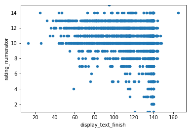

```python
# Lower ratings are typically associated with longer tweet text
tweets_merged.plot(x='display_text_finish', y='rating_numerator', kind='scatter', ylim=(1, 15));
```

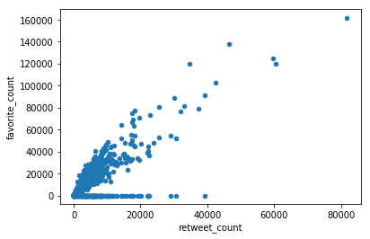

```python
# There is a positive and strong relationship between the retweet_count and the favorite_count
tweets_merged.plot(x='retweet_count', y='favorite_count', logy=False,kind='scatter');
```

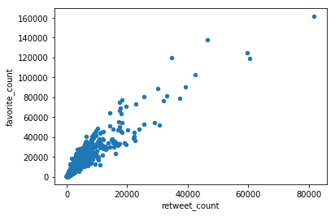

```python
# let's fpcus on all the tweets which were received at least 1 like( liked tweets)
# There is a positive and strong relationship between the retweet_count and the favorite_count


tweets_merged[tweets_merged.favorite_count!=0].plot(x='retweet_count', y='favorite_count',
                                                    logy=False,kind='scatter');
```

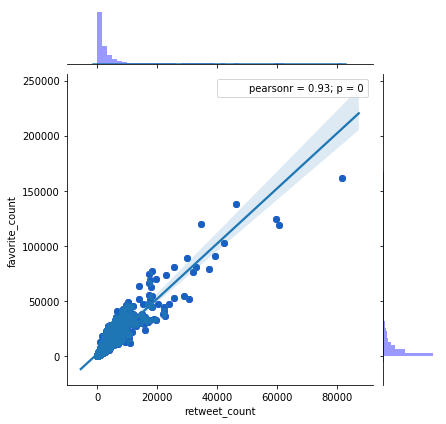

```python
#Lets plot the linear regression line, quantify the pearsonian
# coefficient and data modality(maximum frequency):
sns.jointplot('retweet_count','favorite_count',data=tweets_merged[
    tweets_merged.favorite_count!=0],color='b').plot(
    sns.regplot, sns.distplot).annotate(stats.pearsonr);
```

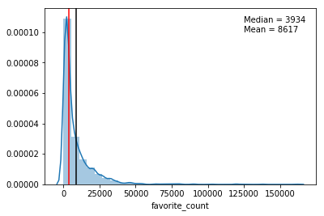

```python
# Lets further focus on the frequency plot of the favorite_count.
# Frequency plot shows a positivly skewed distribution
# it is further confirmed by comparing Mean and Median: Mean > Median
median_fav_count = int(tweets_merged[tweets_merged.favorite_count!=0]['favorite_count'].median())
mean_fav_count = int(tweets_merged[tweets_merged.favorite_count!=0]['favorite_count'].mean())


sns.distplot(tweets_merged[tweets_merged.favorite_count!=0]
             ['favorite_count'],bins=30,kde=True).annotate('''Median = {}
Mean = {}'''.format(median_fav_count, mean_fav_count), (125000,0.0001))
plt.axvline(x=median_fav_count, color='red')
plt.axvline(x=mean_fav_count, color='black');
```

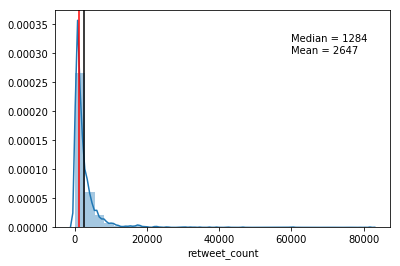

```python
# Lets further focus on the frequency plot of the retweet_count.
# Frequency plot shows a positivly skewed distribution
# it is further confirmed by comparing Mean and Median: Mean > Median
median_retweet_count = int(tweets_merged[tweets_merged.favorite_count!=0]['retweet_count'].median())
mean_retweet_count = int(tweets_merged[tweets_merged.favorite_count!=0]['retweet_count'].mean())
sns.distplot(tweets_merged[tweets_merged.favorite_count!=0]
             ['retweet_count'],bins=30,kde=True).annotate('''Median = {}
Mean = {}'''.format(median_retweet_count, mean_retweet_count),(60000,0.0003))
plt.axvline(x=median_retweet_count, color='red');
plt.axvline(x=mean_retweet_count, color='black');
```

#### Findings:

- Considering that we have removed those tweets with zero 'like' from the plot, we can still see that majority of tweets have been liked less than 4,000 times(Median of data is 3,934). These may be the fans of the page who follow every post and like it.
- We can also see that there are tweet with more than 4,000 likes. These were possibly those which went viral and got a lot of attention
- Similar analysis for retweet_count all the liked suggests messages have been generally retweeted less than 2,000 times. The median of the number of retweets is 1,284. You could say these are active fans who retweet the tweeter feed.
- the strong positive relationship is even more pronounced here and we have the pearsonian coefficient of 0.93 for it.

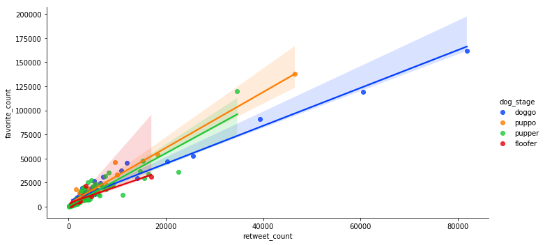

```python
# Lets look at the linear relationship of retweet_count and favourit count
# among each one the dog_stages
sns.lmplot(x='retweet_count',y='favorite_count',data=tweets_merged
           [tweets_merged.favorite_count!=0],hue='dog_stage',
           palette='bright', aspect = 2,truncate=True);
```

comparing these 4 lines, it seems the slope of the regression lines for pupper and puppo is larger than doggo and floofer. this suggest that the number of favourits for the former 2 dog stages grow faster with the number of retweets compared to the later 2 dog stages.

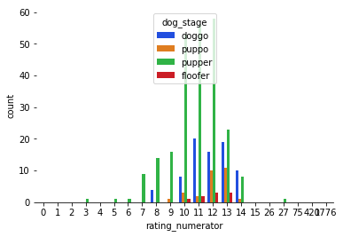

```python
sns.countplot('rating_numerator',data=tweets_merged,palette='bright',hue='dog_stage');
sns.despine(left=True)
```

Clearly, there are more pupper dogs and they cover a larger range of ratings compared to any other doges. doggo comes second and puppo is the third.

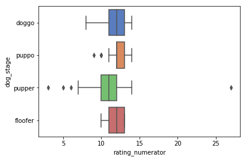

```python
# There are some outlier which can be removed (between 7-15 maybe?).
sns.boxplot(x="rating_numerator", y="dog_stage", data=tweets_merged,palette='muted');
```

This graph is really interesting, suggesting that on average pupper dogs have received a lower rating.

```python
stopwords = set(STOPWORDS)
# the following function uses a single colomn from a dataframe and plots the wordcloud
#In the following function, random_state is set for reproducibility and collocation=False means
#that if the same word is encountered in collocation with different words,
#it is still considered as one word (to remove duplicates)
def wordcloud(tweets,col):
    wordcloud = WordCloud(width=800, height=400,collocations=False,background_color="black",stopwords=stopwords,random_state = 2018,max_words=50).generate(" ".join([i for i in tweets[col]]))
    plt.figure( figsize=(20,10))
    plt.imshow(wordcloud)
    plt.axis("off")
```

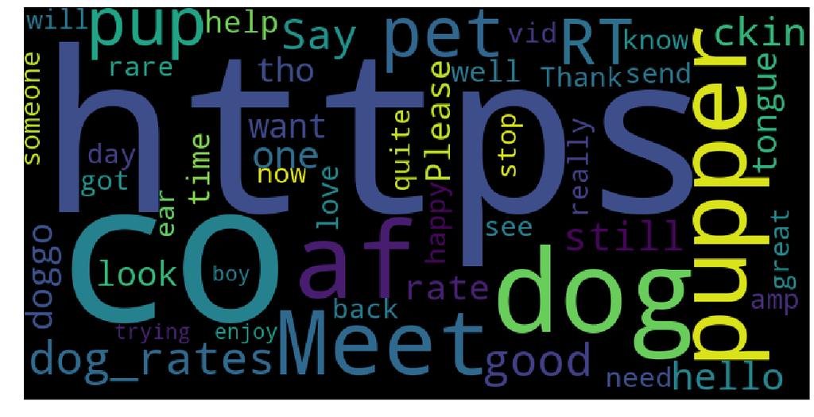

```python
wordcloud(tweets_merged,'full_text')
```

```python
# above plot has way too many unrelated words. Lets clean these action words and get to the meat
stopwords.add("https"), stopwords.add("co"), stopwords.add("Meet") ,stopwords.add("someone"),stopwords.add("RT")
stopwords.add("amp"), stopwords.add("Say"), stopwords.add("hello"), stopwords.add("ckin"), stopwords.add("af")
stopwords.add("Thank"), stopwords.add("send"), stopwords.add("know"), stopwords.add("still"), stopwords.add("day")
stopwords.add("want"), stopwords.add("someone"), stopwords.add("Please"), stopwords.add("one"),stopwords.add("time")
stopwords.add("now"), stopwords.add("rather"), stopwords.add("tho"), stopwords.add("quite"), stopwords.add("owner")
stopwords.add("need"), stopwords.add("will"), stopwords.add("stop"), stopwords.add("got"), stopwords.add("never")
stopwords.add("ck"), stopwords.add("back"), stopwords.add("take"), stopwords.add("much"), stopwords.add("thing")
stopwords.add("vid"), stopwords.add("likes"), stopwords.add("Always"), stopwords.add("see"), stopwords.add("trying")
stopwords.add("really"), stopwords.add("stuck"), stopwords.add("think"),stopwords.add("ready"), stopwords.add("clearly")
stopwords.add("make"), stopwords.add("well"), stopwords.add("new"),stopwords.add("slip"), stopwords.add("probably")
stopwords.add("wants"), stopwords.add("appear"), stopwords.add("keep"),stopwords.add("even"), stopwords.add("two")
stopwords.add("sending");
```

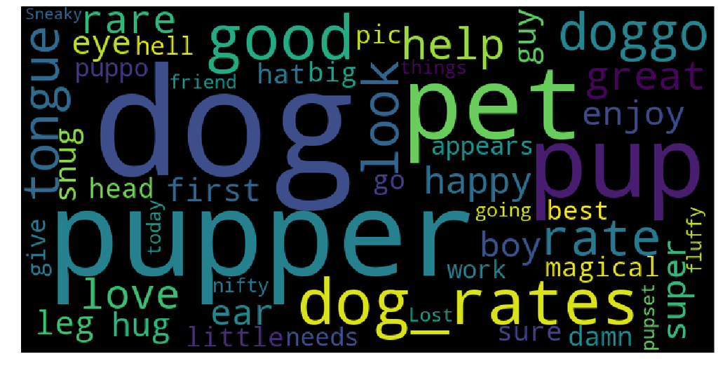

```python
wordcloud(tweets_merged,'full_text')
```

Above WordCount plot clearly shows what are the common theme of the tweets: `dog`s and `dog_rate`. Dog stages are here as well with the most commonly named dog stage being the big `pupper` in the middle. Rest of the words show the love and enjoyment that a freindly fluffy little puppy will bring about.